# Analysis of willow leaf beetle system for github sharing

### [5.2] Calculation of spatial indices using the (modified) epiphy package

https://chgigot.github.io/epiphy/articles/epiphy.html

#### [5.2.1] SADIE trial

For section 03

```r
sec03_aphid <- subset(aphid2024april, dayID == "s04" & section == "sec03")
```

```r
#Explicit mapping, need to avoid using count() in dplyr
(count_sec03 <- epiphy::count(sec03_aphid, mapping(x = x, y = y, t = dayN, i = aphid)))
```

```
# A mapped object: count class
# dim: 2 space, 1 time, 1 obs
```

|  | . | . | . | . | [t] | [x] | [y] | . | . | [i] |
| --- | --- | --- | --- | --- | --- | --- | --- | --- | --- | --- |
|  | dayID | YY.MM.DD | month | day | dayN | x | y | section | intrasection_plantID | aphid |
| 1 | s04 | 24-04-15 | M04 | D15 | 15 | 800 | 0 | sec03 | ind001 | 0 |
| 2 | s04 | 24-04-15 | M04 | D15 | 15 | 800 | -10 | sec03 | ind002 | 1 |
| 3 | s04 | 24-04-15 | M04 | D15 | 15 | 800 | -20 | sec03 | ind003 | 9 |
| 4 | s04 | 24-04-15 | M04 | D15 | 15 | 800 | -30 | sec03 | ind004 | 0 |
| 5 | s04 | 24-04-15 | M04 | D15 | 15 | 800 | -40 | sec03 | ind005 | 1 |
| 6 | s04 | 24-04-15 | M04 | D15 | 15 | 800 | -50 | sec03 | ind006 | 2 |

```
# ... with 114 more records (rows)
```

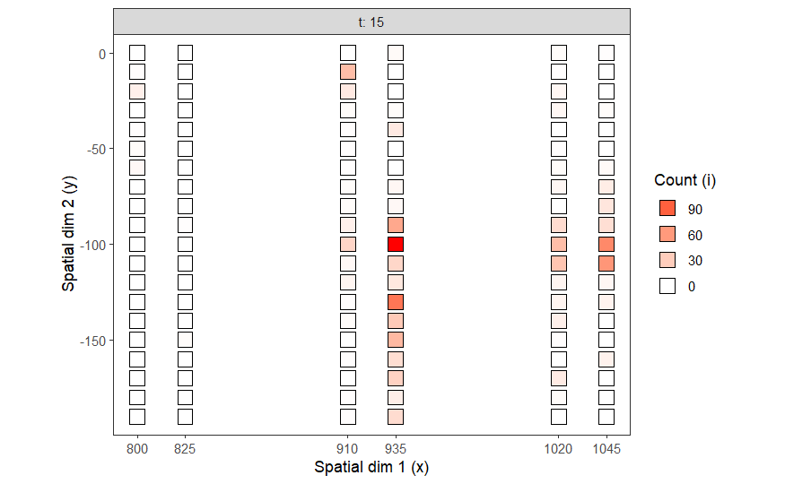

```r
plot(count_sec03, tile = FALSE, size = 5)
```

```r
#Computation of SADIE
set.seed(1234)
for(i in 1:1) capture.output(res_sec03 <- sadie(count_sec03, index = "all", threads = 2))
```

Showing the results

```r
#The aggregation index
res_sec03$Ia
```

```
[1] 1.803968
```

```r
summary(res_sec03)
```

```
Call:
sadie.count(data = count_sec03, index = "all", threads = 2)

First 6 rows of clustering indices:
```

|  | x | y | i | cost_flows | idx_P | idx_LMX | prob |
| --- | --- | --- | --- | --- | --- | --- | --- |
| 1 | 800 | 0 | 0 | -110.4536 | -2.0691620 | -2.0128884 | 0.16831683 |
| 2 | 800 | -10 | 1 | -136.2799 | -4.0265438 | -3.3571046 | 0.03960396 |
| 3 | 800 | -20 | 9 | 10.0000 | 0.5174291 | 0.8756779 | 0.22772277 |
| 4 | 800 | -30 | 0 | -152.0691 | -3.9022040 | -4.3385960 | 0.01980198 |
| 5 | 800 | -40 | 1 | -147.7329 | -4.5469222 | -4.8535845 | 0.00990099 |
| 6 | 800 | -50 | 2 | -138.9438 | -4.3601501 | -5.2699059 | 0.00990099 |

```
Summary indices:
```

|  | overall | inflow | outflow |
| --- | --- | --- | --- |
| Perry's index | 1.710602 | -1.886671 | 1.475109 |
| Li-Madden-Xu's index | 1.812742 | -2.005847 | 1.546781 |

```
Main outputs:
Ia: 1.8040 (Pa = 0.01)

'Total cost': 1897.465
Number of permutations: 100
```

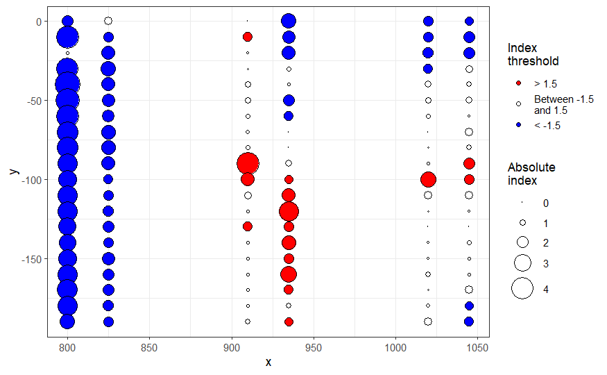

```r
plot(res_sec03) # Identical to: plot(my_res, index = "Perry")
```

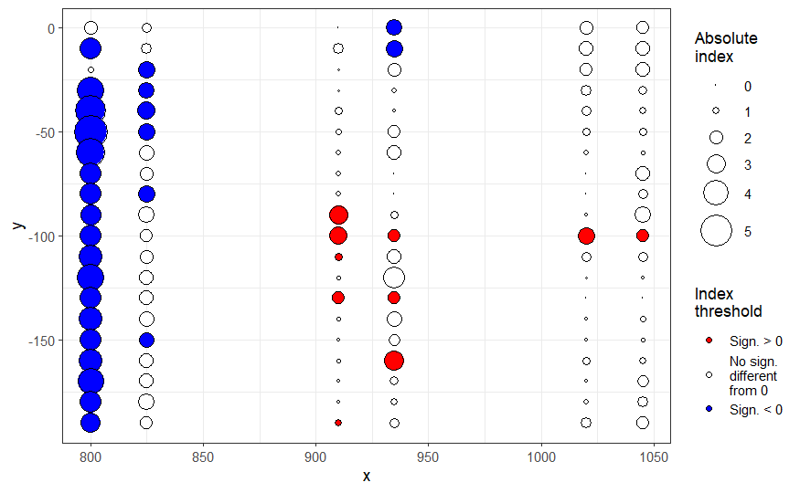

```r
plot(res_sec03, index = "Li-Madden-Xu")
```

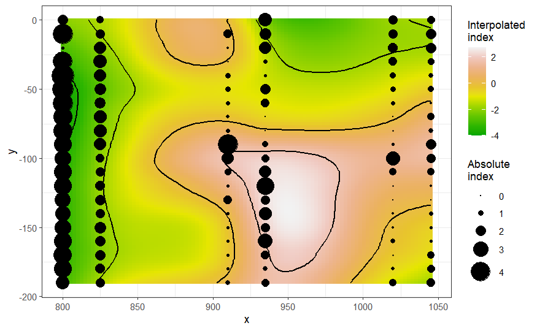

```r
plot(res_sec03, isoclines = TRUE) # Identical to: plot(my_res, index = "Perry")
```

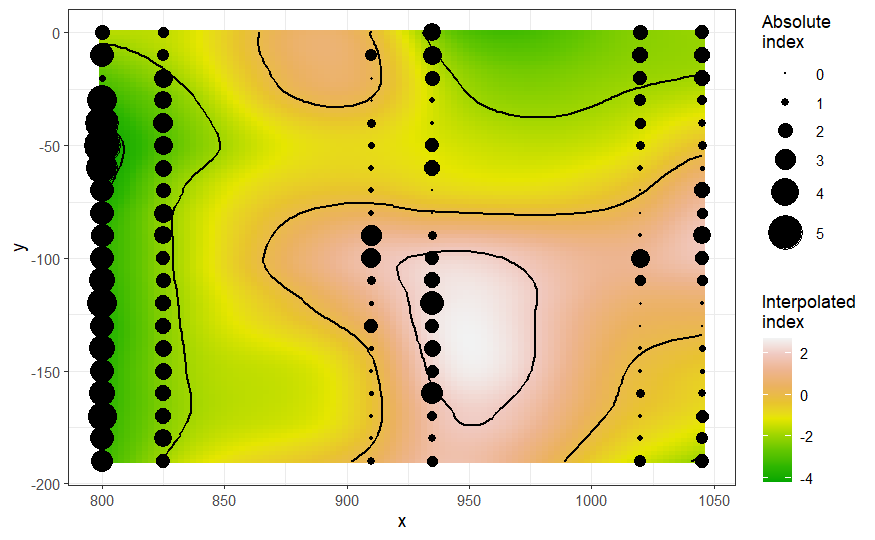

```r
plot(res_sec03, index = "Li-Madden-Xu", isoclines = TRUE)
```

#### [5.2.2] SADIE calculation at the section level

```r
set.seed(12345)
```

– Key point: Because the standardized Morisita index (as well as the Fisher index and similar measures) relies solely on frequency distribution information, it does not take spatial distribution into account.

– For example: Figures 1a–c and their accompanying explanations in the following paper provide a clear illustration: https://rethinkingecology.pensoft.net/article/30890/

```r
# splitting the data set based on the monitoring date ID and section name
split_aphid_sec <- split(aphid2024april$aphid, list(aphid2024april$dayID, aphid2024april$section))
split_x_sec <- split(aphid2024april$x, list(aphid2024april$dayID, aphid2024april$section))
split_y_sec <- split(aphid2024april$y, list(aphid2024april$dayID, aphid2024april$section))
```

- SADIE calculation

```r
#prepare the lists
sec_sadie_aphid <- list()
#prepare (unlisted) vector
sec_Ia_values <- rep(NA, length(split_aphid_sec))
sec_Perry_values <- rep(NA, length(split_aphid_sec))
sec_LMX_values <- rep(NA, length(split_aphid_sec))

#unique day values
day_points <- unique(aphid2024april$dayID)

for(k in 1:length(split_aphid_sec)) {
  if(k %% 8 == 0) cat("\n") #date change
  cat("+")
  subset_data <- data.frame(x = split_x_sec[[k]], y = split_y_sec[[k]], aphid = split_aphid_sec[[k]])
  count_sec <- epiphy::count(subset_data, mapping(x = x, y = y, i = aphid))
  capture.output(e <- try(sadie(count_sec, index = "all"), silent = TRUE))   #error management
  if(class(e) == "try-error") next
  sec_sadie_aphid <- e
  sec_Ia_values[k] <- sec_sadie_aphid$Ia
  sec_Perry_values[k] <- sec_sadie_aphid$summary_idx$overall[1]
  sec_LMX_values[k] <- sec_sadie_aphid$summary_idx$overall[2]
}
```

```
+++++++
++++++++
++++++++
++++++++
+
```

```r
print(sec_LMX_values)
```

```
 [1] 1.1617387 0.7401683 0.8626894 1.0031679 1.1645080 1.4329888 1.6717762 2.2410202 1.6910521
[10] 1.6607610 1.7130248 2.3605964 2.0979544 1.9139624 1.4433382 2.0815641 1.3990152 1.4718990
[19] 1.5794736 1.7884907 2.3916087 2.7115577 3.0303570 3.1774513 1.3164546 1.1510993 1.0121730
[28] 1.1695508 1.2164412 1.3858372 2.1204734 2.7596056
```

Integrated into the summary dataframe

```r
summary_aphid$Ia = unlist(sec_Ia_values)
summary_aphid$Perry_I = unlist(sec_Perry_values)
summary_aphid$LMX_I = unlist(sec_LMX_values)

print(summary_aphid)
```

|  | dayID | section | dayN | popsize | prevalence | std_mi | popl_growth_0 | popl_growth_1 | popl_growth_2 | prev_growth_0 | prev_growth_1 | prev_growth_2 | Ia | Perry_I | LMX_I |
| --- | --- | --- | --- | --- | --- | --- | --- | --- | --- | --- | --- | --- | --- | --- | --- |
| s01.sec01 | s01 | sec01 | 4 | 15 | 0.04166667 | 0.7551893 | NA | 0.084118059 | -0.13990395 | NA | 0.084118059 | -0.13990395 | 0.9056965 | 1.1413190 | 1.1617387 |
| s02.sec01 | s02 | sec01 | 8 | 45 | 0.05833333 | 0.6105497 | 0.084118059 | -0.139903947 | 0.41758766 | 0.084118059 | -0.139903947 | 0.41758766 | 0.7191203 | 0.7561060 | 0.7401683 |
| s03.sec01 | s03 | sec01 | 12 | 50 | 0.03333333 | 0.6192392 | -0.139903947 | 0.417587656 | 0.24296515 | -0.139903947 | 0.417587656 | 0.24296515 | 0.9181965 | 0.8723974 | 0.8626894 |
| s04.sec01 | s04 | sec01 | 15 | 73 | 0.11666667 | 0.5963550 | 0.417587656 | 0.242965146 | 0.13814459 | 0.417587656 | 0.242965146 | 0.13814459 | 1.0257365 | 0.9722137 | 1.0031679 |
| s05.sec01 | s05 | sec01 | 19 | 384 | 0.30833333 | 0.5327758 | 0.242965146 | 0.138144593 | 0.07303411 | 0.242965146 | 0.138144593 | 0.07303411 | 1.1866716 | 1.1708307 | 1.1645080 |
| s06.sec01 | s06 | sec01 | 22 | 649 | 0.46666667 | 0.5279340 | 0.138144593 | 0.073034106 | 0.03129079 | 0.138144593 | 0.073034106 | 0.03129079 | 1.7397470 | 1.3832679 | 1.4329888 |
| s07.sec01 | s07 | sec01 | 26 | 2144 | 0.62500000 | 0.5200849 | 0.073034106 | 0.031290786 | NA | 0.073034106 | 0.031290786 | NA | 2.0250955 | 1.6596907 | 1.6717762 |
| s08.sec01 | s08 | sec01 | 30 | 6358 | 0.70833333 | 0.5174303 | 0.031290786 | NA | NA | 0.031290786 | NA | NA | 1.9816343 | 2.3329743 | 2.2410202 |
| s01.sec02 | s01 | sec02 | 4 | 23 | 0.06666667 | 0.6045468 | NA | 0.216249359 | 0.03665087 | NA | 0.216249359 | 0.03665087 | 1.7326721 | 1.7335012 | 1.6910521 |
| s02.sec02 | s02 | sec02 | 8 | 107 | 0.15833333 | 0.5697429 | 0.216249359 | 0.036650869 | 0.13515504 | 0.216249359 | 0.036650869 | 0.13515504 | 2.1948229 | 1.7857062 | 1.6607610 |

[output cut: 22 more lines]

```r
NA
```

#### [5.2.3] SADIE calculation at the Une level

```r
# splitting the data set based on the monitoring date ID and section & une name
split_aphid_une <- split(aphid2024april_v2$aphid, list(aphid2024april_v2$dayID, aphid2024april_v2$une_id, aphid2024april_v2$section))

split_x_une <- split(aphid2024april_v2$x, list(aphid2024april_v2$dayID, aphid2024april_v2$une_id, aphid2024april_v2$section))

split_y_une <- split(aphid2024april_v2$y, list(aphid2024april_v2$dayID, aphid2024april_v2$une_id, aphid2024april_v2$section))
```

- SADIE calculation

```r
#prepare the lists
une_sadie_aphid <- list()
#prepare (unlisted) vector
une_Ia_values <- rep(NA, length(split_aphid_une))
une_Perry_values <- rep(NA, length(split_aphid_une))
une_LMX_values <- rep(NA, length(split_aphid_une))

#unique day values
day_points <- unique(aphid2024april$dayID)

for(k in 1:length(split_aphid_une)) {
  if(k %% 8 == 0) cat("\n") #date change
  cat("+")
  subset_data <- data.frame(x = split_x_une[[k]], y = split_y_une[[k]], aphid = split_aphid_une[[k]])
  count_une <- epiphy::count(subset_data, mapping(x = x, y = y, i = aphid))
  capture.output(e <- try(sadie(count_une, index = "all"), silent = TRUE))   #error management
  if(class(e) == "try-error") next
  une_sadie_aphid <- e
  une_Ia_values[k] <- une_sadie_aphid$Ia
  une_Perry_values[k] <- une_sadie_aphid$summary_idx$overall[1]
  une_LMX_values[k] <- une_sadie_aphid$summary_idx$overall[2]
}
```

```
+++++++
++++++++
++++++++
++++++++
++++++++
++++++++
++++++++
++++++++
++++++++
++++++++
++++++++
++++++++
+
```

```r
print(une_LMX_values)
```

```
 [1] 0.8003841 0.7255453 0.7367024 1.1317667 1.2245302 1.1879449 1.8704299 1.6175517        NA
[10] 1.0276260 1.0611292 1.0301646 1.6953500 1.7961716 2.0987492 2.7876632 0.9660368 1.0394678
[19] 1.2999105 1.8874983 1.2740344 1.6227824 1.8586117 2.2785939 1.9836466 0.9536572 1.6974996
[28] 1.4271678 1.3972736 1.0296370 1.2258565 1.3652675 1.4235612 0.7595468 1.5941483 0.9620088
[37] 1.3609431 1.0683300 1.4408616 1.1571077        NA        NA        NA 0.9148942 1.2909058
[46] 0.7903919 1.3020980 1.6697836 0.7500877 1.1142564 0.6248958 1.6614853 1.1612570 1.1237469
[55] 1.3224091 1.7146300 1.2979722 1.0903294 1.1097324 1.4080504 1.8370209 2.5432534 2.6018703
[64] 2.1088466 0.8622050 1.0015525 0.8871140 1.6891125 1.5920145 1.7929127 1.7503658 1.3850443
[73]        NA        NA 1.2994368 1.0662168 0.8766343 1.5038443 0.7622721 0.7706387 1.3773517
[82] 0.8401624 0.8580259 0.9187577 1.0149988 1.0943741 1.4869119 1.1843664 0.7507995 0.8088507
[91] 0.8648426 0.8565360 1.4626301 0.8790292 1.6104801 1.4501398
```

Integrated into the summary dataframe

```r
summary_aphid_apr_une$Ia_une = unlist((une_Ia_values))
summary_aphid_apr_une$Perry_une = unlist(une_Perry_values)
summary_aphid_apr_une$LMX_une = unlist(une_LMX_values)

print(summary_aphid_apr_une)
```

|  | dayID | une | section | une_section | dayN | popsize_une | prevalence_une | std_mi_une | popl_growth_une_0 | popl_growth_une_1 | popl_growth_une_2 | prev_growth_une_0 | prev_growth_une_1 | prev_growth_une_2 | Ia_une | Perry_une | LMX_une |
| --- | --- | --- | --- | --- | --- | --- | --- | --- | --- | --- | --- | --- | --- | --- | --- | --- | --- |
| s01.une01.sec01 | s01 | une01 | sec01 | une01.sec01 | 4 | 14 | 0.100 | 0.78917530 | NA | 0.000000000 | -0.018526993 | NA | -0.346573590 | 0.000000000 | 0.8130075 | 0.7749815 | 0.8003841 |
| s02.une01.sec01 | s02 | une01 | sec01 | une01.sec01 | 8 | 14 | 0.025 | 1.00000000 | 0.000000000 | -0.018526993 | 0.126496541 | -0.346573590 | 0.000000000 | 0.462098120 | 0.8007015 | 0.7624444 | 0.7255453 |
| s03.une01.sec01 | s03 | une01 | sec01 | une01.sec01 | 12 | 13 | 0.025 | 1.00000000 | -0.018526993 | 0.126496541 | 0.388842673 | 0.000000000 | 0.462098120 | 0.294663749 | 0.7793757 | 0.7420616 | 0.7367024 |
| s04.une01.sec01 | s04 | une01 | sec01 | une01.sec01 | 15 | 19 | 0.100 | 0.64854730 | 0.126496541 | 0.388842673 | 0.215894935 | 0.462098120 | 0.294663749 | 0.108474133 | 1.2444590 | 1.1420846 | 1.1317667 |
| s05.une01.sec01 | s05 | une01 | sec01 | une01.sec01 | 19 | 90 | 0.325 | 0.56622671 | 0.388842673 | 0.215894935 | 0.399141177 | 0.294663749 | 0.108474133 | 0.082126017 | 1.1433156 | 1.1982143 | 1.2245302 |
| s06.une01.sec01 | s06 | une01 | sec01 | une01.sec01 | 22 | 172 | 0.450 | 0.61107883 | 0.215894935 | 0.399141177 | -0.044698554 | 0.108474133 | 0.082126017 | 0.028332171 | 1.2665228 | 1.0866857 | 1.1879449 |
| s07.une01.sec01 | s07 | une01 | sec01 | une01.sec01 | 26 | 849 | 0.625 | 0.55978312 | 0.399141177 | -0.044698554 | NA | 0.082126017 | 0.028332171 | NA | 2.2029741 | 1.8608263 | 1.8704299 |
| s08.une01.sec01 | s08 | une01 | sec01 | une01.sec01 | 30 | 710 | 0.700 | 0.55017257 | -0.044698554 | NA | NA | 0.028332171 | NA | NA | 1.7594752 | 1.5169743 | 1.6175517 |
| s01.une02.sec01 | s01 | une02 | sec01 | une02.sec01 | 4 | 0 | 0.000 | NaN | NA | NA | 0.121376954 | NA | NA | 0.000000000 | NA | NA | NA |
| s02.une02.sec01 | s02 | une02 | sec01 | une02.sec01 | 8 | 16 | 0.050 | 0.93373153 | NA | 0.121376954 | 0.108474133 | NA | 0.000000000 | 0.135155036 | 0.9655316 | 1.0499891 | 1.0276260 |

[output cut: 86 more lines]

##### Merging section-level’s data and une-level’s

– using une02 data (because it’s located at the center of the section)

```r
une02_summary_aphid_apr_une <- subset(summary_aphid_apr_une, une == "une02")
print(une02_summary_aphid_apr_une)
```

|  | dayID | une | section | une_section | dayN | popsize_une | prevalence_une | std_mi_une | popl_growth_une_0 | popl_growth_une_1 | popl_growth_une_2 | prev_growth_une_0 | prev_growth_une_1 | prev_growth_une_2 | Ia_une | Perry_une | LMX_une |
| --- | --- | --- | --- | --- | --- | --- | --- | --- | --- | --- | --- | --- | --- | --- | --- | --- | --- |
| s01.une02.sec01 | s01 | une02 | sec01 | une02.sec01 | 4 | 0 | 0.000 | NaN | NA | NA | 0.121376954 | NA | NA | 0.00000000 | NA | NA | NA |
| s02.une02.sec01 | s02 | une02 | sec01 | une02.sec01 | 8 | 16 | 0.050 | 0.93373153 | NA | 0.121376954 | 0.108474133 | NA | 0.00000000 | 0.13515504 | 0.9655316 | 1.0499891 | 1.0276260 |
| s03.une02.sec01 | s03 | une02 | sec01 | une02.sec01 | 12 | 26 | 0.050 | 0.75375086 | 0.121376954 | 0.108474133 | 0.427446472 | 0.00000000 | 0.13515504 | 0.43365026 | 1.1948112 | 1.0729287 | 1.0611292 |
| s04.une02.sec01 | s04 | une02 | sec01 | une02.sec01 | 15 | 36 | 0.075 | 0.84396825 | 0.108474133 | 0.427446472 | 0.200366003 | 0.13515504 | 0.43365026 | 0.08594304 | 0.9680234 | 1.0220309 | 1.0301646 |
| s05.une02.sec01 | s05 | une02 | sec01 | une02.sec01 | 19 | 199 | 0.425 | 0.57546388 | 0.427446472 | 0.200366003 | 0.205547985 | 0.43365026 | 0.08594304 | 0.06029051 | 1.8972805 | 1.5292516 | 1.6953500 |
| s06.une02.sec01 | s06 | une02 | sec01 | une02.sec01 | 22 | 363 | 0.550 | 0.55390239 | 0.200366003 | 0.205547985 | 0.453230542 | 0.08594304 | 0.06029051 | 0.03338285 | 2.0261597 | 1.5695794 | 1.7961716 |
| s07.une02.sec01 | s07 | une02 | sec01 | une02.sec01 | 26 | 826 | 0.700 | 0.53705084 | 0.205547985 | 0.453230542 | NA | 0.06029051 | 0.03338285 | NA | 2.1553030 | 1.9749831 | 2.0987492 |
| s08.une02.sec01 | s08 | une02 | sec01 | une02.sec01 | 30 | 5062 | 0.800 | 0.51994585 | 0.453230542 | NA | NA | 0.03338285 | NA | NA | 3.0502358 | 2.6579277 | 2.7876632 |
| s01.une02.sec02 | s01 | une02 | sec02 | une02.sec02 | 4 | 2 | 0.050 | -0.03258247 | NA | 0.575646273 | 0.084118059 | NA | 0.37601935 | -0.02944576 | 1.4068975 | 1.4201719 | 1.4235612 |
| s02.une02.sec02 | s02 | une02 | sec02 | une02.sec02 | 8 | 20 | 0.225 | 0.51792538 | 0.575646273 | 0.084118059 | -0.051383560 | 0.37601935 | -0.02944576 | 0.10615124 | 0.7653597 | 0.7218686 | 0.7595468 |

[output cut: 22 more lines]

– adding necessary columns

```r
sec_une_summary_aphid_apr <- data.frame(
  summary_aphid,
  une = une02_summary_aphid_apr_une$une,
  popsize_une = une02_summary_aphid_apr_une$popsize_une,
  prevalence_une = une02_summary_aphid_apr_une$prevalence_une,
  popl_growth_0_une = une02_summary_aphid_apr_une$popl_growth_une_0,
  popl_growth_1_une = une02_summary_aphid_apr_une$popl_growth_une_1,
  popl_growth_2_une = une02_summary_aphid_apr_une$popl_growth_une_2,
  prev_growth_0_une = une02_summary_aphid_apr_une$prev_growth_une_0,
  prev_growth_1_une = une02_summary_aphid_apr_une$prev_growth_une_1,
  prev_growth_2_une = une02_summary_aphid_apr_une$prev_growth_une_2,
  std_mi_une = une02_summary_aphid_apr_une$std_mi_une,
  Ia_une = une02_summary_aphid_apr_une$Ia_une,
  Perry_I_une = une02_summary_aphid_apr_une$Perry_une,
  LMX_I_une = une02_summary_aphid_apr_une$LMX_une
  )
print(sec_une_summary_aphid_apr)
```

|  | dayID | section | dayN | popsize | prevalence | std_mi | popl_growth_0 | popl_growth_1 | popl_growth_2 | prev_growth_0 | prev_growth_1 | prev_growth_2 | Ia | Perry_I | LMX_I | une | popsize_une | prevalence_une | popl_growth_0_une | popl_growth_1_une | popl_growth_2_une | prev_growth_0_une | prev_growth_1_une | prev_growth_2_une | std_mi_une | Ia_une | Perry_I_une | LMX_I_une |
| --- | --- | --- | --- | --- | --- | --- | --- | --- | --- | --- | --- | --- | --- | --- | --- | --- | --- | --- | --- | --- | --- | --- | --- | --- | --- | --- | --- | --- |
| s01.sec01 | s01 | sec01 | 4 | 15 | 0.04166667 | 0.7551893 | NA | 0.084118059 | -0.13990395 | NA | 0.084118059 | -0.13990395 | 0.9056965 | 1.1413190 | 1.1617387 | une02 | 0 | 0.000 | NA | NA | 0.121376954 | NA | NA | 0.00000000 | NaN | NA | NA | NA |
| s02.sec01 | s02 | sec01 | 8 | 45 | 0.05833333 | 0.6105497 | 0.084118059 | -0.139903947 | 0.41758766 | 0.084118059 | -0.139903947 | 0.41758766 | 0.7191203 | 0.7561060 | 0.7401683 | une02 | 16 | 0.050 | NA | 0.121376954 | 0.108474133 | NA | 0.00000000 | 0.13515504 | 0.93373153 | 0.9655316 | 1.0499891 | 1.0276260 |
| s03.sec01 | s03 | sec01 | 12 | 50 | 0.03333333 | 0.6192392 | -0.139903947 | 0.417587656 | 0.24296515 | -0.139903947 | 0.417587656 | 0.24296515 | 0.9181965 | 0.8723974 | 0.8626894 | une02 | 26 | 0.050 | 0.121376954 | 0.108474133 | 0.427446472 | 0.00000000 | 0.13515504 | 0.43365026 | 0.75375086 | 1.1948112 | 1.0729287 | 1.0611292 |
| s04.sec01 | s04 | sec01 | 15 | 73 | 0.11666667 | 0.5963550 | 0.417587656 | 0.242965146 | 0.13814459 | 0.417587656 | 0.242965146 | 0.13814459 | 1.0257365 | 0.9722137 | 1.0031679 | une02 | 36 | 0.075 | 0.108474133 | 0.427446472 | 0.200366003 | 0.13515504 | 0.43365026 | 0.08594304 | 0.84396825 | 0.9680234 | 1.0220309 | 1.0301646 |
| s05.sec01 | s05 | sec01 | 19 | 384 | 0.30833333 | 0.5327758 | 0.242965146 | 0.138144593 | 0.07303411 | 0.242965146 | 0.138144593 | 0.07303411 | 1.1866716 | 1.1708307 | 1.1645080 | une02 | 199 | 0.425 | 0.427446472 | 0.200366003 | 0.205547985 | 0.43365026 | 0.08594304 | 0.06029051 | 0.57546388 | 1.8972805 | 1.5292516 | 1.6953500 |
| s06.sec01 | s06 | sec01 | 22 | 649 | 0.46666667 | 0.5279340 | 0.138144593 | 0.073034106 | 0.03129079 | 0.138144593 | 0.073034106 | 0.03129079 | 1.7397470 | 1.3832679 | 1.4329888 | une02 | 363 | 0.550 | 0.200366003 | 0.205547985 | 0.453230542 | 0.08594304 | 0.06029051 | 0.03338285 | 0.55390239 | 2.0261597 | 1.5695794 | 1.7961716 |
| s07.sec01 | s07 | sec01 | 26 | 2144 | 0.62500000 | 0.5200849 | 0.073034106 | 0.031290786 | NA | 0.073034106 | 0.031290786 | NA | 2.0250955 | 1.6596907 | 1.6717762 | une02 | 826 | 0.700 | 0.205547985 | 0.453230542 | NA | 0.06029051 | 0.03338285 | NA | 0.53705084 | 2.1553030 | 1.9749831 | 2.0987492 |
| s08.sec01 | s08 | sec01 | 30 | 6358 | 0.70833333 | 0.5174303 | 0.031290786 | NA | NA | 0.031290786 | NA | NA | 1.9816343 | 2.3329743 | 2.2410202 | une02 | 5062 | 0.800 | 0.453230542 | NA | NA | 0.03338285 | NA | NA | 0.51994585 | 3.0502358 | 2.6579277 | 2.7876632 |
| s01.sec02 | s01 | sec02 | 4 | 23 | 0.06666667 | 0.6045468 | NA | 0.216249359 | 0.03665087 | NA | 0.216249359 | 0.03665087 | 1.7326721 | 1.7335012 | 1.6910521 | une02 | 2 | 0.050 | NA | 0.575646273 | 0.084118059 | NA | 0.37601935 | -0.02944576 | -0.03258247 | 1.4068975 | 1.4201719 | 1.4235612 |
| s02.sec02 | s02 | sec02 | 8 | 107 | 0.15833333 | 0.5697429 | 0.216249359 | 0.036650869 | 0.13515504 | 0.216249359 | 0.036650869 | 0.13515504 | 2.1948229 | 1.7857062 | 1.6607610 | une02 | 20 | 0.225 | 0.575646273 | 0.084118059 | -0.051383560 | 0.37601935 | -0.02944576 | 0.10615124 | 0.51792538 | 0.7653597 | 0.7218686 | 0.7595468 |

[output cut: 22 more lines]

##### Confirm if the data merging is appropriate via visualization

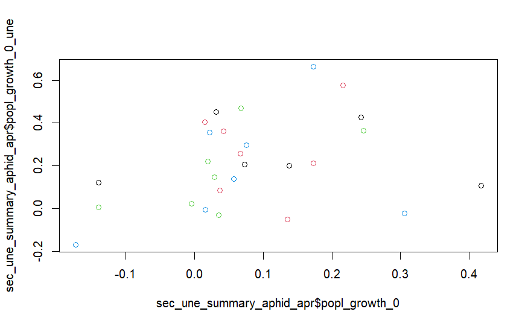

```r
plot(sec_une_summary_aphid_apr$popl_growth_0, sec_une_summary_aphid_apr$popl_growth_0_une, col = as.numeric(as.factor(sec_une_summary_aphid_apr$section)))
```

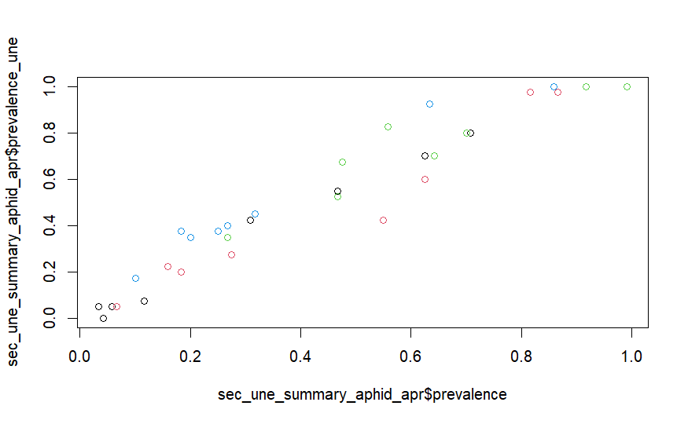

```r
plot(sec_une_summary_aphid_apr$prevalence, sec_une_summary_aphid_apr$prevalence_une, col = as.numeric(as.factor(sec_une_summary_aphid_apr$section)))
```

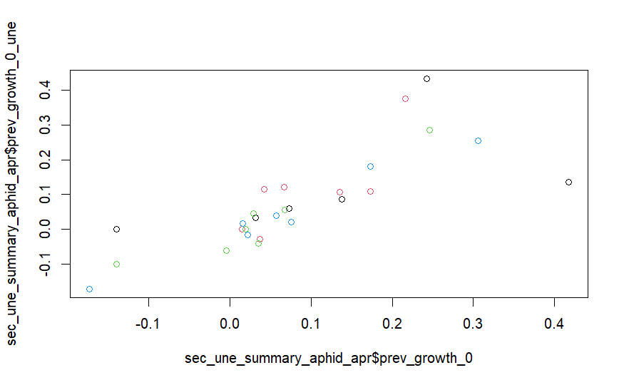

```r
plot(sec_une_summary_aphid_apr$prev_growth_0, sec_une_summary_aphid_apr$prev_growth_0_une, col = as.numeric(as.factor(sec_une_summary_aphid_apr$section)))
```

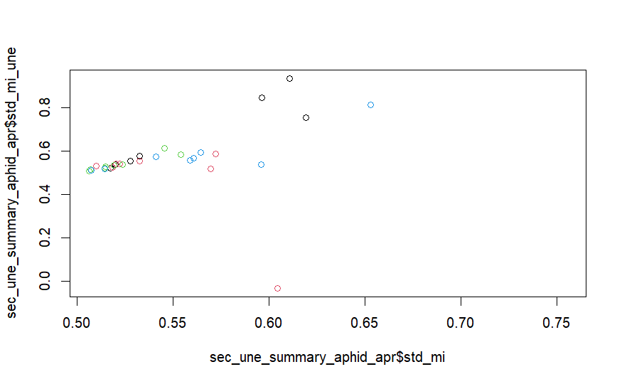

```r
plot(sec_une_summary_aphid_apr$std_mi, sec_une_summary_aphid_apr$std_mi_une, col = as.numeric(as.factor(sec_une_summary_aphid_apr$section)))
```

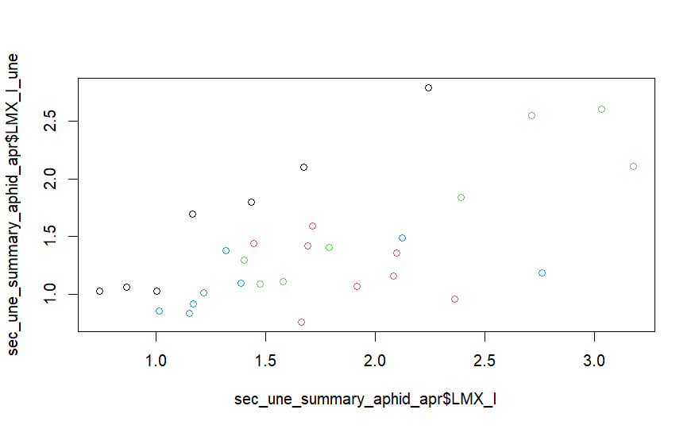

```r
plot(sec_une_summary_aphid_apr$LMX_I, sec_une_summary_aphid_apr$LMX_I_une, col = as.numeric(as.factor(sec_une_summary_aphid_apr$section)))
```

##### Visualization of LMX_I

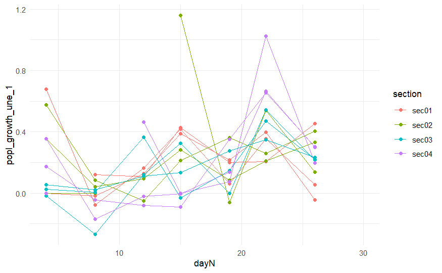

```r
ggplot(summary_aphid_apr_une, aes(x = dayN, y = popl_growth_une_1, group = une_section, color = section)) +
  geom_line() +
  geom_point() +
  theme_minimal()
```

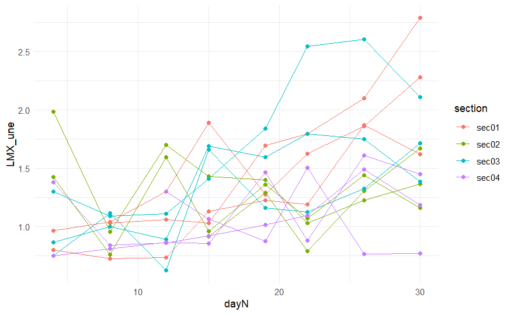

```r
ggplot(summary_aphid_apr_une, aes(x = dayN, y = LMX_une, group = une_section, color = section)) +
  geom_line() +
  geom_point() +
  theme_minimal()
```

#### [5.2.4] SADIE and population characteristics at the B’-div level

– nonspatial characteristics

```r
# spliting the data set based on monitoring date ID, section name, and B'-div ID
aphid2024april_v2_temp <- subset(aphid2024april_v2, aphid2024april_v2$Bd_id != "skip")
split_aphid_Bddiv <- split(aphid2024april_v2_temp$aphid, list(aphid2024april_v2_temp$dayID, aphid2024april_v2_temp$Bd_id, aphid2024april_v2_temp$section))

split_x_Bddiv <- split(aphid2024april_v2_temp$x, list(aphid2024april_v2_temp$dayID, aphid2024april_v2_temp$Bd_id, aphid2024april_v2_temp$section))

split_y_Bddiv <- split(aphid2024april_v2_temp$y, list(aphid2024april_v2_temp$dayID, aphid2024april_v2_temp$Bd_id, aphid2024april_v2_temp$section))

split_une_Bddiv <- split(aphid2024april_v2_temp$une, list(aphid2024april_v2_temp$dayID, aphid2024april_v2_temp$Bd_id, aphid2024april_v2_temp$section))


# monitoring date ID at B'-div level
split_dayN_Bddiv <- split(aphid2024april_v2_temp$dayN, list(aphid2024april_v2_temp$dayID, aphid2024april_v2_temp$Bd_id, aphid2024april_v2_temp$section))
split_dayN_Bddiv <- lapply(split_dayN_Bddiv, mean)

# population size at the section level
split_sum_Bddiv <- lapply(split_aphid_Bddiv, sum)
# prevalence at the section level (0-1)
split_prev_Bddiv <- lapply(split_aphid_Bddiv, prevalence)


# morisita index
split_morisita_Bddiv <- lapply(split_aphid_Bddiv, dispindmorisita)
std_morisita_Bddiv <- sapply(split_morisita_Bddiv, function(df) df[1, 4])
```

SADIE calculation

```r
#prepare the lists
Bddiv_sadie_aphid <- list()
#prepare (unlisted) vector
Bddiv_Ia_values <- rep(NA, length(split_aphid_Bddiv))
Bddiv_Perry_values <- rep(NA, length(split_aphid_Bddiv))
Bddiv_LMX_values <- rep(NA, length(split_aphid_Bddiv))

#unique day values
day_points <- unique(aphid2024april$dayID)

for(k in 1:length(split_aphid_Bddiv)) {
  if(k %% 8 == 0) cat("\n") #date change
  cat("+")
  subset_data <- data.frame(x = split_x_Bddiv[[k]], y = split_y_Bddiv[[k]], aphid = split_aphid_Bddiv[[k]])
  count_Bddiv <- epiphy::count(subset_data, mapping(x = x, y = y, i = aphid))
  capture.output(e <- try(sadie(count_Bddiv, index = "all"), silent = TRUE))   #error management
  if(class(e) == "try-error") next
  Bddiv_sadie_aphid <- e
  Bddiv_Ia_values[k] <- Bddiv_sadie_aphid$Ia
  Bddiv_Perry_values[k] <- Bddiv_sadie_aphid$summary_idx$overall[1]
  Bddiv_LMX_values[k] <- Bddiv_sadie_aphid$summary_idx$overall[2]
}
```

```
+++++++
++++++++
++++++++
++++++++
++++++++
++++++++
++++++++
++++++++
++++++++
++++++++
++++++++
++++++++
+
```

```r
print(Bddiv_LMX_values)
```

```
 [1] 0.8521336 0.7812503 0.7972961 1.0103692 1.0544121 1.0779792 1.6522964 1.9400994        NA
[10]        NA 1.3839719 0.8035008 1.2711138 1.3811638 1.4331174 1.4124403        NA 1.0222465
[19]        NA 1.1204272 0.7810727 0.9764457 1.4791229 1.0274910 1.3671519 0.8559140 1.2363321
[28] 1.2210875 0.8807637 0.8782983 0.8590100 1.0988001        NA 1.0098462 1.1622076 1.4413999
[37] 0.7703461 0.9511999 0.8320133 1.0144902        NA        NA        NA 1.2719729 1.2423955
[46] 1.2242493 1.4578619 1.5504461 1.1865020 1.2260479 1.0069984 1.4278382 1.3318396 0.8803053
[55] 0.9354632 1.0121678 1.3248468 1.0515479 1.1307604 1.3295814 1.3168672 1.4893607 2.2754889
[64] 1.2872439 0.7639538 0.8736383 0.9124253 1.0665379 1.1501438 1.1293668 1.3525425 0.9691430
[73]        NA        NA        NA 1.2869589 1.1111397 1.1171431 0.8354198 0.8376280 1.2361694
[82] 0.8556020 0.8537802 0.9443027 1.0559880 1.0042867 1.4228520 1.2915336 0.7975501 0.8069989
[91] 0.9101250 0.8609174 1.0209697 0.9173686 0.9960138 1.0984786
```

Summarizing into the new dataframe

```r
comb_Bddiv <- names(split_aphid_Bddiv)
comb_Bddiv <- do.call(rbind, strsplit(comb_Bddiv, split = "\\."))
une_id_Bddiv <- numeric(length(comb_Bddiv[, 1]))
for(k in 1:length(comb_Bddiv[, 1])) {
  une_id_Bddiv[k] <- split_une_Bddiv[[k]][1]
}

Bddiv_summary_aphid_apr <- data.frame(
  dayID = comb_Bddiv[, 1],
  section = comb_Bddiv[, 3],
  une_id = une_id_Bddiv,
  Bd_id = comb_Bddiv[, 2],
  Bddiv_section = paste(comb_Bddiv[, 2], comb_Bddiv[, 3], sep = "."),
  dayN = unlist(split_dayN_Bddiv),
  popsize_Bddiv = unlist(split_sum_Bddiv),
  prevalence_Bddiv = unlist(split_prev_Bddiv),
  std_mi_Bddiv = std_morisita_Bddiv,
  Ia_Bddiv = unlist((Bddiv_Ia_values)),
  Perry_I_Bddiv = unlist(Bddiv_Perry_values),
  LMX_I_Bddiv = unlist(Bddiv_LMX_values)
)
print(Bddiv_summary_aphid_apr)
```

|  | dayID | section | une_id | Bd_id | Bddiv_section | dayN | popsize_Bddiv | prevalence_Bddiv | std_mi_Bddiv | Ia_Bddiv | Perry_I_Bddiv | LMX_I_Bddiv |
| --- | --- | --- | --- | --- | --- | --- | --- | --- | --- | --- | --- | --- |
| s01.Bd1.sec01 | s01 | sec01 | une01 | Bd1 | Bd1.sec01 | 4 | 12 | 0.10 | 0.9060541 | 0.8624602 | 0.8467173 | 0.8521336 |
| s02.Bd1.sec01 | s02 | sec01 | une01 | Bd1 | Bd1.sec01 | 8 | 14 | 0.05 | 1.0000000 | 0.8053323 | 0.7873297 | 0.7812503 |
| s03.Bd1.sec01 | s03 | sec01 | une01 | Bd1 | Bd1.sec01 | 12 | 13 | 0.05 | 1.0000000 | 0.8244677 | 0.8064634 | 0.7972961 |
| s04.Bd1.sec01 | s04 | sec01 | une01 | Bd1 | Bd1.sec01 | 15 | 19 | 0.20 | 0.6343110 | 1.0145581 | 1.0325154 | 1.0103692 |
| s05.Bd1.sec01 | s05 | sec01 | une01 | Bd1 | Bd1.sec01 | 19 | 80 | 0.50 | 0.5730081 | 1.1213101 | 1.0545786 | 1.0544121 |
| s06.Bd1.sec01 | s06 | sec01 | une01 | Bd1 | Bd1.sec01 | 22 | 153 | 0.55 | 0.6324230 | 1.4332239 | 1.1164429 | 1.0779792 |
| s07.Bd1.sec01 | s07 | sec01 | une01 | Bd1 | Bd1.sec01 | 26 | 767 | 0.80 | 0.5632396 | 1.5396632 | 1.6025191 | 1.6522964 |
| s08.Bd1.sec01 | s08 | sec01 | une01 | Bd1 | Bd1.sec01 | 30 | 595 | 0.90 | 0.5582896 | 2.4565153 | 1.8750349 | 1.9400994 |
| s01.Bd2.sec01 | s01 | sec01 | une02 | Bd2 | Bd2.sec01 | 4 | 0 | 0.00 | NaN | NA | NA | NA |
| s02.Bd2.sec01 | s02 | sec01 | une02 | Bd2 | Bd2.sec01 | 8 | 0 | 0.00 | NaN | NA | NA | NA |

[output cut: 86 more lines]

##### Merging une-level’s data and Bd-div level’s

```r
Bddiv_une_summary_aphid_apr <- data.frame(
  summary_aphid_apr_une,
  Bd_id = Bddiv_summary_aphid_apr$Bd_id,
  popsize_Bd = Bddiv_summary_aphid_apr$popsize_Bddiv,
  prevalence_Bd = Bddiv_summary_aphid_apr$prevalence_Bddiv,
  std_mi_Bd = Bddiv_summary_aphid_apr$std_mi_Bddiv,
  LMX_I_Bd = Bddiv_summary_aphid_apr$LMX_I_Bddiv
)
print(Bddiv_une_summary_aphid_apr)
```

|  | dayID | une | section | une_section | dayN | popsize_une | prevalence_une | std_mi_une | popl_growth_une_0 | popl_growth_une_1 | popl_growth_une_2 | prev_growth_une_0 | prev_growth_une_1 | prev_growth_une_2 | Ia_une | Perry_une | LMX_une | Bd_id | popsize_Bd | prevalence_Bd | std_mi_Bd | LMX_I_Bd |
| --- | --- | --- | --- | --- | --- | --- | --- | --- | --- | --- | --- | --- | --- | --- | --- | --- | --- | --- | --- | --- | --- | --- |
| s01.une01.sec01 | s01 | une01 | sec01 | une01.sec01 | 4 | 14 | 0.100 | 0.78917530 | NA | 0.000000000 | -0.018526993 | NA | -0.346573590 | 0.000000000 | 0.8130075 | 0.7749815 | 0.8003841 | Bd1 | 12 | 0.10 | 0.9060541 | 0.8521336 |
| s02.une01.sec01 | s02 | une01 | sec01 | une01.sec01 | 8 | 14 | 0.025 | 1.00000000 | 0.000000000 | -0.018526993 | 0.126496541 | -0.346573590 | 0.000000000 | 0.462098120 | 0.8007015 | 0.7624444 | 0.7255453 | Bd1 | 14 | 0.05 | 1.0000000 | 0.7812503 |
| s03.une01.sec01 | s03 | une01 | sec01 | une01.sec01 | 12 | 13 | 0.025 | 1.00000000 | -0.018526993 | 0.126496541 | 0.388842673 | 0.000000000 | 0.462098120 | 0.294663749 | 0.7793757 | 0.7420616 | 0.7367024 | Bd1 | 13 | 0.05 | 1.0000000 | 0.7972961 |
| s04.une01.sec01 | s04 | une01 | sec01 | une01.sec01 | 15 | 19 | 0.100 | 0.64854730 | 0.126496541 | 0.388842673 | 0.215894935 | 0.462098120 | 0.294663749 | 0.108474133 | 1.2444590 | 1.1420846 | 1.1317667 | Bd1 | 19 | 0.20 | 0.6343110 | 1.0103692 |
| s05.une01.sec01 | s05 | une01 | sec01 | une01.sec01 | 19 | 90 | 0.325 | 0.56622671 | 0.388842673 | 0.215894935 | 0.399141177 | 0.294663749 | 0.108474133 | 0.082126017 | 1.1433156 | 1.1982143 | 1.2245302 | Bd1 | 80 | 0.50 | 0.5730081 | 1.0544121 |
| s06.une01.sec01 | s06 | une01 | sec01 | une01.sec01 | 22 | 172 | 0.450 | 0.61107883 | 0.215894935 | 0.399141177 | -0.044698554 | 0.108474133 | 0.082126017 | 0.028332171 | 1.2665228 | 1.0866857 | 1.1879449 | Bd1 | 153 | 0.55 | 0.6324230 | 1.0779792 |
| s07.une01.sec01 | s07 | une01 | sec01 | une01.sec01 | 26 | 849 | 0.625 | 0.55978312 | 0.399141177 | -0.044698554 | NA | 0.082126017 | 0.028332171 | NA | 2.2029741 | 1.8608263 | 1.8704299 | Bd1 | 767 | 0.80 | 0.5632396 | 1.6522964 |
| s08.une01.sec01 | s08 | une01 | sec01 | une01.sec01 | 30 | 710 | 0.700 | 0.55017257 | -0.044698554 | NA | NA | 0.028332171 | NA | NA | 1.7594752 | 1.5169743 | 1.6175517 | Bd1 | 595 | 0.90 | 0.5582896 | 1.9400994 |
| s01.une02.sec01 | s01 | une02 | sec01 | une02.sec01 | 4 | 0 | 0.000 | NaN | NA | NA | 0.121376954 | NA | NA | 0.000000000 | NA | NA | NA | Bd2 | 0 | 0.00 | NaN | NA |
| s02.une02.sec01 | s02 | une02 | sec01 | une02.sec01 | 8 | 16 | 0.050 | 0.93373153 | NA | 0.121376954 | 0.108474133 | NA | 0.000000000 | 0.135155036 | 0.9655316 | 1.0499891 | 1.0276260 | Bd2 | 0 | 0.00 | NaN | NA |

[output cut: 86 more lines]

##### Confirm if the data merging is appropriate via visualization

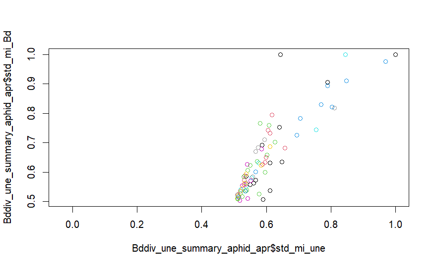

```r
plot(Bddiv_une_summary_aphid_apr$std_mi_une, Bddiv_une_summary_aphid_apr$std_mi_Bd, col = as.numeric(as.factor(Bddiv_une_summary_aphid_apr$une_section)))
```

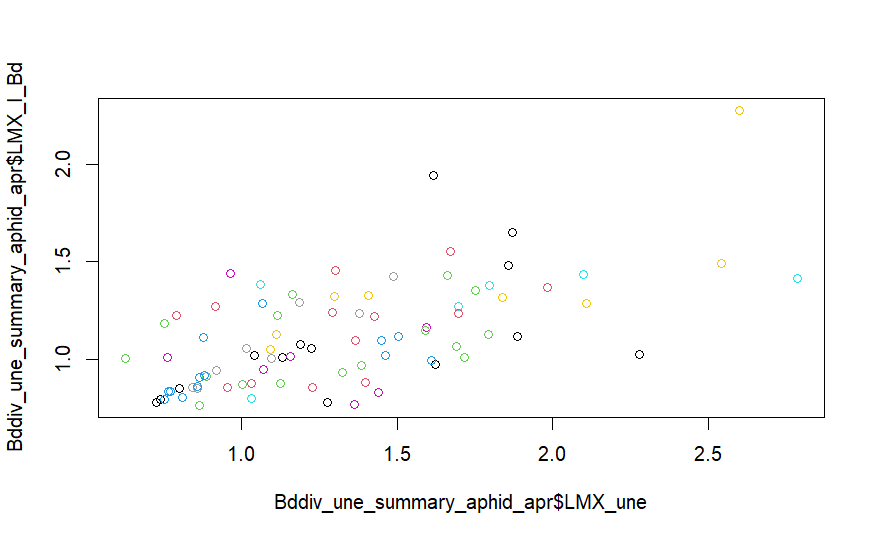

```r
plot(Bddiv_une_summary_aphid_apr$LMX_une, Bddiv_une_summary_aphid_apr$LMX_I_Bd, col = as.numeric(as.factor(Bddiv_une_summary_aphid_apr$une_section)))
```

##### Visualization at the B’-div level

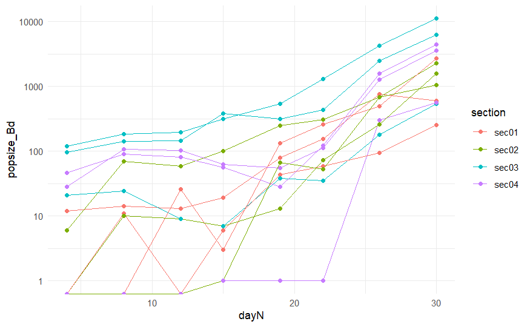

```r
ggplot(Bddiv_une_summary_aphid_apr, aes(x = dayN, y = popsize_Bd, group = une_section, color = section)) +
  geom_line() +
  geom_point() +
  scale_y_log10() +
  theme_minimal()
```

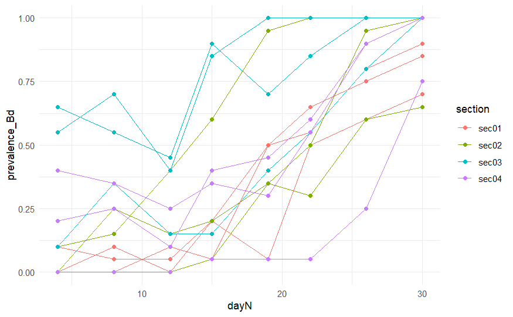

```r
ggplot(Bddiv_une_summary_aphid_apr, aes(x = dayN, y = prevalence_Bd, group = une_section, color = section)) +
  geom_line() +
  geom_point() +
  theme_minimal()
```

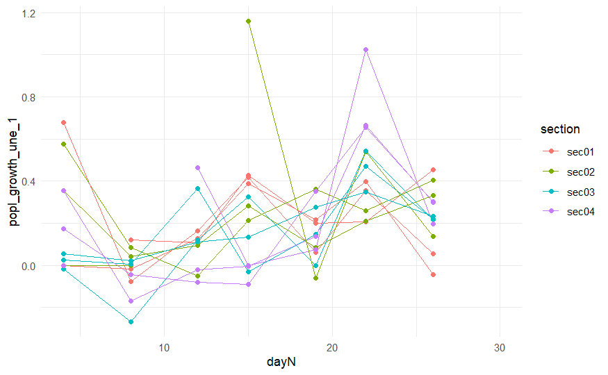

```r
ggplot(Bddiv_une_summary_aphid_apr, aes(x = dayN, y = popl_growth_une_1, group = une_section, color = section)) +
  geom_line() +
  geom_point() +
  theme_minimal()
```

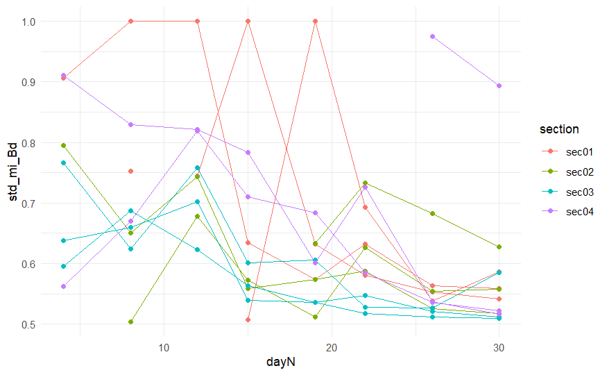

```r
ggplot(Bddiv_une_summary_aphid_apr, aes(x = dayN, y = std_mi_Bd, group = une_section, color = section)) +
  geom_line() +
  geom_point() +
  theme_minimal()
```

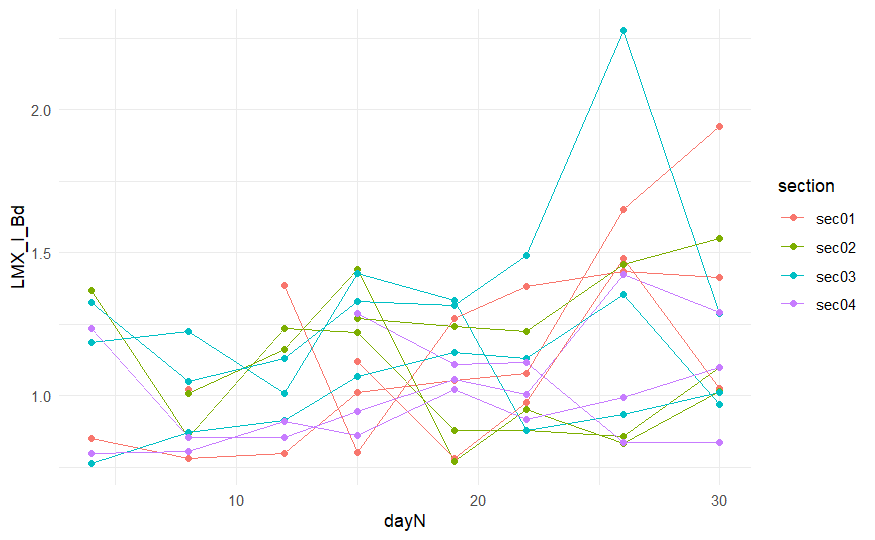

```r
ggplot(Bddiv_une_summary_aphid_apr, aes(x = dayN, y = LMX_I_Bd, group = une_section, color = section)) +
  geom_line() +
  geom_point() +
  theme_minimal()
```

– Morisita at B’-div vs population size at the une

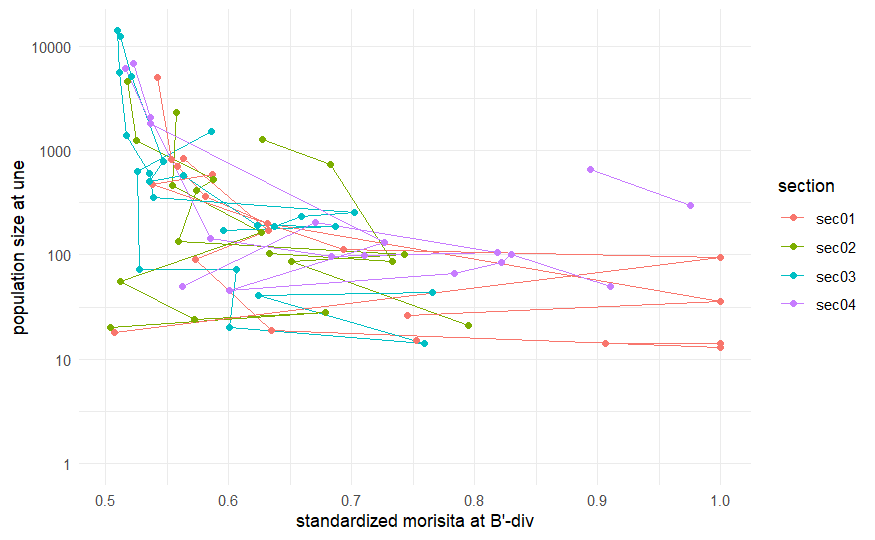

```r
ggplot(Bddiv_une_summary_aphid_apr, aes(x = std_mi_Bd, y = popsize_une, group = une_section, color = section)) +
  geom_path() +
  geom_point() +
  scale_y_log10() +
  labs(x = "standardized morisita at B'-div", y = "population size at une") +
  theme_minimal()
```

– Morisita vs prevalence

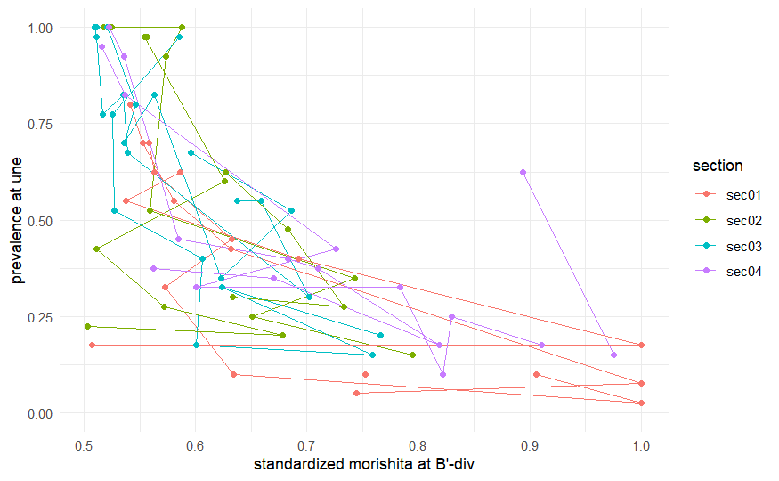

```r
ggplot(Bddiv_une_summary_aphid_apr, aes(x = std_mi_Bd, y = prevalence_une, group = une_section, color = section)) +
  geom_path() +
  geom_point() +
  labs(x = "standardized morishita at B'-div", y = "prevalence at une") +
  theme_minimal()
```

```r
#save.image("aphid_analysis2024April_v4_20260205.RData")
```

### [5.3] Calculation of spatial index by Moran’s I

#### [5.3.1] Moran’s I trial

For section 03

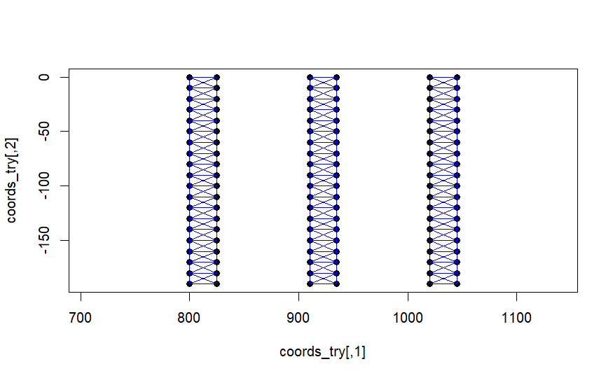

```r
sec03_aphid <- subset(aphid2024april, dayID == "s05" & section == "sec03")
max_dist <- 20*sqrt(2) #the diagonal of 20 cm x 20 cm square
coords_try <- cbind(sec03_aphid$x, sec03_aphid$y) #extract coordinates
nb_try <- dnearneigh(coords_try, 0, max_dist) #define the neighborhood
plot(coords_try, asp = 1, pch = 19)
plot(nb_try, coords_try, add = TRUE, col = "blue")
```

For B’-div level

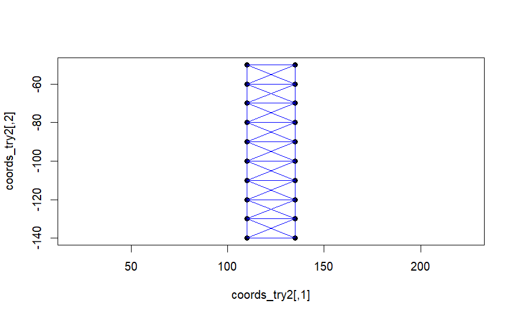

```r
bdiv_aphid <- split_aphid_Bddiv[[10]]
max_dist <- 20*sqrt(2) #the diagonal of 20 cm x 20 cm square
coords_try2 <- cbind(split_x_Bddiv[[10]], split_y_Bddiv[[10]]) #extract coordinates
nb_try2 <- dnearneigh(coords_try2, 0, max_dist) #define the neighborhood
plot(coords_try2, asp = 1, pch = 19)
plot(nb_try2, coords_try2, add = TRUE, col = "blue")
```

```r
lw_try <- nb2listw(nb_try, style="W") #wighted-spatial matrix
```

– Global (and Local) Moran’s I

```r
moran.test(sec03_aphid$aphid, lw_try)
```

```
    Moran I test under randomisation

data:  sec03_aphid$aphid
weights: lw_try

Moran I statistic standard deviate = 9.5144, p-value < 2.2e-16
alternative hypothesis: greater
sample estimates:
Moran I statistic       Expectation          Variance
      0.428336420      -0.008403361       0.002107108
```

```r
#localmoran(try_time10$adult, lw_try)
moran.test(sec03_aphid$aphid, lw_try)$statistic
```

```
Moran I statistic standard deviate
                          9.514356
```

#### [5.3.2] Moran’s I calculation for all time steps (for loop) at the une level

```r
res_moran_une_aphid <- list()
max_dist <- 20*sqrt(2) #the diagonal of 20 cm x  20cm square
for(i in 1:length(split_aphid_une)) {
  cat("+")
  data_sub <- split_aphid_une[[i]]
  coords_sub <- cbind(split_x_une[[i]], split_y_une[[i]]) #extract coordinates
  nb_sub <- dnearneigh(coords_sub, 0, max_dist)
  lw_sub <- nb2listw(nb_sub, style = "W")
  if(sum(data_sub) < 1) {
    res_moran_une_aphid[[i]] <- NA
    next
  }
  res_moran_une_aphid[[i]] <- moran.test(data_sub, lw_sub)$statistic
}
```

```
++++++++++++++++++++++++++++++++++++++++++++++++++++++++++++++++++++++++++++++++++++++++++++++++
```

##### Merging Moran’s I into summary dataframe

```r
Bddiv_une_summary_aphid_apr$moran_une = unlist(res_moran_une_aphid)
print(Bddiv_une_summary_aphid_apr)
```

|  | dayID | une | section | une_section | dayN | popsize_une | prevalence_une | std_mi_une | popl_growth_une_0 | popl_growth_une_1 | popl_growth_une_2 | prev_growth_une_0 | prev_growth_une_1 | prev_growth_une_2 | Ia_une | Perry_une | LMX_une | Bd_id | popsize_Bd | prevalence_Bd | std_mi_Bd | LMX_I_Bd | moran_une |
| --- | --- | --- | --- | --- | --- | --- | --- | --- | --- | --- | --- | --- | --- | --- | --- | --- | --- | --- | --- | --- | --- | --- | --- |
| s01.une01.sec01 | s01 | une01 | sec01 | une01.sec01 | 4 | 14 | 0.100 | 0.78917530 | NA | 0.000000000 | -0.018526993 | NA | -0.346573590 | 0.000000000 | 0.8130075 | 0.7749815 | 0.8003841 | Bd1 | 12 | 0.10 | 0.9060541 | 0.8521336 | 5.869581e-01 |
| s02.une01.sec01 | s02 | une01 | sec01 | une01.sec01 | 8 | 14 | 0.025 | 1.00000000 | 0.000000000 | -0.018526993 | 0.126496541 | -0.346573590 | 0.000000000 | 0.462098120 | 0.8007015 | 0.7624444 | 0.7255453 | Bd1 | 14 | 0.05 | 1.0000000 | 0.7812503 | 1.298643e-15 |
| s03.une01.sec01 | s03 | une01 | sec01 | une01.sec01 | 12 | 13 | 0.025 | 1.00000000 | -0.018526993 | 0.126496541 | 0.388842673 | 0.000000000 | 0.462098120 | 0.294663749 | 0.7793757 | 0.7420616 | 0.7367024 | Bd1 | 13 | 0.05 | 1.0000000 | 0.7972961 | 1.298643e-15 |
| s04.une01.sec01 | s04 | une01 | sec01 | une01.sec01 | 15 | 19 | 0.100 | 0.64854730 | 0.126496541 | 0.388842673 | 0.215894935 | 0.462098120 | 0.294663749 | 0.108474133 | 1.2444590 | 1.1420846 | 1.1317667 | Bd1 | 19 | 0.20 | 0.6343110 | 1.0103692 | 3.832913e+00 |
| s05.une01.sec01 | s05 | une01 | sec01 | une01.sec01 | 19 | 90 | 0.325 | 0.56622671 | 0.388842673 | 0.215894935 | 0.399141177 | 0.294663749 | 0.108474133 | 0.082126017 | 1.1433156 | 1.1982143 | 1.2245302 | Bd1 | 80 | 0.50 | 0.5730081 | 1.0544121 | 4.493527e+00 |
| s06.une01.sec01 | s06 | une01 | sec01 | une01.sec01 | 22 | 172 | 0.450 | 0.61107883 | 0.215894935 | 0.399141177 | -0.044698554 | 0.108474133 | 0.082126017 | 0.028332171 | 1.2665228 | 1.0866857 | 1.1879449 | Bd1 | 153 | 0.55 | 0.6324230 | 1.0779792 | 1.404378e+00 |
| s07.une01.sec01 | s07 | une01 | sec01 | une01.sec01 | 26 | 849 | 0.625 | 0.55978312 | 0.399141177 | -0.044698554 | NA | 0.082126017 | 0.028332171 | NA | 2.2029741 | 1.8608263 | 1.8704299 | Bd1 | 767 | 0.80 | 0.5632396 | 1.6522964 | 2.318034e+00 |
| s08.une01.sec01 | s08 | une01 | sec01 | une01.sec01 | 30 | 710 | 0.700 | 0.55017257 | -0.044698554 | NA | NA | 0.028332171 | NA | NA | 1.7594752 | 1.5169743 | 1.6175517 | Bd1 | 595 | 0.90 | 0.5582896 | 1.9400994 | 4.542967e+00 |
| s01.une02.sec01 | s01 | une02 | sec01 | une02.sec01 | 4 | 0 | 0.000 | NaN | NA | NA | 0.121376954 | NA | NA | 0.000000000 | NA | NA | NA | Bd2 | 0 | 0.00 | NaN | NA | NA |
| s02.une02.sec01 | s02 | une02 | sec01 | une02.sec01 | 8 | 16 | 0.050 | 0.93373153 | NA | 0.121376954 | 0.108474133 | NA | 0.000000000 | 0.135155036 | 0.9655316 | 1.0499891 | 1.0276260 | Bd2 | 0 | 0.00 | NaN | NA | 1.931748e+00 |

[output cut: 86 more lines]

##### Visualization of Moran’s I at une

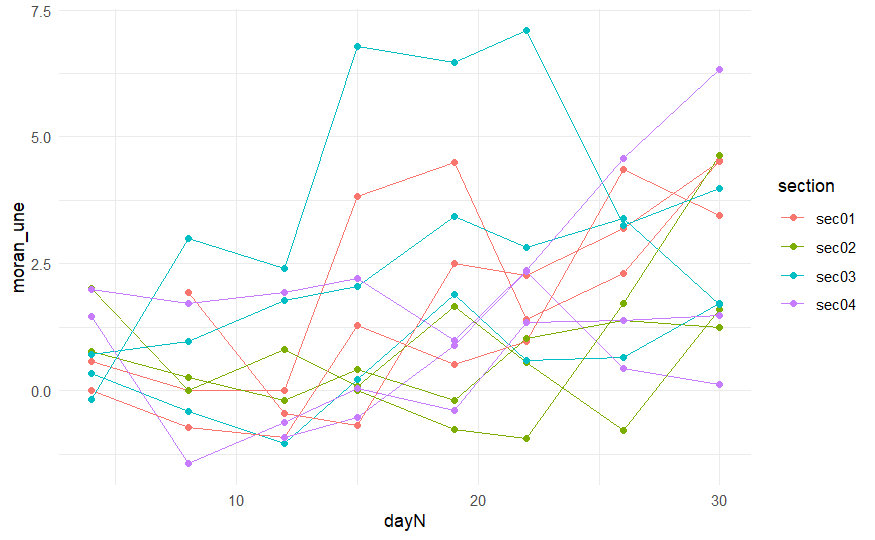

```r
ggplot(Bddiv_une_summary_aphid_apr, aes(x = dayN, y = moran_une, group = une_section, color = section)) +
  geom_line() +
  geom_point() +
  theme_minimal()
```

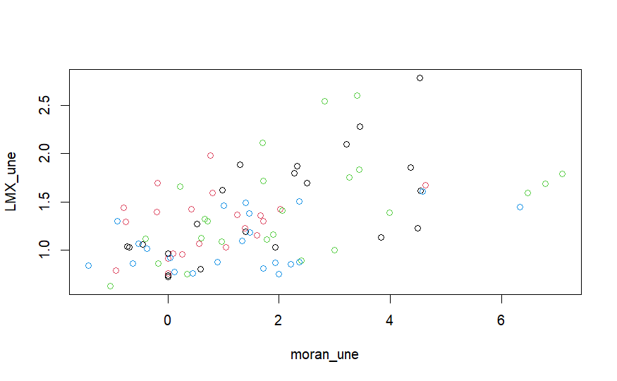

```r
plot(LMX_une ~ moran_une, data = Bddiv_une_summary_aphid_apr, col = as.factor(section))
```

#### [5.3.3] Moran’s I calculation for all time steps (for loop) at the B’-div level

```r
res_moran_Bd_aphid <- list()
max_dist <- 20*sqrt(2) #the diagonal of 20 cm x  20cm square
for(i in 1:length(split_aphid_Bddiv)) {
  cat("+")
  data_sub <- split_aphid_Bddiv[[i]]
  coords_sub <- cbind(split_x_Bddiv[[i]], split_y_Bddiv[[i]]) #extract coordinates
  nb_sub <- dnearneigh(coords_sub, 0, max_dist)
  lw_sub <- nb2listw(nb_sub, style = "W")
  if(sum(data_sub) < 1) {
    res_moran_Bd_aphid[[i]] <- NA
    next
  }
  res_moran_Bd_aphid[[i]] <- moran.test(data_sub, lw_sub)$statistic
}
```

```
++++++++++++++++++++++++++++++++++++++++++++++++++++++++++++++++++++++++++++++++++++++++++++++++
```

##### Merging Moran’s I into summary dataframe

```r
Bddiv_une_summary_aphid_apr$moran_Bd = unlist(res_moran_Bd_aphid)
print(Bddiv_une_summary_aphid_apr)
```

|  | dayID | une | section | une_section | dayN | popsize_une | prevalence_une | std_mi_une | popl_growth_une_0 | popl_growth_une_1 | popl_growth_une_2 | prev_growth_une_0 | prev_growth_une_1 | prev_growth_une_2 | Ia_une | Perry_une | LMX_une | Bd_id | popsize_Bd | prevalence_Bd | std_mi_Bd | LMX_I_Bd | moran_une | moran_Bd |
| --- | --- | --- | --- | --- | --- | --- | --- | --- | --- | --- | --- | --- | --- | --- | --- | --- | --- | --- | --- | --- | --- | --- | --- | --- |
| s01.une01.sec01 | s01 | une01 | sec01 | une01.sec01 | 4 | 14 | 0.100 | 0.78917530 | NA | 0.000000000 | -0.018526993 | NA | -0.346573590 | 0.000000000 | 0.8130075 | 0.7749815 | 0.8003841 | Bd1 | 12 | 0.10 | 0.9060541 | 0.8521336 | 5.869581e-01 | 1.030072e+00 |
| s02.une01.sec01 | s02 | une01 | sec01 | une01.sec01 | 8 | 14 | 0.025 | 1.00000000 | 0.000000000 | -0.018526993 | 0.126496541 | -0.346573590 | 0.000000000 | 0.462098120 | 0.8007015 | 0.7624444 | 0.7255453 | Bd1 | 14 | 0.05 | 1.0000000 | 0.7812503 | 1.298643e-15 | 8.947336e-16 |
| s03.une01.sec01 | s03 | une01 | sec01 | une01.sec01 | 12 | 13 | 0.025 | 1.00000000 | -0.018526993 | 0.126496541 | 0.388842673 | 0.000000000 | 0.462098120 | 0.294663749 | 0.7793757 | 0.7420616 | 0.7367024 | Bd1 | 13 | 0.05 | 1.0000000 | 0.7972961 | 1.298643e-15 | 2.684201e-15 |
| s04.une01.sec01 | s04 | une01 | sec01 | une01.sec01 | 15 | 19 | 0.100 | 0.64854730 | 0.126496541 | 0.388842673 | 0.215894935 | 0.462098120 | 0.294663749 | 0.108474133 | 1.2444590 | 1.1420846 | 1.1317667 | Bd1 | 19 | 0.20 | 0.6343110 | 1.0103692 | 3.832913e+00 | 2.243048e+00 |
| s05.une01.sec01 | s05 | une01 | sec01 | une01.sec01 | 19 | 90 | 0.325 | 0.56622671 | 0.388842673 | 0.215894935 | 0.399141177 | 0.294663749 | 0.108474133 | 0.082126017 | 1.1433156 | 1.1982143 | 1.2245302 | Bd1 | 80 | 0.50 | 0.5730081 | 1.0544121 | 4.493527e+00 | 2.553003e+00 |
| s06.une01.sec01 | s06 | une01 | sec01 | une01.sec01 | 22 | 172 | 0.450 | 0.61107883 | 0.215894935 | 0.399141177 | -0.044698554 | 0.108474133 | 0.082126017 | 0.028332171 | 1.2665228 | 1.0866857 | 1.1879449 | Bd1 | 153 | 0.55 | 0.6324230 | 1.0779792 | 1.404378e+00 | 1.350223e-01 |
| s07.une01.sec01 | s07 | une01 | sec01 | une01.sec01 | 26 | 849 | 0.625 | 0.55978312 | 0.399141177 | -0.044698554 | NA | 0.082126017 | 0.028332171 | NA | 2.2029741 | 1.8608263 | 1.8704299 | Bd1 | 767 | 0.80 | 0.5632396 | 1.6522964 | 2.318034e+00 | 1.644660e+00 |
| s08.une01.sec01 | s08 | une01 | sec01 | une01.sec01 | 30 | 710 | 0.700 | 0.55017257 | -0.044698554 | NA | NA | 0.028332171 | NA | NA | 1.7594752 | 1.5169743 | 1.6175517 | Bd1 | 595 | 0.90 | 0.5582896 | 1.9400994 | 4.542967e+00 | 3.977754e+00 |
| s01.une02.sec01 | s01 | une02 | sec01 | une02.sec01 | 4 | 0 | 0.000 | NaN | NA | NA | 0.121376954 | NA | NA | 0.000000000 | NA | NA | NA | Bd2 | 0 | 0.00 | NaN | NA | NA | NA |
| s02.une02.sec01 | s02 | une02 | sec01 | une02.sec01 | 8 | 16 | 0.050 | 0.93373153 | NA | 0.121376954 | 0.108474133 | NA | 0.000000000 | 0.135155036 | 0.9655316 | 1.0499891 | 1.0276260 | Bd2 | 0 | 0.00 | NaN | NA | 1.931748e+00 | NA |

[output cut: 86 more lines]

##### Visualization of Moran’s I at une

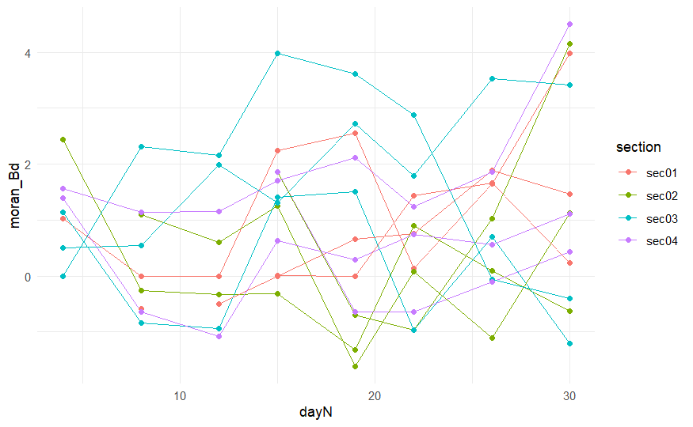

```r
ggplot(Bddiv_une_summary_aphid_apr, aes(x = dayN, y = moran_Bd, group = une_section, color = section)) +
  geom_line() +
  geom_point() +
  theme_minimal()
```

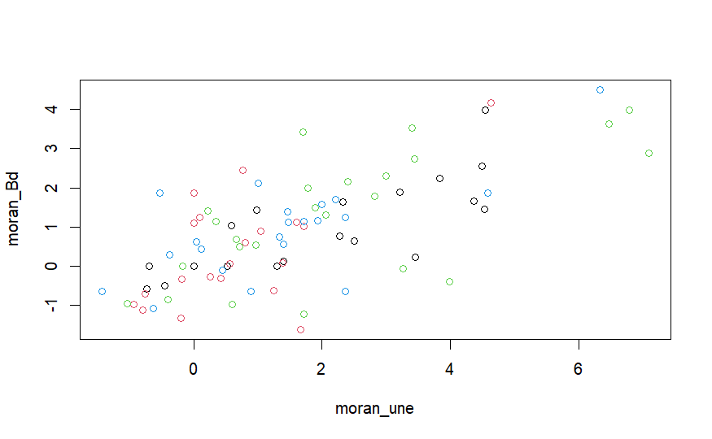

```r
plot(moran_Bd ~ moran_une, data = Bddiv_une_summary_aphid_apr, col = as.factor(section))
```

```r
#save.image("aphid_analysis2024April_v4_20260220.RData")
```

## [6] Autoregression model w/ unequal intervals

```r
load("aphid_analysis2024April_v4_20260220.RData")
```

– Review Une-level and B’-div level data

```r
print(summary_aphid_apr_une)
```

|  | dayID | une | section | une_section | dayN | popsize_une | prevalence_une | std_mi_une | popl_growth_une_0 | popl_growth_une_1 | popl_growth_une_2 | prev_growth_une_0 | prev_growth_une_1 | prev_growth_une_2 | Ia_une | Perry_une | LMX_une |
| --- | --- | --- | --- | --- | --- | --- | --- | --- | --- | --- | --- | --- | --- | --- | --- | --- | --- |
| s01.une01.sec01 | s01 | une01 | sec01 | une01.sec01 | 4 | 14 | 0.100 | 0.78917530 | NA | 0.000000000 | -0.018526993 | NA | -0.346573590 | 0.000000000 | 0.8130075 | 0.7749815 | 0.8003841 |
| s02.une01.sec01 | s02 | une01 | sec01 | une01.sec01 | 8 | 14 | 0.025 | 1.00000000 | 0.000000000 | -0.018526993 | 0.126496541 | -0.346573590 | 0.000000000 | 0.462098120 | 0.8007015 | 0.7624444 | 0.7255453 |
| s03.une01.sec01 | s03 | une01 | sec01 | une01.sec01 | 12 | 13 | 0.025 | 1.00000000 | -0.018526993 | 0.126496541 | 0.388842673 | 0.000000000 | 0.462098120 | 0.294663749 | 0.7793757 | 0.7420616 | 0.7367024 |
| s04.une01.sec01 | s04 | une01 | sec01 | une01.sec01 | 15 | 19 | 0.100 | 0.64854730 | 0.126496541 | 0.388842673 | 0.215894935 | 0.462098120 | 0.294663749 | 0.108474133 | 1.2444590 | 1.1420846 | 1.1317667 |
| s05.une01.sec01 | s05 | une01 | sec01 | une01.sec01 | 19 | 90 | 0.325 | 0.56622671 | 0.388842673 | 0.215894935 | 0.399141177 | 0.294663749 | 0.108474133 | 0.082126017 | 1.1433156 | 1.1982143 | 1.2245302 |
| s06.une01.sec01 | s06 | une01 | sec01 | une01.sec01 | 22 | 172 | 0.450 | 0.61107883 | 0.215894935 | 0.399141177 | -0.044698554 | 0.108474133 | 0.082126017 | 0.028332171 | 1.2665228 | 1.0866857 | 1.1879449 |
| s07.une01.sec01 | s07 | une01 | sec01 | une01.sec01 | 26 | 849 | 0.625 | 0.55978312 | 0.399141177 | -0.044698554 | NA | 0.082126017 | 0.028332171 | NA | 2.2029741 | 1.8608263 | 1.8704299 |
| s08.une01.sec01 | s08 | une01 | sec01 | une01.sec01 | 30 | 710 | 0.700 | 0.55017257 | -0.044698554 | NA | NA | 0.028332171 | NA | NA | 1.7594752 | 1.5169743 | 1.6175517 |
| s01.une02.sec01 | s01 | une02 | sec01 | une02.sec01 | 4 | 0 | 0.000 | NaN | NA | NA | 0.121376954 | NA | NA | 0.000000000 | NA | NA | NA |
| s02.une02.sec01 | s02 | une02 | sec01 | une02.sec01 | 8 | 16 | 0.050 | 0.93373153 | NA | 0.121376954 | 0.108474133 | NA | 0.000000000 | 0.135155036 | 0.9655316 | 1.0499891 | 1.0276260 |

[output cut: 86 more lines]

```r
print(Bddiv_une_summary_aphid_apr)
```

|  | dayID | une | section | une_section | dayN | popsize_une | prevalence_une | std_mi_une | popl_growth_une_0 | popl_growth_une_1 | popl_growth_une_2 | prev_growth_une_0 | prev_growth_une_1 | prev_growth_une_2 | Ia_une | Perry_une | LMX_une | Bd_id | popsize_Bd | prevalence_Bd | std_mi_Bd | LMX_I_Bd | moran_une | moran_Bd |
| --- | --- | --- | --- | --- | --- | --- | --- | --- | --- | --- | --- | --- | --- | --- | --- | --- | --- | --- | --- | --- | --- | --- | --- | --- |
| s01.une01.sec01 | s01 | une01 | sec01 | une01.sec01 | 4 | 14 | 0.100 | 0.78917530 | NA | 0.000000000 | -0.018526993 | NA | -0.346573590 | 0.000000000 | 0.8130075 | 0.7749815 | 0.8003841 | Bd1 | 12 | 0.10 | 0.9060541 | 0.8521336 | 5.869581e-01 | 1.030072e+00 |
| s02.une01.sec01 | s02 | une01 | sec01 | une01.sec01 | 8 | 14 | 0.025 | 1.00000000 | 0.000000000 | -0.018526993 | 0.126496541 | -0.346573590 | 0.000000000 | 0.462098120 | 0.8007015 | 0.7624444 | 0.7255453 | Bd1 | 14 | 0.05 | 1.0000000 | 0.7812503 | 1.298643e-15 | 8.947336e-16 |
| s03.une01.sec01 | s03 | une01 | sec01 | une01.sec01 | 12 | 13 | 0.025 | 1.00000000 | -0.018526993 | 0.126496541 | 0.388842673 | 0.000000000 | 0.462098120 | 0.294663749 | 0.7793757 | 0.7420616 | 0.7367024 | Bd1 | 13 | 0.05 | 1.0000000 | 0.7972961 | 1.298643e-15 | 2.684201e-15 |
| s04.une01.sec01 | s04 | une01 | sec01 | une01.sec01 | 15 | 19 | 0.100 | 0.64854730 | 0.126496541 | 0.388842673 | 0.215894935 | 0.462098120 | 0.294663749 | 0.108474133 | 1.2444590 | 1.1420846 | 1.1317667 | Bd1 | 19 | 0.20 | 0.6343110 | 1.0103692 | 3.832913e+00 | 2.243048e+00 |
| s05.une01.sec01 | s05 | une01 | sec01 | une01.sec01 | 19 | 90 | 0.325 | 0.56622671 | 0.388842673 | 0.215894935 | 0.399141177 | 0.294663749 | 0.108474133 | 0.082126017 | 1.1433156 | 1.1982143 | 1.2245302 | Bd1 | 80 | 0.50 | 0.5730081 | 1.0544121 | 4.493527e+00 | 2.553003e+00 |
| s06.une01.sec01 | s06 | une01 | sec01 | une01.sec01 | 22 | 172 | 0.450 | 0.61107883 | 0.215894935 | 0.399141177 | -0.044698554 | 0.108474133 | 0.082126017 | 0.028332171 | 1.2665228 | 1.0866857 | 1.1879449 | Bd1 | 153 | 0.55 | 0.6324230 | 1.0779792 | 1.404378e+00 | 1.350223e-01 |
| s07.une01.sec01 | s07 | une01 | sec01 | une01.sec01 | 26 | 849 | 0.625 | 0.55978312 | 0.399141177 | -0.044698554 | NA | 0.082126017 | 0.028332171 | NA | 2.2029741 | 1.8608263 | 1.8704299 | Bd1 | 767 | 0.80 | 0.5632396 | 1.6522964 | 2.318034e+00 | 1.644660e+00 |
| s08.une01.sec01 | s08 | une01 | sec01 | une01.sec01 | 30 | 710 | 0.700 | 0.55017257 | -0.044698554 | NA | NA | 0.028332171 | NA | NA | 1.7594752 | 1.5169743 | 1.6175517 | Bd1 | 595 | 0.90 | 0.5582896 | 1.9400994 | 4.542967e+00 | 3.977754e+00 |
| s01.une02.sec01 | s01 | une02 | sec01 | une02.sec01 | 4 | 0 | 0.000 | NaN | NA | NA | 0.121376954 | NA | NA | 0.000000000 | NA | NA | NA | Bd2 | 0 | 0.00 | NaN | NA | NA | NA |
| s02.une02.sec01 | s02 | une02 | sec01 | une02.sec01 | 8 | 16 | 0.050 | 0.93373153 | NA | 0.121376954 | 0.108474133 | NA | 0.000000000 | 0.135155036 | 0.9655316 | 1.0499891 | 1.0276260 | Bd2 | 0 | 0.00 | NaN | NA | 1.931748e+00 | NA |

[output cut: 86 more lines]

– Modify “une_section” column since section name should come first when visualizing the results.

```r
# Overwrite une_section column: section first, then une
Bddiv_une_summary_aphid_apr$une_section <- paste(
  Bddiv_une_summary_aphid_apr$section,
  Bddiv_une_summary_aphid_apr$une,
  sep = "."
)
print(Bddiv_une_summary_aphid_apr)
```

|  | dayID | une | section | une_section | dayN | popsize_une | prevalence_une | std_mi_une | popl_growth_une_0 | popl_growth_une_1 | popl_growth_une_2 | prev_growth_une_0 | prev_growth_une_1 | prev_growth_une_2 | Ia_une | Perry_une | LMX_une | Bd_id | popsize_Bd | prevalence_Bd | std_mi_Bd | LMX_I_Bd | moran_une | moran_Bd |
| --- | --- | --- | --- | --- | --- | --- | --- | --- | --- | --- | --- | --- | --- | --- | --- | --- | --- | --- | --- | --- | --- | --- | --- | --- |
| s01.une01.sec01 | s01 | une01 | sec01 | sec01.une01 | 4 | 14 | 0.100 | 0.78917530 | NA | 0.000000000 | -0.018526993 | NA | -0.346573590 | 0.000000000 | 0.8130075 | 0.7749815 | 0.8003841 | Bd1 | 12 | 0.10 | 0.9060541 | 0.8521336 | 5.869581e-01 | 1.030072e+00 |
| s02.une01.sec01 | s02 | une01 | sec01 | sec01.une01 | 8 | 14 | 0.025 | 1.00000000 | 0.000000000 | -0.018526993 | 0.126496541 | -0.346573590 | 0.000000000 | 0.462098120 | 0.8007015 | 0.7624444 | 0.7255453 | Bd1 | 14 | 0.05 | 1.0000000 | 0.7812503 | 1.298643e-15 | 8.947336e-16 |
| s03.une01.sec01 | s03 | une01 | sec01 | sec01.une01 | 12 | 13 | 0.025 | 1.00000000 | -0.018526993 | 0.126496541 | 0.388842673 | 0.000000000 | 0.462098120 | 0.294663749 | 0.7793757 | 0.7420616 | 0.7367024 | Bd1 | 13 | 0.05 | 1.0000000 | 0.7972961 | 1.298643e-15 | 2.684201e-15 |
| s04.une01.sec01 | s04 | une01 | sec01 | sec01.une01 | 15 | 19 | 0.100 | 0.64854730 | 0.126496541 | 0.388842673 | 0.215894935 | 0.462098120 | 0.294663749 | 0.108474133 | 1.2444590 | 1.1420846 | 1.1317667 | Bd1 | 19 | 0.20 | 0.6343110 | 1.0103692 | 3.832913e+00 | 2.243048e+00 |
| s05.une01.sec01 | s05 | une01 | sec01 | sec01.une01 | 19 | 90 | 0.325 | 0.56622671 | 0.388842673 | 0.215894935 | 0.399141177 | 0.294663749 | 0.108474133 | 0.082126017 | 1.1433156 | 1.1982143 | 1.2245302 | Bd1 | 80 | 0.50 | 0.5730081 | 1.0544121 | 4.493527e+00 | 2.553003e+00 |
| s06.une01.sec01 | s06 | une01 | sec01 | sec01.une01 | 22 | 172 | 0.450 | 0.61107883 | 0.215894935 | 0.399141177 | -0.044698554 | 0.108474133 | 0.082126017 | 0.028332171 | 1.2665228 | 1.0866857 | 1.1879449 | Bd1 | 153 | 0.55 | 0.6324230 | 1.0779792 | 1.404378e+00 | 1.350223e-01 |
| s07.une01.sec01 | s07 | une01 | sec01 | sec01.une01 | 26 | 849 | 0.625 | 0.55978312 | 0.399141177 | -0.044698554 | NA | 0.082126017 | 0.028332171 | NA | 2.2029741 | 1.8608263 | 1.8704299 | Bd1 | 767 | 0.80 | 0.5632396 | 1.6522964 | 2.318034e+00 | 1.644660e+00 |
| s08.une01.sec01 | s08 | une01 | sec01 | sec01.une01 | 30 | 710 | 0.700 | 0.55017257 | -0.044698554 | NA | NA | 0.028332171 | NA | NA | 1.7594752 | 1.5169743 | 1.6175517 | Bd1 | 595 | 0.90 | 0.5582896 | 1.9400994 | 4.542967e+00 | 3.977754e+00 |
| s01.une02.sec01 | s01 | une02 | sec01 | sec01.une02 | 4 | 0 | 0.000 | NaN | NA | NA | 0.121376954 | NA | NA | 0.000000000 | NA | NA | NA | Bd2 | 0 | 0.00 | NaN | NA | NA | NA |
| s02.une02.sec01 | s02 | une02 | sec01 | sec01.une02 | 8 | 16 | 0.050 | 0.93373153 | NA | 0.121376954 | 0.108474133 | NA | 0.000000000 | 0.135155036 | 0.9655316 | 1.0499891 | 1.0276260 | Bd2 | 0 | 0.00 | NaN | NA | 1.931748e+00 | NA |

[output cut: 86 more lines]

– Systematically: model selection by LORO

- prepare several lists

```r
candidate_formulas <- list()
results_LORO <- list()
score_table <- list()
final_fit <- list()
best_model_name <- list()
best_formula <- list()
```

### [6.1] Une-level future state, regressed by une-level present state and spatial indices

#### Visualization for the manuscript

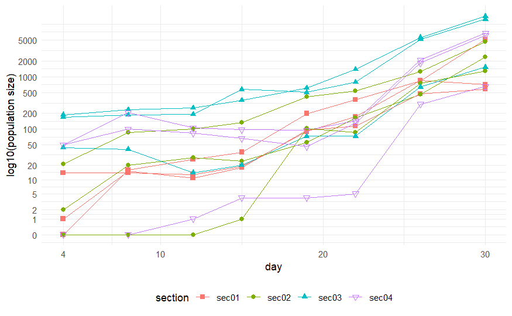

```r
ggplot(summary_aphid_apr_une, aes(x = dayN, y = (popsize_une), group = une_section, color = section, shape = section)) +
  geom_line() +
  geom_point(size = 2) +
  scale_x_continuous(breaks = c(4, 10, 20, 30),
                     name = "day") +
  scale_y_continuous(trans = "log1p",
                     breaks = c(0, 1, 2, 5, 10, 20, 50, 100, 200, 500, 1000, 2000, 5000),
                     name = "log10(population size)", ) +
  scale_shape_manual(
    values = c(15, 16, 17, 25)
  ) +
  theme_minimal() +
  theme(
    legend.position = "bottom"
  )
```

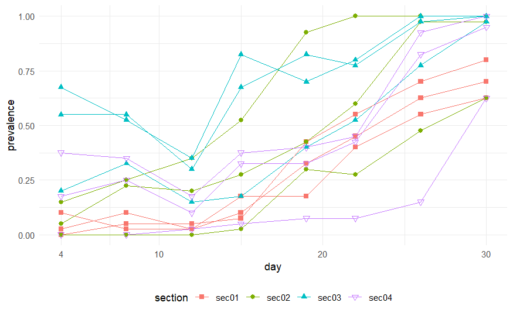

```r
ggplot(summary_aphid_apr_une, aes(x = dayN, y = prevalence_une, group = une_section, color = section, shape = section)) +
  geom_line() +
  geom_point(size = 2) +
  scale_x_continuous(breaks = c(4, 10, 20, 30),
                     name = "day") +
  scale_y_continuous(name = "prevalence") +
  scale_shape_manual(
    values = c(15, 16, 17, 25)
  ) +
  theme_minimal() +
  theme(
    legend.position = "bottom"
  )
```

– For the manuscript (Fig.1)

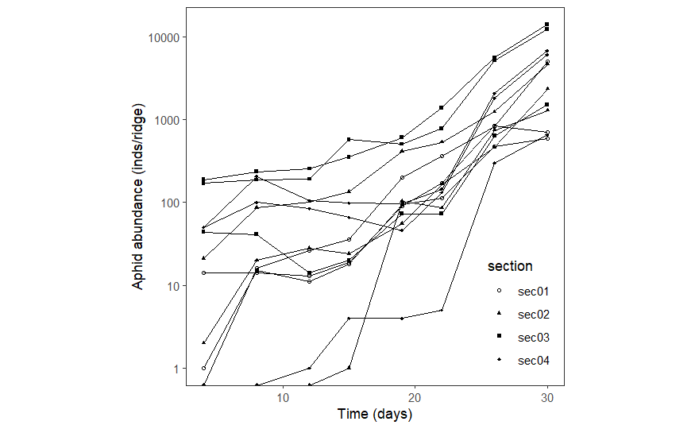

```r
ggplot(summary_aphid_apr_une, aes(x = dayN, y = popsize_une, group = une_section, shape = section)) +
  geom_line(linewidth = 0.2) +
  geom_point(size = 1) +
  scale_shape_manual(values = c(1, 17, 15, 18)) +
  scale_y_log10() +
  labs(
    x = "Time (days)",
    y = "Aphid abundance (inds/ridge)"
  ) +
theme_bw() +
  theme(
    panel.grid = element_blank(),
    aspect.ratio = 1.0,
    legend.position = c(0.98, 0.02),
    legend.justification = c(1, 0)
    )
```

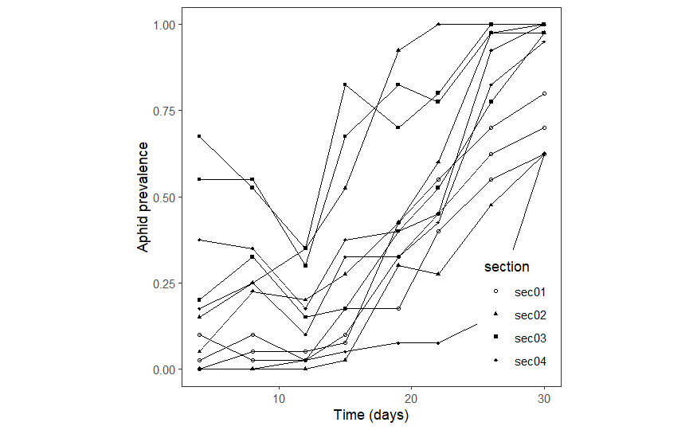

```r
ggplot(summary_aphid_apr_une, aes(x = dayN, y = prevalence_une, group = une_section, shape = section)) +
  geom_line(linewidth = 0.2) +
  geom_point(size = 1) +
  scale_shape_manual(values = c(1, 17, 15, 18)) +
  #scale_y_log10() +
  labs(
    x = "Time (days)",
    y = "Aphid prevalence"
  ) +
theme_bw() +
  theme(
    panel.grid = element_blank(),
    aspect.ratio = 1.0,
    legend.position = c(0.98, 0.02),
    legend.justification = c(1, 0)
    )
```

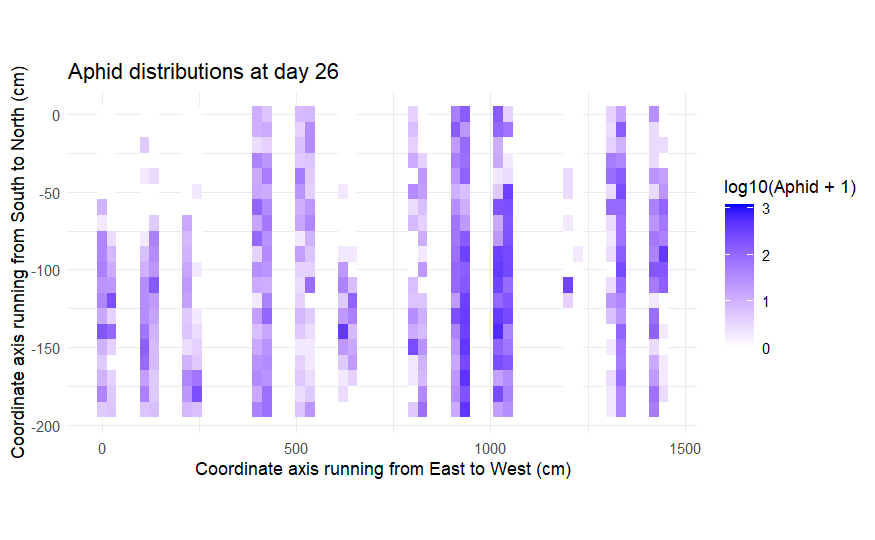

```r
time_snap <- 7
ggplot(subset(aphid_ggplot, time == time_snap), aes(x = x, y = y, fill = log10(aphid + 1))) +
  geom_tile() +
  scale_fill_gradient(low = "white", high = "blue", limits = c(aphid_min, aphid_max)) +
  labs(title = "Aphid distributions at day 26",
       x = "Coordinate axis running from East to West (cm)",
       y = "Coordinate axis running from South to North (cm)",
       fill = "log10(Aphid + 1)") + coord_fixed(ratio = 4.0) +  #  setting aspect ratio
  theme_minimal()
```

#### [6.1.1] Trial of autoregression with unequal intervals

– NA should be excluded

```r
Bddiv_une_summary_aphid_apr_temp <- subset(Bddiv_une_summary_aphid_apr, !is.na(popl_growth_une_1) & !is.na(std_mi_une) & !is.na(LMX_une))
```

- trial

```r
# exponential growth + unequal time interval (continuous interval)
m2_cont <- gls(popl_growth_une_1 ~ std_mi_une,
          data = Bddiv_une_summary_aphid_apr_temp,
          correlation = corCAR1(form = ~ dayN | une_section),
          method = "REML")
summary(m2_cont)
```

```
Generalized least squares fit by REML
  Model: popl_growth_une_1 ~ std_mi_une
  Data: Bddiv_une_summary_aphid_apr_temp
```

|  | AIC | BIC | logLik |
| --- | --- | --- | --- |
|  | -6.072282 | 3.089556 | 7.036141 |

```
Correlation Structure: Continuous AR(1)
 Formula: ~dayN | une_section
 Parameter estimate(s):
         Phi
0.0009586188

Coefficients:
```

|  | Value | Std.Error | t-value | p-value |
| --- | --- | --- | --- | --- |
| (Intercept) | 0.4411796 | 0.1052568 | 4.191459 | 0.0001 |
| std_mi_une | -0.4045287 | 0.1672708 | -2.418405 | 0.0181 |

```
 Correlation:
           (Intr)
std_mi_une -0.972

Standardized residuals:
        Min          Q1         Med          Q3         Max
-2.29334280 -0.74113554 -0.05437638  0.60837239  3.75195196

Residual standard error: 0.212634
Degrees of freedom: 75 total; 73 residual
```

```r
summary(m2_cont)$tTable
```

```
                 Value Std.Error   t-value      p-value
(Intercept)  0.4411796 0.1052568  4.191459 7.675519e-05
std_mi_une  -0.4045287 0.1672708 -2.418405 1.808351e-02
```

```r
m3_cont <- gls(popl_growth_une_1 ~ LMX_une,
          data = Bddiv_une_summary_aphid_apr_temp,
          correlation = corCAR1(form = ~ dayN | une_section),
          method = "REML")
summary(m3_cont)
```

```
Generalized least squares fit by REML
  Model: popl_growth_une_1 ~ LMX_une
  Data: Bddiv_une_summary_aphid_apr_temp
```

|  | AIC | BIC | logLik |
| --- | --- | --- | --- |
|  | -5.221834 | 3.940003 | 6.610917 |

```
Correlation Structure: Continuous AR(1)
 Formula: ~dayN | une_section
 Parameter estimate(s):
        Phi
0.001029346

Coefficients:
```

|  | Value | Std.Error | t-value | p-value |
| --- | --- | --- | --- | --- |
| (Intercept) | -0.00431161 | 0.07763215 | -0.055539 | 0.9559 |
| LMX_une | 0.15574209 | 0.05799550 | 2.685417 | 0.0090 |

```
 Correlation:
        (Intr)
LMX_une -0.95

Standardized residuals:
       Min         Q1        Med         Q3        Max
-2.0769083 -0.6625084 -0.1416552  0.4207131  3.7647572

Residual standard error: 0.2108199
Degrees of freedom: 75 total; 73 residual
```

```r
summary(m3_cont)$tTable
```

```
                   Value  Std.Error   t-value     p-value
(Intercept) -0.004311612 0.07763215 -0.055539 0.955860789
LMX_une      0.155742094 0.05799550  2.685417 0.008961219
```

- visualization

```r
pred_m23_cont <- data.frame(
  obs = Bddiv_une_summary_aphid_apr_temp$popl_growth_une_1,
  pred_mi = predict(m2_cont, newdata = Bddiv_une_summary_aphid_apr_temp),
  pred_LMX = predict(m3_cont, newdata = Bddiv_une_summary_aphid_apr_temp)
)

pred_long_m23_cont <- rbind(
  data.frame(model = "LMX_Bd", pred = pred_m23_cont$pred_LMX, obs = pred_m23_cont$obs),
  data.frame(model = "std_mi_Bd", pred = pred_m23_cont$pred_mi, obs = pred_m23_cont$obs)
)
```

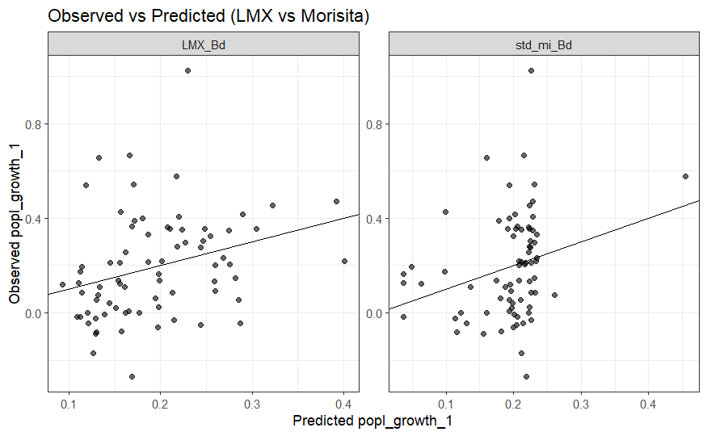

```r
ggplot(pred_long_m23_cont, aes(x = pred, y = obs)) +
  geom_point(alpha = 0.6) +
  geom_abline(slope = 1, intercept = 0) +
  facet_wrap(~ model, scales = "free") +
  labs(y = "Observed popl_growth_1",
       x = "Predicted popl_growth_1",
       title = "Observed vs Predicted (LMX vs Morisita)") +
  theme_bw()
```

#### [6.1.2] Population growth rate 1

##### Analysis

```r
## =========================================================
## 1) Data prearrangement
## =========================================================
Bddiv_une_summary_aphid_apr_CAR1_forUne <- subset(Bddiv_une_summary_aphid_apr, !is.na(popl_growth_une_1) & !is.na(std_mi_une) & !is.na(LMX_une))
```

– Check colinearity

```r
cor(Bddiv_une_summary_aphid_apr_CAR1_forUne[, c("popsize_une", "prevalence_une", "std_mi_une", "LMX_une", "moran_une")])
```

```
               popsize_une prevalence_une std_mi_une    LMX_une  moran_une
popsize_une      1.0000000      0.5974361 -0.1993371  0.4816831  0.3524881
prevalence_une   0.5974361      1.0000000 -0.4415376  0.5021257  0.4092482
std_mi_une      -0.1993371     -0.4415376  1.0000000 -0.4013096 -0.2487042
LMX_une          0.4816831      0.5021257 -0.4013096  1.0000000  0.4843636
moran_une        0.3524881      0.4092482 -0.2487042  0.4843636  1.0000000
```

```r
## =========================================================
## 2) DEFINE CANDIDATE MODELS (all subsets)
## =========================================================
# Model list as formulas; includes intercept-only baseline
candidate_formulas$popl_growth_1 <- list(
  m0 = as.formula("popl_growth_une_1 ~ 1"),
  m_pop = as.formula("popl_growth_une_1 ~ popsize_une"),
  m_prev = as.formula("popl_growth_une_1 ~ prevalence_une"),
  m_mi = as.formula("popl_growth_une_1 ~ std_mi_une"),
  m_LMX = as.formula("popl_growth_une_1 ~ LMX_une"),
  m_moran = as.formula("popl_growth_une_1 ~ moran_une"),
  m_pop_prev = as.formula("popl_growth_une_1 ~ popsize_une + prevalence_une"),
  m_pop_mi = as.formula("popl_growth_une_1 ~ popsize_une + std_mi_une"),
  m_pop_LMX = as.formula("popl_growth_une_1 ~ popsize_une + LMX_une"),
  m_prev_mi = as.formula("popl_growth_une_1 ~ prevalence_une + std_mi_une"),
  m_prev_LMX = as.formula("popl_growth_une_1 ~ prevalence_une + LMX_une"),
  m_mi_LMX = as.formula("popl_growth_une_1 ~ std_mi_une + LMX_une"),
  m_pop_moran = as.formula("popl_growth_une_1 ~ popsize_une + moran_une"),
  m_prev_moran = as.formula("popl_growth_une_1 ~ prevalence_une + moran_une"),
  m_mi_moran = as.formula("popl_growth_une_1 ~ std_mi_une + moran_une"),
  m_LMX_moran = as.formula("popl_growth_une_1 ~ LMX_une + moran_une"),
  m_pop_prev_mi = as.formula("popl_growth_une_1 ~ popsize_une + prevalence_une + std_mi_une"),
  m_pop_prev_LMX = as.formula("popl_growth_une_1 ~ popsize_une + prevalence_une + LMX_une"),
  m_pop_prev_moran = as.formula("popl_growth_une_1 ~ popsize_une + prevalence_une + moran_une"),
  m_pop_mi_LMX = as.formula("popl_growth_une_1 ~ popsize_une + std_mi_une + LMX_une"),
  m_pop_mi_moran = as.formula("popl_growth_une_1 ~ popsize_une + std_mi_une + moran_une"),
  m_pop_LMX_moran = as.formula("popl_growth_une_1 ~ popsize_une + LMX_une + moran_une"),
  m_prev_mi_LMX = as.formula("popl_growth_une_1 ~ prevalence_une + std_mi_une + LMX_une"),
  m_prev_mi_moran = as.formula("popl_growth_une_1 ~ prevalence_une + std_mi_une + moran_une"),
  m_prev_LMX_moran = as.formula("popl_growth_une_1 ~ prevalence_une + LMX_une + moran_une"),
  m_mi_LMX_moran = as.formula("popl_growth_une_1 ~ std_mi_une + LMX_une + moran_une"),
  m_pop_prev_mi_LMX = as.formula("popl_growth_une_1 ~ popsize_une + prevalence_une + std_mi_une + LMX_une"),
  m_pop_prev_mi_moran = as.formula("popl_growth_une_1 ~ popsize_une + prevalence_une + std_mi_une + moran_une"),
  m_pop_prev_LMX_moran = as.formula("popl_growth_une_1 ~ popsize_une + prevalence_une + LMX_une + moran_une"),
  m_pop_mi_LMX_moran = as.formula("popl_growth_une_1 ~ popsize_une + std_mi_une + LMX_une + moran_une"),
  m_prev_mi_LMX_moran = as.formula("popl_growth_une_1 ~ prevalence_une + std_mi_une + LMX_une +  moran_une"),
  m_all = as.formula("popl_growth_une_1 ~ popsize_une + prevalence_une + std_mi_une + LMX_une + moran_une")
)
```

```r
## =========================================================
## 3) LORO CORE: fit on 11 reps, predict on held-out rep among total 12 reps
##    Return per-rep metrics AND micro components (SSE/SAE/n)
## =========================================================
rmse <- function(e) sqrt(mean(e^2, na.rm = TRUE))
mae  <- function(e) mean(abs(e), na.rm = TRUE)

fit_predict_loro_one <- function(df,
                                 test_rep,
                                 form,
                                 time_col,
                                 rep_col,
                                 response_col,
                                 min_test_n = 3) {

  # train / test split
  train <- df[df[[rep_col]] != test_rep, , drop = FALSE]
  test  <- df[df[[rep_col]] == test_rep, , drop = FALSE]

  if (nrow(test) < min_test_n) return(NULL)

  # Fit (ML for model comparison)
  fit <- try(
    gls(form,
        data = train,
        correlation = corCAR1(form = as.formula(paste0("~", time_col, "|", rep_col))),
        method = "ML",
        na.action = na.omit),
    silent = TRUE
  )
  if (inherits(fit, "try-error")) return(NULL)

  # Prediction
  pred <- try(predict(fit, newdata = test), silent = TRUE)
  if (inherits(pred, "try-error")) return(NULL)

  # Prediction error
  err <- test[[response_col]] - pred

  data.frame(
    rep    = as.character(test_rep),
    n_test = length(err),
    RMSE   = sqrt(mean(err^2, na.rm = TRUE)),
    MAE    = mean(abs(err), na.rm = TRUE),
    SSE    = sum(err^2, na.rm = TRUE),
    SAE    = sum(abs(err), na.rm = TRUE),
    stringsAsFactors = FALSE
  )
}

loro_eval_model <- function(df,
                            form,
                            time_col,
                            rep_col,
                            response_col,
                            min_test_n = 3) {

  reps <- unique(df[[rep_col]])

  out <- do.call(rbind, lapply(reps, function(rp) {
    fit_predict_loro_one(df          = df,
                         test_rep    = rp,
                         form        = form,
                         time_col    = time_col,
                         rep_col     = rep_col,
                         response_col= response_col,
                         min_test_n  = min_test_n)
  }))

  out
}
```

```r
## =========================================================
## 3') LORO CORE: for returning the predicted rate on the specific test data
## =========================================================
fit_predict_loro_one_v2 <- function(df,
                                 test_rep,
                                 form,
                                 time_col,
                                 rep_col,
                                 response_col,
                                 min_test_n = 3) {

  # train / test split
  train <- df[df[[rep_col]] != test_rep, , drop = FALSE]
  test  <- df[df[[rep_col]] == test_rep, , drop = FALSE]

  if (nrow(test) < min_test_n) return(NULL)

  # Fit (ML for model comparison)
  fit <- try(
    gls(form,
        data = train,
        correlation = corCAR1(form = as.formula(paste0("~", time_col, "|", rep_col))),
        method = "ML",
        na.action = na.omit),
    silent = TRUE
  )
  if (inherits(fit, "try-error")) return(NULL)

  # Prediction
  pred <- try(predict(fit, newdata = test), silent = TRUE)
  if (inherits(pred, "try-error")) return(NULL)

  return(pred)
}
```

```r
## =========================================================
## 4) RUN LORO FOR ALL MODELS: with min_test_n = 4, one rep excluded, fit on 10 reps, predict on held-out rep among total 11 reps
## =========================================================
results_LORO$popl_growth_1 <- lapply(candidate_formulas$popl_growth_1, function(fm) {
  loro_eval_model(df           = Bddiv_une_summary_aphid_apr_CAR1_forUne,
                  form         = fm,
                  time_col     = "dayN",
                  rep_col      = "une_section",   # select replication info
                  response_col = "popl_growth_une_1",     # select response variable
                  min_test_n   = 4)
})
```

```r
## =========================================================
## 5) AGGREGATE: macro (rep-average) + micro (all points)
## =========================================================
macro_micro_summary <- function(dat) {
  # Macro: average across reps (each rep gets equal weight)
  macro_rmse <- mean(dat$RMSE, na.rm = TRUE)
  macro_mae  <- mean(dat$MAE,  na.rm = TRUE)

  # Micro: pool all test points (weighted by n_test)
  micro_rmse <- sqrt(sum(dat$SSE, na.rm = TRUE) / sum(dat$n_test, na.rm = TRUE))
  micro_mae  <- sum(dat$SAE, na.rm = TRUE) / sum(dat$n_test, na.rm = TRUE)

  data.frame(
    n_rep_used = nrow(dat),
    macro_RMSE = macro_rmse,
    micro_RMSE = micro_rmse,
    macro_MAE  = macro_mae,
    micro_MAE  = micro_mae,
    macro_RMSE_sd = sd(dat$RMSE, na.rm = TRUE),
    stringsAsFactors = FALSE
  )
}

make_score_table <- function(results) {

  do.call(rbind, lapply(names(results), function(nm) {

    dat <- results[[nm]]

    # when no results available
    if (is.null(dat) || nrow(dat) == 0) {
      return(data.frame(
        model = nm,
        n_rep_used = 0,
        macro_RMSE = NA,
        micro_RMSE = NA,
        macro_MAE  = NA,
        micro_MAE  = NA,
        macro_RMSE_sd = NA,
        stringsAsFactors = FALSE
      ))
    }

    # usual cases
    cbind(
      model = nm,
      macro_micro_summary(dat),
      stringsAsFactors = FALSE
    )
  }))
}
```

– Although replicate identity captures ecological constraints and is explicitly accounted for in model fitting, our primary predictive target is a new observation arising under partially unobserved and temporally varying micro-environmental conditions. Therefore, we evaluated predictive performance primarily using micro-averaged RMSE, which estimates the expected error for a randomly arriving observation. Macro-averaged RMSE was additionally reported to confirm robustness across replicates.

```r
score_table$popl_growth_1 <- make_score_table(results_LORO$popl_growth_1)

# Rank (choose criterion; micro _RMSE is used
score_table$popl_growth_1 <- score_table$popl_growth_1[order(score_table$popl_growth_1$micro_RMSE), ]
print(score_table$popl_growth_1)
```

|  | model | n_rep_used | macro_RMSE | micro_RMSE | macro_MAE | micro_MAE | macro_RMSE_sd |
| --- | --- | --- | --- | --- | --- | --- | --- |
| 20 | m_pop_mi_LMX | 11 | 0.2015908 | 0.2062735 | 0.1631180 | 0.1581162 | 0.08398478 |
| 23 | m_prev_mi_LMX | 11 | 0.2011349 | 0.2067544 | 0.1636091 | 0.1585889 | 0.08618281 |
| 12 | m_mi_LMX | 11 | 0.2014348 | 0.2068451 | 0.1631595 | 0.1581353 | 0.08657611 |
| 27 | m_pop_prev_mi_LMX | 11 | 0.2019485 | 0.2069674 | 0.1640516 | 0.1591246 | 0.08468575 |
| 5 | m_LMX | 11 | 0.2003782 | 0.2069754 | 0.1600257 | 0.1562334 | 0.08861809 |
| 9 | m_pop_LMX | 11 | 0.2017962 | 0.2071311 | 0.1612579 | 0.1575174 | 0.08472770 |
| 31 | m_prev_mi_LMX_moran | 11 | 0.2049795 | 0.2080906 | 0.1674125 | 0.1627211 | 0.07823405 |
| 30 | m_pop_mi_LMX_moran | 11 | 0.2056292 | 0.2083847 | 0.1675524 | 0.1629263 | 0.07778847 |
| 32 | m_all | 11 | 0.2058415 | 0.2085905 | 0.1678958 | 0.1633123 | 0.07716508 |
| 22 | m_pop_LMX_moran | 11 | 0.2053372 | 0.2086241 | 0.1646444 | 0.1613209 | 0.07806308 |

[output cut: 22 more lines]

```r
best_model_name$popl_growth_1 <- score_table$popl_growth_1$model[which.min(score_table$popl_growth_1$micro_RMSE)]
best_formula$popl_growth_1 <- candidate_formulas$popl_growth_1[[best_model_name$popl_growth_1]]
cat("\nBest by micro_RMSE:", best_model_name$popl_growth_1, "\n", deparse(best_formula$popl_growth_1), "\n")
```

```
Best by micro_RMSE: m_pop_mi_LMX
 popl_growth_une_1 ~ popsize_une + std_mi_une + LMX_une
```

```r
## =========================================================
## 6) FINAL REFIT: refit the selected structure on ALL data by REML
##    and report coefficients + CI
## =========================================================
final_fit$popl_growth_1 <- gls(best_formula$popl_growth_1,
                 data = Bddiv_une_summary_aphid_apr_CAR1_forUne,
                 correlation = corCAR1(form = ~ dayN | une_section),
                 method = "REML",
                 na.action = na.omit)

cat("\nFinal model (REML) summary:\n")
```

```
Final model (REML) summary:
```

```r
print(summary(final_fit$popl_growth_1))
```

```
Generalized least squares fit by REML
  Model: best_formula$popl_growth_1
  Data: Bddiv_une_summary_aphid_apr_CAR1_forUne
```

|  | AIC | BIC | logLik |
| --- | --- | --- | --- |
|  | 16.57374 | 30.14982 | -2.286868 |

```
Correlation Structure: Continuous AR(1)
 Formula: ~dayN | une_section
 Parameter estimate(s):
         Phi
0.0009726273

Coefficients:
```

|  | Value | Std.Error | t-value | p-value |
| --- | --- | --- | --- | --- |
| (Intercept) | 0.18854591 | 0.16419518 | 1.1483036 | 0.2547 |
| popsize_une | -0.00002219 | 0.00003031 | -0.7321976 | 0.4665 |
| std_mi_une | -0.27013887 | 0.18012240 | -1.4997517 | 0.1381 |
| LMX_une | 0.14105050 | 0.07043410 | 2.0025884 | 0.0490 |

```
 Correlation:
            (Intr) ppsz_n std_m_
popsize_une  0.165
std_mi_une  -0.866  0.008
LMX_une     -0.751 -0.448  0.356

Standardized residuals:
        Min          Q1         Med          Q3         Max
-2.21760335 -0.69098107  0.03175474  0.50830823  3.65664559

Residual standard error: 0.2097182
Degrees of freedom: 75 total; 71 residual
```

```r
cat("\nFixed effects (tTable):\n")
```

```
Fixed effects (tTable):
```

```r
print(summary(final_fit$popl_growth_1)$tTable)
```

```
                    Value    Std.Error    t-value    p-value
(Intercept)  1.885459e-01 0.1641951794  1.1483036 0.25469745
popsize_une -2.219334e-05 0.0000303106 -0.7321976 0.46645816
std_mi_une  -2.701389e-01 0.1801223971 -1.4997517 0.13811249
LMX_une      1.410505e-01 0.0704340956  2.0025884 0.04904121
```

```r
## (Optional) Save the per-rep LORO tables for the best model
best_loro_table <- list()
best_loro_table$popl_growth_1 <- results_LORO$popl_growth_1[[best_model_name$popl_growth_1]]
best_loro_table$popl_growth_1
```

| rep | n_test | RMSE | MAE | SSE | SAE |
| --- | --- | --- | --- | --- | --- |
| sec01.une01 | 7 | 0.1810863 | 0.14347836 | 0.22954573 | 1.0043485 |
| sec01.une02 | 6 | 0.1576755 | 0.11536452 | 0.14916932 | 0.6921871 |
| sec01.une03 | 6 | 0.1602192 | 0.14610791 | 0.15402123 | 0.8766475 |
| sec02.une01 | 7 | 0.1143044 | 0.09943286 | 0.09145843 | 0.6960300 |
| sec02.une02 | 7 | 0.1835442 | 0.15625087 | 0.23581927 | 1.0937561 |
| sec03.une01 | 7 | 0.2424048 | 0.18071417 | 0.41132050 | 1.2649992 |
| sec03.une02 | 7 | 0.1821207 | 0.17165123 | 0.23217575 | 1.2015586 |
| sec03.une03 | 7 | 0.1048604 | 0.09376025 | 0.07696997 | 0.6563217 |
| sec04.une01 | 4 | 0.4118621 | 0.30474716 | 0.67852157 | 1.2189886 |
| sec04.une02 | 7 | 0.2377932 | 0.19035005 | 0.39581909 | 1.3324504 |

[output cut: 1 more lines]

– alternative model

```r
alternative_model <- gls(candidate_formulas$popl_growth_1$m_mi_LMX,
                         data = Bddiv_une_summary_aphid_apr_CAR1_forUne,
                         correlation = corCAR1(form = ~ dayN | une_section),
                         method = "REML",
                         na.action = na.omit)

cat("\nFinal alternative model (REML) summary:\n")
```

```
Final alternative model (REML) summary:
```

```r
print(summary(alternative_model))
```

```
Generalized least squares fit by REML
  Model: candidate_formulas$popl_growth_1$m_mi_LMX
  Data: Bddiv_une_summary_aphid_apr_CAR1_forUne
```

|  | AIC | BIC | logLik |
| --- | --- | --- | --- |
|  | -3.8618 | 7.52153 | 6.9309 |

```
Correlation Structure: Continuous AR(1)
 Formula: ~dayN | une_section
 Parameter estimate(s):
         Phi
0.0009946234

Coefficients:
```

|  | Value | Std.Error | t-value | p-value |
| --- | --- | --- | --- | --- |
| (Intercept) | 0.2083904 | 0.16142036 | 1.290980 | 0.2008 |
| std_mi_une | -0.2691476 | 0.17953614 | -1.499128 | 0.1382 |
| LMX_une | 0.1179705 | 0.06278371 | 1.878999 | 0.0643 |

```
 Correlation:
           (Intr) std_m_
std_mi_une -0.879
LMX_une    -0.767  0.401

Standardized residuals:
       Min         Q1        Med         Q3        Max
-2.2036466 -0.6929144 -0.1063331  0.5165526  3.7365332

Residual standard error: 0.2090415
Degrees of freedom: 75 total; 72 residual
```

```r
cat("\nFixed effects (tTable):\n")
```

```
Fixed effects (tTable):
```

```r
print(summary(alternative_model$tTable))
```

```
Length  Class   Mode
     0   NULL   NULL
```

##### Visualization 00

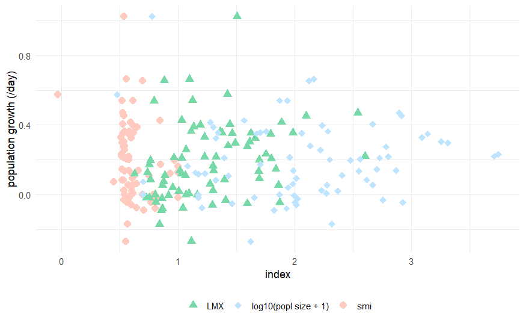

```r
ggplot(Bddiv_une_summary_aphid_apr_CAR1_forUne, aes(y = popl_growth_une_1)) +

  # smi: filled circle
  geom_point(aes(x = std_mi_une, shape = "smi"),
             size = 3, color = "#ffcabf") +

  # moran: triangle
  geom_point(aes(x = LMX_une, shape = "LMX"),
             size = 3, color = "#77d9a8") +

  # population size: diamond
  geom_point(aes(x = log10(popsize_une + 1), shape = "log10(popl size + 1)"),
             size = 3, color = "#bfe4ff") +

  scale_shape_manual(
    values = c(
      "smi" = 16,               # filled circle
      "LMX" = 17,     # filled triangle
      "log10(popl size + 1)" = 18  # filled diamond
    )
  ) +

  theme_minimal() +
  labs(
    x = "index",
    y = "population growth (/day)",
    linetype = NULL,
    shape = NULL
  ) +
  theme(
    legend.position = "bottom"
  )
```

##### Visualization 01

```r
best_popl_model <- gls(candidate_formulas$popl_growth_1$m_pop_mi_LMX,
                         data = Bddiv_une_summary_aphid_apr_CAR1_forUne,
                         correlation = corCAR1(form = ~ dayN | une_section),
                         method = "REML",
                         na.action = na.omit)

spatial_popl_model <- gls(candidate_formulas$popl_growth_1$m_mi_LMX,
                         data = Bddiv_une_summary_aphid_apr_CAR1_forUne,
                         correlation = corCAR1(form = ~ dayN | une_section),
                         method = "REML",
                         na.action = na.omit)

macro_popl_model <- gls(candidate_formulas$popl_growth_1$m_pop,
                         data = Bddiv_une_summary_aphid_apr_CAR1_forUne,
                         correlation = corCAR1(form = ~ dayN | une_section),
                         method = "REML",
                         na.action = na.omit)

pred_df <- data.frame(
  obs = Bddiv_une_summary_aphid_apr_CAR1_forUne$popl_growth_une_1,
  time = Bddiv_une_summary_aphid_apr_CAR1_forUne$dayN,
  pred_pop_mi_LMX = predict(best_popl_model, newdata = Bddiv_une_summary_aphid_apr_CAR1_forUne),
  pred_mi_LMX = predict(spatial_popl_model, newdata = Bddiv_une_summary_aphid_apr_CAR1_forUne),
  pred_pop = predict(macro_popl_model, newdata = Bddiv_une_summary_aphid_apr_CAR1_forUne)
)

pred_long <- rbind(
  data.frame(model = "best:pop_mi_LMX", pred = pred_df$pred_pop_mi_LMX, obs = pred_df$obs, time = pred_df$time, rep =  Bddiv_une_summary_aphid_apr_CAR1_forUne$une_section),
  data.frame(model = "micro only:mi_LMX", pred = pred_df$pred_mi_LMX, obs = pred_df$obs, time = pred_df$time,rep =  Bddiv_une_summary_aphid_apr_CAR1_forUne$une_section),
  data.frame(model = "macro only:pop", pred = pred_df$pred_pop, obs = pred_df$obs, time = pred_df$time, rep =  Bddiv_une_summary_aphid_apr_CAR1_forUne$une_section)
)
```

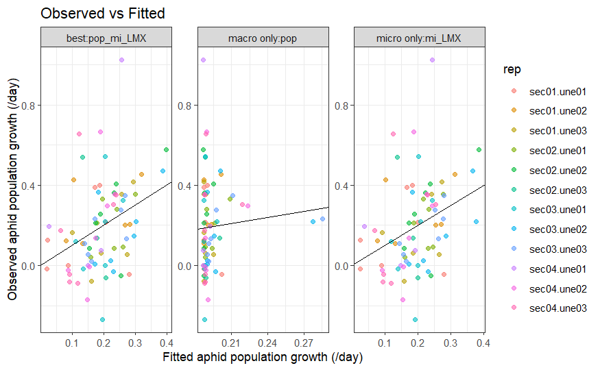

```r
p1_popl <- ggplot(pred_long, aes(x = pred, y = obs)) +
  geom_point(alpha = 0.6, aes(color = rep)) +
  geom_abline(slope = 1, intercept = 0) +
  facet_wrap(~ model, scales = "free") +
  labs(y = "Observed aphid population growth (/day)",
       x = "Fitted aphid population growth (/day)",
       title = "Observed vs Fitted") +
  theme_bw()
p1_popl
```

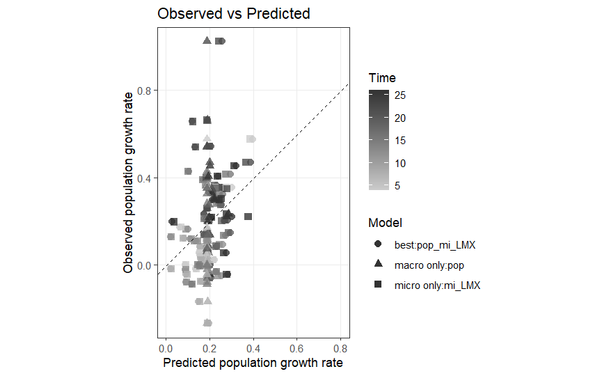

```r
ggplot(pred_long, aes(x = pred, y = obs,
                      shape = model,
                      color = time)) +
  geom_point(alpha = 0.8, size = 2.5) +
  geom_abline(slope = 1, intercept = 0,
              linetype = "dashed", color = "black") +
  xlim(c(0, 0.8)) +
  coord_equal() +
  scale_color_gradient(
    low = "grey80",   # darker for earlier time
    high = "grey20"   # brighter for later time
  ) +
  labs(
    x = "Predicted population growth rate",
    y = "Observed population growth rate",
    color = "Time",
    shape = "Model",
    title = "Observed vs Predicted"
  ) +
  theme_bw() +
  theme(
    legend.position = "right",
    panel.grid.minor = element_blank()
  )
```

##### Visualization 02

```r
b <- results_LORO$popl_growth_1$m_pop[, c("rep","n_test","RMSE")]
best <- results_LORO$popl_growth_1$m_pop_mi_LMX[, c("rep","n_test","RMSE")]
alt  <- results_LORO$popl_growth_1$m_mi_LMX[, c("rep","n_test","RMSE")]

names(b)[names(b)=="RMSE"] <- "RMSE_macro_only"
names(best)[names(best)=="RMSE"] <- "RMSE_best"
names(alt)[names(alt)=="RMSE"] <- "RMSE_spatial"

# merge the data
w <- merge(b, best[, c("rep","RMSE_best")], by = "rep", all = FALSE)
w <- merge(w, alt[,  c("rep","RMSE_spatial")],  by = "rep", all = FALSE)

w$delta_best <- w$RMSE_macro_only - w$RMSE_best
w$delta_spatial  <- w$RMSE_macro_only - w$RMSE_spatial

# converting long format
df_delta <- rbind(
  data.frame(rep = w$rep, n_test = w$n_test, delta_RMSE = w$delta_best, model = "Best"),
  data.frame(rep = w$rep, n_test = w$n_test, delta_RMSE = w$delta_spatial,  model = "Spatial")
)

# if ordering based on the improvement by the best model
#df_delta$rep <- factor(df_delta$rep, levels = w$rep[order(w$delta_best, decreasing = TRUE)])
```

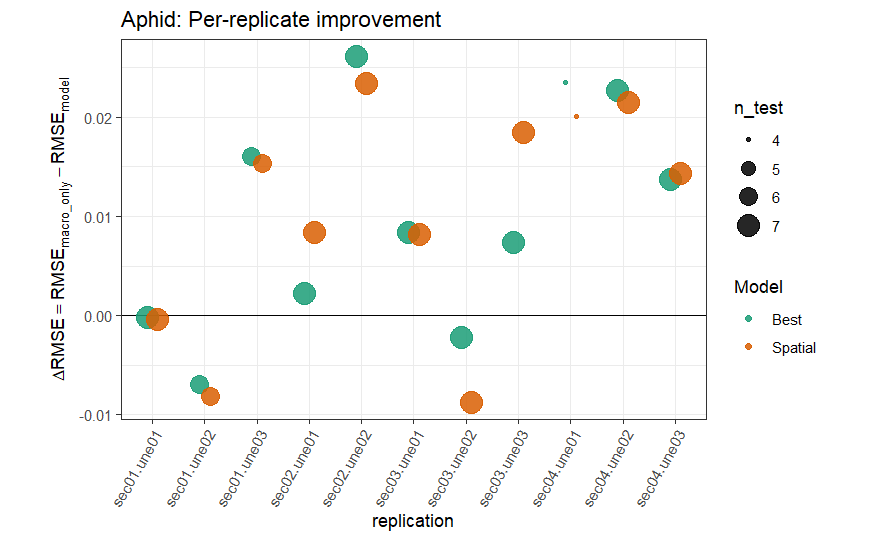

```r
p2_popl <- ggplot(df_delta, aes(x = rep, y = delta_RMSE, group = model)) +
  geom_hline(yintercept = 0) +
  geom_point(aes(size = n_test, color = model), alpha = 0.85, position = position_dodge(width = 0.4)) +
  scale_color_manual(values = c("Best" = "#1b9e77",
                                "Spatial" = "#d95f02"),
                     name = "Model") +
  labs(x = "replication",
       y = expression(Delta*RMSE == RMSE[macro_only] - RMSE[model]),
       size = "n_test",
       title = "Aphid: Per-replicate improvement") +
  theme_bw() +
  theme(axis.text.x = element_text(angle = 60, hjust = 1),
        aspect.ratio = 0.65)
p2_popl
```

##### Visualization 03

```r
selected_rep <- "sec04.une03"  #Choose by RMSE or improvement
Bddiv_une_summary_aphid_apr_forUne_compare <- subset(
  Bddiv_une_summary_aphid_apr,une_section == selected_rep
)
```

– Check the error size

```r
subset(results_LORO$popl_growth_1[["m_pop_mi_LMX"]], rep ==  selected_rep)
```

|  | rep | n_test | RMSE | MAE | SSE | SAE |
| --- | --- | --- | --- | --- | --- | --- |
| 11 | sec04.une03 | 7 | 0.2416281 | 0.1924401 | 0.4086889 | 1.347081 |

```r
subset(results_LORO$popl_growth_1[["m_mi_LMX"]], rep ==  selected_rep)
```

|  | rep | n_test | RMSE | MAE | SSE | SAE |
| --- | --- | --- | --- | --- | --- | --- |
| 11 | sec04.une03 | 7 | 0.2410565 | 0.1909406 | 0.4067576 | 1.336584 |

```r
subset(results_LORO$popl_growth_1[["m_pop"]], rep ==  selected_rep)
```

|  | rep | n_test | RMSE | MAE | SSE | SAE |
| --- | --- | --- | --- | --- | --- | --- |
| 11 | sec04.une03 | 7 | 0.2553784 | 0.2164945 | 0.4565268 | 1.515462 |

```r
popl_growth_pred_best <- fit_predict_loro_one_v2(df = Bddiv_une_summary_aphid_apr_CAR1_forUne,
                        test_rep = selected_rep,
                        form = candidate_formulas$popl_growth_1$m_pop_mi_LMX,
                        time_col = "dayN",
                        rep_col = "une_section",
                        response_col = "popl_growth_une_1",
                        min_test_n = 3
)

popl_growth_pred_micro <- fit_predict_loro_one_v2(df = Bddiv_une_summary_aphid_apr_CAR1_forUne,
                        test_rep = selected_rep,
                        form = candidate_formulas$popl_growth_1$m_mi_LMX,
                        time_col = "dayN",
                        rep_col = "une_section",
                        response_col = "popl_growth_une_1",
                        min_test_n = 3
)

popl_growth_pred_base <- fit_predict_loro_one_v2(df = Bddiv_une_summary_aphid_apr_CAR1_forUne,
                        test_rep = selected_rep,
                        form = candidate_formulas$popl_growth_1$m_pop,
                        time_col = "dayN",
                        rep_col = "une_section",
                        response_col = "popl_growth_une_1",
                        min_test_n = 3
)
```

```r
#starting point, identical to observation
Bddiv_une_summary_aphid_apr_forUne_compare$popl_pred_best[1] <- Bddiv_une_summary_aphid_apr_forUne_compare$popsize_une[1]

Bddiv_une_summary_aphid_apr_forUne_compare$popl_pred_micro[1] <- Bddiv_une_summary_aphid_apr_forUne_compare$popsize_une[1]

Bddiv_une_summary_aphid_apr_forUne_compare$popl_pred_base[1] <- Bddiv_une_summary_aphid_apr_forUne_compare$popsize_une[1]


for(j in 2:8) {
  # time period
  delta_t <- Bddiv_une_summary_aphid_apr_forUne_compare[j, "dayN"] - Bddiv_une_summary_aphid_apr_forUne_compare[j - 1, "dayN"]

 Bddiv_une_summary_aphid_apr_forUne_compare$popl_pred_best[j] <- Bddiv_une_summary_aphid_apr_forUne_compare[j - 1, "popsize_une"] * exp(popl_growth_pred_best[j - 1] * delta_t)

 Bddiv_une_summary_aphid_apr_forUne_compare$popl_pred_micro[j] <- Bddiv_une_summary_aphid_apr_forUne_compare[j - 1, "popsize_une"] * exp(popl_growth_pred_micro[j - 1] * delta_t)

 Bddiv_une_summary_aphid_apr_forUne_compare$popl_pred_base[j] <- Bddiv_une_summary_aphid_apr_forUne_compare[j - 1, "popsize_une"] * exp(popl_growth_pred_base[j - 1] * delta_t)



}
Bddiv_une_summary_aphid_apr_forUne_compare$popl_pred_best
```

```
[1]   50.00000   63.84164  142.54848  109.46031  103.64410   93.63114  211.01494 4471.32612
```

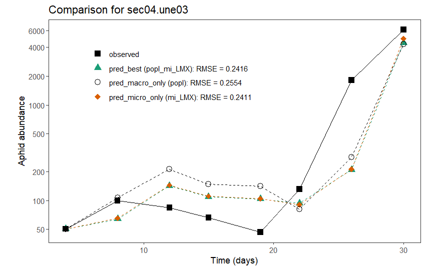

```r
ggplot(Bddiv_une_summary_aphid_apr_forUne_compare, aes(x = dayN)) +

  # pop_pred_best: dashed line + triangle
  geom_line(aes(y = popl_pred_best,
                linetype = "popl_pred_best"), color = "#1b9e77") +
  geom_point(aes(y = popl_pred_best,
                 shape = "pred_best (popl_mi_LMX): RMSE = 0.2416"),
             color = "#1b9e77",
             size = 3) +

  geom_line(aes(y = popl_pred_micro,
                linetype = "popl_pred_micro_only"), color = "#d95f02") +
  geom_point(aes(y = popl_pred_micro,
                 shape = "pred_micro_only (mi_LMX): RMSE = 0.2411"),
             color = "#d95f02",
             size = 3) +

  # pop_pred_base: dashed line + filled circle
  geom_line(aes(y = popl_pred_base,
                linetype = "popl_pred_macro_only"), color = "black") +
  geom_point(aes(y = popl_pred_base,
                 shape = "pred_macro_only (popl): RMSE = 0.2554"),
             color = "black",
             size = 3) +

  # av_pop: solid line + filled rectangle
  geom_line(aes(y = popsize_une, linetype = "observed"), color = "black") +
  geom_point(aes(y = popsize_une, shape = "observed"),
             color = "black",
             size = 3) +

  scale_linetype_manual(
    values = c(
      "observed" = "solid",
      "popl_pred_best" = "dashed",
      "popl_pred_micro_only" = "dashed",
      "popl_pred_macro_only" = "dashed"
    )
  ) +

  scale_shape_manual(
    values = c(
      "observed" = 15,               # filled rectangle (largest)
      "pred_best (popl_mi_LMX): RMSE = 0.2416" = 17,    # filled triangle
      "pred_micro_only (mi_LMX): RMSE = 0.2411" = 18,     # filled diamond
      "pred_macro_only (popl): RMSE = 0.2554" = 1     # open circle
    )
  ) +

  scale_x_continuous(
    name = "Time (days)",
  ) +

  scale_y_continuous(
    trans = "log1p",
    name = "Aphid abundance",
    breaks = c(50, 100, 200, 500, 1000, 2000, 4000, 6000)
  ) +

  labs(
    title = paste("Comparison for", selected_rep),
    shape = NULL
  ) +

  guides(
    linetype = "none"
  ) +

  theme_bw() +
  theme(
    panel.grid = element_blank(),
    aspect.ratio = 0.6,
    legend.position = c(0.1, 0.9),
    legend.justification = c(0, 1)
  )
```

#### [6.1.3] Prevalence growth rate 1

##### Analysis

– more systematically: model selection by LORO

```r
## =========================================================
## 2) DEFINE CANDIDATE MODELS (all subsets)
## =========================================================
# Model list as formulas; includes intercept-only baseline
candidate_formulas$prev_growth_1 <- list(
  m0 = as.formula("prev_growth_une_1 ~ 1"),
  m_pop = as.formula("prev_growth_une_1 ~ popsize_une"),
  m_prev = as.formula("prev_growth_une_1 ~ prevalence_une"),
  m_mi = as.formula("prev_growth_une_1 ~ std_mi_une"),
  m_LMX = as.formula("prev_growth_une_1 ~ LMX_une"),
  m_moran = as.formula("prev_growth_une_1 ~ moran_une"),
  m_pop_prev = as.formula("prev_growth_une_1 ~ popsize_une + prevalence_une"),
  m_pop_mi = as.formula("prev_growth_une_1 ~ popsize_une + std_mi_une"),
  m_pop_LMX = as.formula("prev_growth_une_1 ~ popsize_une + LMX_une"),
  m_prev_mi = as.formula("prev_growth_une_1 ~ prevalence_une + std_mi_une"),
  m_prev_LMX = as.formula("prev_growth_une_1 ~ prevalence_une + LMX_une"),
  m_mi_LMX = as.formula("prev_growth_une_1 ~ std_mi_une + LMX_une"),
  m_pop_moran = as.formula("prev_growth_une_1 ~ popsize_une + moran_une"),
  m_prev_moran = as.formula("prev_growth_une_1 ~ prevalence_une + moran_une"),
  m_mi_moran = as.formula("prev_growth_une_1 ~ std_mi_une + moran_une"),
  m_LMX_moran = as.formula("prev_growth_une_1 ~ LMX_une + moran_une"),
  m_pop_prev_mi = as.formula("prev_growth_une_1 ~ popsize_une + prevalence_une + std_mi_une"),
  m_pop_prev_LMX = as.formula("prev_growth_une_1 ~ popsize_une + prevalence_une + LMX_une"),
  m_pop_prev_moran = as.formula("prev_growth_une_1 ~ popsize_une + prevalence_une + moran_une"),
  m_pop_mi_LMX = as.formula("prev_growth_une_1 ~ popsize_une + std_mi_une + LMX_une"),
  m_pop_mi_moran = as.formula("prev_growth_une_1 ~ popsize_une + std_mi_une + moran_une"),
  m_pop_LMX_moran = as.formula("prev_growth_une_1 ~ popsize_une + LMX_une + moran_une"),
  m_prev_mi_LMX = as.formula("prev_growth_une_1 ~ prevalence_une + std_mi_une + LMX_une"),
  m_prev_mi_moran = as.formula("prev_growth_une_1 ~ prevalence_une + std_mi_une + moran_une"),
  m_prev_LMX_moran = as.formula("prev_growth_une_1 ~ prevalence_une + LMX_une + moran_une"),
  m_mi_LMX_moran = as.formula("prev_growth_une_1 ~ std_mi_une + LMX_une + moran_une"),
  m_pop_prev_mi_LMX = as.formula("prev_growth_une_1 ~ popsize_une + prevalence_une + std_mi_une + LMX_une"),
  m_pop_prev_mi_moran = as.formula("prev_growth_une_1 ~ popsize_une + prevalence_une + std_mi_une + moran_une"),
  m_pop_prev_LMX_moran = as.formula("prev_growth_une_1 ~ popsize_une + prevalence_une + LMX_une + moran_une"),
  m_pop_mi_LMX_moran = as.formula("prev_growth_une_1 ~ popsize_une + std_mi_une + LMX_une + moran_une"),
  m_prev_mi_LMX_moran = as.formula("prev_growth_une_1 ~ prevalence_une + std_mi_une + LMX_une +  moran_une"),
  m_all = as.formula("prev_growth_une_1 ~ popsize_une + prevalence_une + std_mi_une + LMX_une + moran_une")
)
```

```r
## =========================================================
## 4) RUN LORO FOR ALL MODELS: with min_test_n = 4, one rep excluded, fit on 10 reps, predict on held-out rep among total 11 reps
## =========================================================
results_LORO$prev_growth_1 <- lapply(candidate_formulas$prev_growth_1, function(fm) {
  loro_eval_model(df           = Bddiv_une_summary_aphid_apr_CAR1_forUne,
                  form         = fm,
                  time_col     = "dayN",
                  rep_col      = "une_section",
                  response_col = "prev_growth_une_1",
                  min_test_n   = 4)
})
```

```r
## =========================================================
## 5) AGGREGATE: macro (rep-average) + micro (all points)
## =========================================================
score_table$prev_growth_1 <- make_score_table(results_LORO$prev_growth_1)


# Rank (choose criterion; micro _RMSE is used
score_table$prev_growth_1 <- score_table$prev_growth_1[order(score_table$prev_growth_1$micro_RMSE), ]
print(score_table$prev_growth_1)
```

|  | model | n_rep_used | macro_RMSE | micro_RMSE | macro_MAE | micro_MAE | macro_RMSE_sd |
| --- | --- | --- | --- | --- | --- | --- | --- |
| 11 | m_prev_LMX | 11 | 0.1449377 | 0.1553580 | 0.1074021 | 0.1060426 | 0.06403172 |
| 18 | m_pop_prev_LMX | 11 | 0.1455276 | 0.1556810 | 0.1078397 | 0.1065547 | 0.06320470 |
| 25 | m_prev_LMX_moran | 11 | 0.1459331 | 0.1560527 | 0.1082452 | 0.1068784 | 0.06349554 |
| 7 | m_pop_prev | 11 | 0.1450337 | 0.1563288 | 0.1067917 | 0.1054762 | 0.06546522 |
| 3 | m_prev | 11 | 0.1444863 | 0.1564215 | 0.1050512 | 0.1036328 | 0.06721091 |
| 29 | m_pop_prev_LMX_moran | 11 | 0.1466550 | 0.1564907 | 0.1087928 | 0.1075019 | 0.06261573 |
| 14 | m_prev_moran | 11 | 0.1462939 | 0.1571204 | 0.1065406 | 0.1053164 | 0.06491482 |
| 19 | m_pop_prev_moran | 11 | 0.1468598 | 0.1572551 | 0.1076673 | 0.1065353 | 0.06361496 |
| 2 | m_pop | 11 | 0.1540855 | 0.1643580 | 0.1123809 | 0.1109721 | 0.06561083 |
| 9 | m_pop_LMX | 11 | 0.1548024 | 0.1648980 | 0.1136242 | 0.1122150 | 0.06551939 |

[output cut: 22 more lines]

```r
best_model_name$prev_growth_1 <- score_table$prev_growth_1$model[which.min(score_table$prev_growth_1$micro_RMSE)]
best_formula$prev_growth_1 <- candidate_formulas$prev_growth_1[[best_model_name$prev_growth_1]]
cat("\nBest by micro_RMSE:", best_model_name$prev_growth_1, "\n", deparse(best_formula$prev_growth_1), "\n")
```

```
Best by micro_RMSE: m_prev_LMX
 prev_growth_une_1 ~ prevalence_une + LMX_une
```

```r
## =========================================================
## 6) FINAL REFIT: refit the selected structure on ALL data by REML
##    and report coefficients + CI
## =========================================================
final_fit$prev_growth_1 <- gls(best_formula$prev_growth_1,
                 data = Bddiv_une_summary_aphid_apr_CAR1_forUne,
                 correlation = corCAR1(form = ~ dayN | une_section),
                 method = "REML",
                 na.action = na.omit)

cat("\nFinal model (REML) summary:\n")
```

```
Final model (REML) summary:
```

```r
print(summary(final_fit$prev_growth_1))
```

```
Generalized least squares fit by REML
  Model: best_formula$prev_growth_1
  Data: Bddiv_une_summary_aphid_apr_CAR1_forUne
```

|  | AIC | BIC | logLik |
| --- | --- | --- | --- |
|  | -45.90428 | -34.52095 | 27.95214 |

```
Correlation Structure: Continuous AR(1)
 Formula: ~dayN | une_section
 Parameter estimate(s):
         Phi
0.0009552187

Coefficients:
```

|  | Value | Std.Error | t-value | p-value |
| --- | --- | --- | --- | --- |
| (Intercept) | 0.09255250 | 0.05702766 | 1.622940 | 0.109 |
| prevalence_une | -0.23209651 | 0.07244467 | -3.203776 | 0.002 |
| LMX_une | 0.06384122 | 0.04924278 | 1.296459 | 0.199 |

```
 Correlation:
               (Intr) prvln_
prevalence_une  0.029
LMX_une        -0.835 -0.502

Standardized residuals:
       Min         Q1        Med         Q3        Max
-3.1154726 -0.3090628 -0.0184245  0.3758727  3.0936474

Residual standard error: 0.1548007
Degrees of freedom: 75 total; 72 residual
```

```r
cat("\nFixed effects (tTable):\n")
```

```
Fixed effects (tTable):
```

```r
print(summary(final_fit$prev_growth_1)$tTable)
```

```
                     Value  Std.Error   t-value    p-value
(Intercept)     0.09255250 0.05702766  1.622940 0.10897291
prevalence_une -0.23209651 0.07244467 -3.203776 0.00202167
LMX_une         0.06384122 0.04924278  1.296459 0.19895751
```

```r
## (Optional) Save the per-rep LORO tables for the best model
best_loro_table$prev_growth_1 <- results_LORO$prev_growth_1[[best_model_name$prev_growth_1]]
best_loro_table$prev_growth_1
```

| rep | n_test | RMSE | MAE | SSE | SAE |
| --- | --- | --- | --- | --- | --- |
| sec01.une01 | 7 | 0.23005513 | 0.16390449 | 0.37047754 | 1.1473315 |
| sec01.une02 | 6 | 0.13565856 | 0.08695437 | 0.11041947 | 0.5217262 |
| sec01.une03 | 6 | 0.29322249 | 0.22577510 | 0.51587658 | 1.3546506 |
| sec02.une01 | 7 | 0.07741699 | 0.06719536 | 0.04195374 | 0.4703675 |
| sec02.une02 | 7 | 0.10236448 | 0.08080924 | 0.07334940 | 0.5656647 |
| sec03.une01 | 7 | 0.11531084 | 0.07630064 | 0.09307614 | 0.5341045 |
| sec03.une02 | 7 | 0.10283715 | 0.07910199 | 0.07402836 | 0.5537139 |
| sec03.une03 | 7 | 0.10155227 | 0.06876248 | 0.07219004 | 0.4813374 |
| sec04.une01 | 4 | 0.14417082 | 0.10738824 | 0.08314090 | 0.4295529 |
| sec04.une02 | 7 | 0.12618028 | 0.10599486 | 0.11145024 | 0.7419640 |

[output cut: 1 more lines]

– alternative model

```r
alternative_model <- gls(candidate_formulas$prev_growth_1$m_pop_prev,
                         data = Bddiv_une_summary_aphid_apr_CAR1_forUne,
                         correlation = corCAR1(form = ~ dayN | une_section),
                         method = "REML",
                         na.action = na.omit)

cat("\nFinal alternative model (REML) summary:\n")
```

```
Final alternative model (REML) summary:
```

```r
print(summary(alternative_model))
```

```
Generalized least squares fit by REML
  Model: candidate_formulas$prev_growth_1$m_pop_prev
  Data: Bddiv_une_summary_aphid_apr_CAR1_forUne
```

|  | AIC | BIC | logLik |
| --- | --- | --- | --- |
|  | -29.51436 | -18.13103 | 19.75718 |

```
Correlation Structure: Continuous AR(1)
 Formula: ~dayN | une_section
 Parameter estimate(s):
        Phi
0.001184138

Coefficients:
```

|  | Value | Std.Error | t-value | p-value |
| --- | --- | --- | --- | --- |
| (Intercept) | 0.16094046 | 0.03299076 | 4.878349 | 0.0000 |
| popsize_une | 0.00001724 | 0.00002465 | 0.699329 | 0.4866 |
| prevalence_une | -0.21784430 | 0.07876462 | -2.765763 | 0.0072 |

```
 Correlation:
               (Intr) ppsz_n
popsize_une     0.287
prevalence_une -0.803 -0.597

Standardized residuals:
        Min          Q1         Med          Q3         Max
-3.11395167 -0.29837956  0.06852649  0.33266743  3.15857682

Residual standard error: 0.156068
Degrees of freedom: 75 total; 72 residual
```

```r
cat("\nFixed effects (tTable):\n")
```

```
Fixed effects (tTable):
```

```r
print(summary(alternative_model$tTable))
```

```
Length  Class   Mode
     0   NULL   NULL
```

##### Visualization 01

```r
best_prev_model <- gls(candidate_formulas$prev_growth_1$m_prev_LMX,
                         data = Bddiv_une_summary_aphid_apr_CAR1_forUne,
                         correlation = corCAR1(form = ~ dayN | une_section),
                         method = "REML",
                         na.action = na.omit)

spatial_prev_model <- gls(candidate_formulas$prev_growth_1$m_LMX, # best spatial
                         data = Bddiv_une_summary_aphid_apr_CAR1_forUne,
                         correlation = corCAR1(form = ~ dayN | une_section),
                         method = "REML",
                         na.action = na.omit)

macro_prev_model <- gls(candidate_formulas$prev_growth_1$m_pop_prev,
                         data = Bddiv_une_summary_aphid_apr_CAR1_forUne,
                         correlation = corCAR1(form = ~ dayN | une_section),
                         method = "REML",
                         na.action = na.omit)

pred_df <- data.frame(
  obs = Bddiv_une_summary_aphid_apr_CAR1_forUne$prev_growth_une_1,
  pred_prev_LMX = predict(best_prev_model, newdata = Bddiv_une_summary_aphid_apr_CAR1_forUne),
  pred_mi_LMX = predict(spatial_prev_model, newdata = Bddiv_une_summary_aphid_apr_CAR1_forUne),
  pred_pop_prev = predict(macro_prev_model, newdata = Bddiv_une_summary_aphid_apr_CAR1_forUne)
)

pred_long <- rbind(
  data.frame(model = "best:prev_LMX", pred = pred_df$pred_prev_LMX, obs = pred_df$obs, rep =  Bddiv_une_summary_aphid_apr_CAR1_forUne$une_section),
  data.frame(model = "micro only:LMX", pred = pred_df$pred_mi_LMX, obs = pred_df$obs, rep = Bddiv_une_summary_aphid_apr_CAR1_forUne$une_section),
  data.frame(model = "macro only:pop_prev", pred = pred_df$pred_pop_prev, obs = pred_df$obs, rep = Bddiv_une_summary_aphid_apr_CAR1_forUne$une_section)
)
```

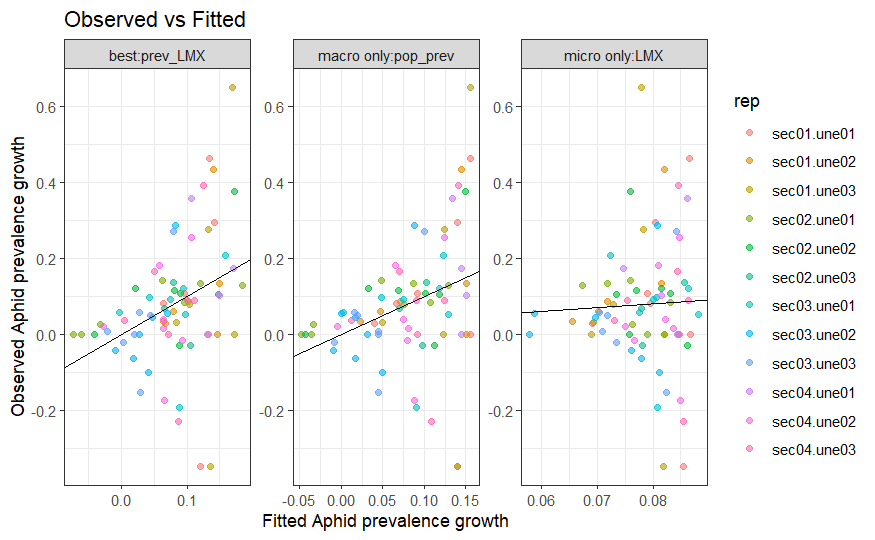

```r
p1_prev <- ggplot(pred_long, aes(x = pred, y = obs)) +
  geom_point(alpha = 0.6, aes(color = rep)) +
  geom_abline(slope = 1, intercept = 0) +
  facet_wrap(~ model, scales = "free") +
  labs(y = "Observed Aphid prevalence growth",
       x = "Fitted Aphid prevalence growth",
       title = "Observed vs Fitted") +
  theme_bw()
p1_prev
```

##### Visualization 02

```r
b <- results_LORO$prev_growth_1$m_pop_prev[, c("rep","n_test","RMSE")]
best <- results_LORO$prev_growth_1$m_prev_LMX[, c("rep","n_test","RMSE")]
alt  <- results_LORO$prev_growth_1$m_LMX[, c("rep","n_test","RMSE")]

names(b)[names(b)=="RMSE"] <- "RMSE_macro_only"
names(best)[names(best)=="RMSE"] <- "RMSE_best"
names(alt)[names(alt)=="RMSE"] <- "RMSE_spatial"

# merge the data
w <- merge(b, best[, c("rep","RMSE_best")], by = "rep", all = FALSE)
w <- merge(w, alt[,  c("rep","RMSE_spatial")],  by = "rep", all = FALSE)

w$delta_best <- w$RMSE_macro_only - w$RMSE_best
w$delta_spatial  <- w$RMSE_macro_only - w$RMSE_spatial

# converting long format
df_delta <- rbind(
  data.frame(rep = w$rep, n_test = w$n_test, delta_RMSE = w$delta_best, model = "Best"),
  data.frame(rep = w$rep, n_test = w$n_test, delta_RMSE = w$delta_spatial,  model = "Spatial")
)

# if ordering based on the improvement by the best model
#df_delta$rep <- factor(df_delta$rep, levels = w$rep[order(w$delta_best, decreasing = TRUE)])
```

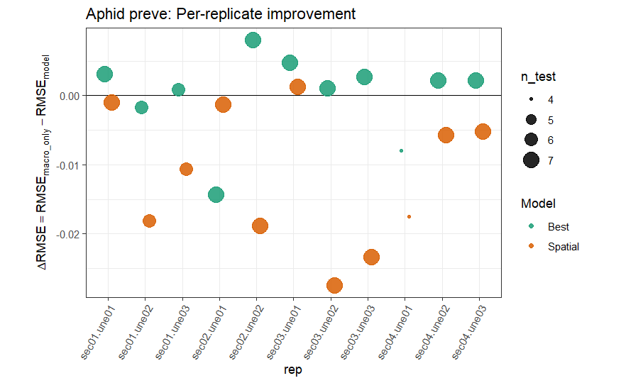

```r
p2_prev <- ggplot(df_delta, aes(x = rep, y = delta_RMSE, group = model)) +
  geom_hline(yintercept = 0) +
  geom_point(aes(size = n_test, color = model), alpha = 0.85, position = position_dodge(width = 0.4)) +
  scale_color_manual(values = c("Best" = "#1b9e77",
                                "Spatial" = "#d95f02"),
                     name = "Model") +
  labs(x = "rep", y = expression(Delta*RMSE == RMSE[macro_only] - RMSE[model]),
       size = "n_test",
       title = "Aphid preve: Per-replicate improvement") +
  theme_bw() +
  theme(axis.text.x = element_text(angle = 60, hjust = 1),
        aspect.ratio = 0.65
        )
p2_prev
```

##### Visualization 03

```r
selected_rep <- "une02.sec04"  #Choose by RMSE or improvement
Bddiv_une_summary_aphid_apr_forUne_compare <- subset(
  Bddiv_une_summary_aphid_apr,une_section == selected_rep
)
```

– Check the error size

```r
subset(results_LORO$popl_growth_1[["m_prev_LMX"]], rep ==  selected_rep)
```

[output not shown]

```r
subset(results_LORO$popl_growth_1[["m_LMX"]], rep ==  selected_rep)
```

[output not shown]

```r
subset(results_LORO$popl_growth_1[["m_prev"]], rep ==  selected_rep)
```

[output not shown]

```r
prev_growth_pred_best <- fit_predict_loro_one_v2(df = Bddiv_une_summary_aphid_apr_CAR1_forUne,
                        test_rep = selected_rep,
                        form = candidate_formulas$prev_growth_1$m_prev_LMX,
                        time_col = "dayN",
                        rep_col = "une_section",
                        response_col = "prev_growth_une_1",
                        min_test_n = 3
)

prev_growth_pred_micro <- fit_predict_loro_one_v2(df = Bddiv_une_summary_aphid_apr_CAR1_forUne,
                        test_rep = selected_rep,
                        form = candidate_formulas$prev_growth_1$m_LMX,
                        time_col = "dayN",
                        rep_col = "une_section",
                        response_col = "prev_growth_une_1",
                        min_test_n = 3
)

prev_growth_pred_base <- fit_predict_loro_one_v2(df = Bddiv_une_summary_aphid_apr_CAR1_forUne,
                        test_rep = selected_rep,
                        form = candidate_formulas$prev_growth_1$m_prev,
                        time_col = "dayN",
                        rep_col = "une_section",
                        response_col = "prev_growth_une_1",
                        min_test_n = 3
)
```

```r
#starting point, identical to observation
Bddiv_une_summary_aphid_apr_forUne_compare$prev_pred_best[1] <- Bddiv_une_summary_aphid_apr_forUne_compare$prevalence_une[1]

Bddiv_une_summary_aphid_apr_forUne_compare$prev_pred_micro[1] <- Bddiv_une_summary_aphid_apr_forUne_compare$prevalence_une[1]

Bddiv_une_summary_aphid_apr_forUne_compare$prev_pred_base[1] <- Bddiv_une_summary_aphid_apr_forUne_compare$prevalence_une[1]


for(j in 2:8) {
  # time period
  delta_t <- Bddiv_une_summary_aphid_apr_forUne_compare[j, "dayN"] - Bddiv_une_summary_aphid_apr_forUne_compare[j - 1, "dayN"]

 Bddiv_une_summary_aphid_apr_forUne_compare$prev_pred_best[j] <- Bddiv_une_summary_aphid_apr_forUne_compare[j - 1, "prevalence_une"] * exp(prev_growth_pred_best[j - 1] * delta_t)

 Bddiv_une_summary_aphid_apr_forUne_compare$prev_pred_micro[j] <- Bddiv_une_summary_aphid_apr_forUne_compare[j - 1, "prevalence_une"] * exp(prev_growth_pred_micro[j - 1] * delta_t)

 Bddiv_une_summary_aphid_apr_forUne_compare$prev_pred_base[j] <- Bddiv_une_summary_aphid_apr_forUne_compare[j - 1, "prevalence_une"] * exp(prev_growth_pred_base[j - 1] * delta_t)

}
Bddiv_une_summary_aphid_apr_forUne_compare$prev_pred_best
```

[output not shown]

[figure not shown]

```r
ggplot(Bddiv_une_summary_aphid_apr_forUne_compare, aes(x = dayN)) +

  # pop_pred_best: dashed line + triangle
  geom_line(aes(y = prev_pred_best,
                linetype = "prev_pred_best"), color = "#1b9e77") +
  geom_point(aes(y = prev_pred_best,
                 shape = "prev_pred_best: RMSE = 0.2479"),
             color = "#1b9e77",
             size = 3) +

  geom_line(aes(y = prev_pred_micro,
                linetype = "prev_pred_micro_only"), color = "#d95f02") +
  geom_point(aes(y = prev_pred_micro,
                 shape = "prev_pred_micro_only: RMSE = 0.2444"),
             color = "#d95f02",
             size = 3) +

  # pop_pred_base: dashed line + filled circle
  geom_line(aes(y = prev_pred_base,
                linetype = "prev_pred_macro_only"), color = "black") +
  geom_point(aes(y = prev_pred_base,
                 shape = "prev_pred_macro_only: RMSE = 0.2510"),
             color = "black",
             size = 3) +

  # av_pop: solid line + filled rectangle
  geom_line(aes(y = prevalence_une, linetype = "observed"), color = "black") +
  geom_point(aes(y = prevalence_une, shape = "observed"),
             color = "black",
             size = 3) +

  scale_linetype_manual(
    values = c(
      "observed" = "solid",
      "prev_pred_best" = "dashed",
      "prev_pred_micro_only" = "dashed",
      "prev_pred_macro_only" = "dashed"
    )
  ) +

  scale_shape_manual(
    values = c(
      "observed" = 15,               # filled rectangle (largest)
      "prev_pred_best: RMSE = 0.2479" = 17,    # filled triangle
      "prev_pred_micro_only: RMSE = 0.2444" = 18,     # filled diamond
      "prev_pred_macro_only: RMSE = 0.2510" = 1     # open circle
    )
  ) +

  scale_x_continuous(
    name = "Time (days)",
  ) +

  scale_y_continuous(
    trans = "log1p",
    name = "Aphid prevalence"
  ) +

  labs(
    title = paste("Comparison for", selected_rep),
    shape = "observation vs model"
  ) +

  guides(
    linetype = "none"
  ) +

  theme_bw() +
  theme(
    panel.grid = element_blank(),
    aspect.ratio = 0.6,
    legend.position = c(0.1, 0.9),
    legend.justification = c(0, 1)
  )
```

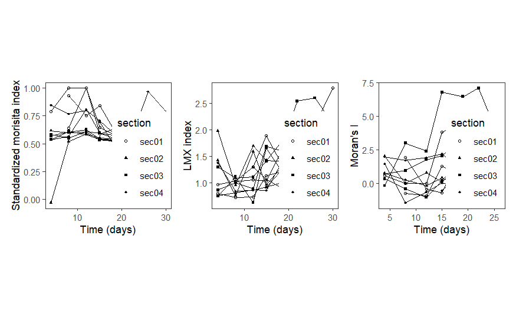

```r
p1 <- ggplot(summary_aphid_apr_une, aes(x = dayN, y = std_mi_une, group = une_section, shape = section)) +
  geom_line(linewidth = 0.2) +
  geom_point(size = 1) +
  scale_shape_manual(values = c(1, 17, 15, 18)) +
  #scale_y_log10() +
  labs(
    x = "Time (days)",
    y = "Standardized morisita index"
  ) +
theme_bw() +
  theme(
    panel.grid = element_blank(),
    aspect.ratio = 1.0,
    legend.position = c(0.98, 0.02),
    legend.justification = c(1, 0)
    )
p2 <- ggplot(summary_aphid_apr_une, aes(x = dayN, y = LMX_une, group = une_section, shape = section)) +
  geom_line(linewidth = 0.2) +
  geom_point(size = 1) +
  scale_shape_manual(values = c(1, 17, 15, 18)) +
  #scale_y_log10() +
  labs(
    x = "Time (days)",
    y = "LMX index"
  ) +
theme_bw() +
  theme(
    panel.grid = element_blank(),
    aspect.ratio = 1.0,
    legend.position = c(0.98, 0.02),
    legend.justification = c(1, 0)
    )
p3 <- ggplot(Bddiv_une_summary_aphid_apr_CAR1_forUne, aes(x = dayN, y = moran_une, group = une_section, shape = section)) +
  geom_line(linewidth = 0.2) +
  geom_point(size = 1) +
  scale_shape_manual(values = c(1, 17, 15, 18)) +
  #scale_y_log10() +
  labs(
    x = "Time (days)",
    y = "Moran's I"
  ) +
theme_bw() +
  theme(
    panel.grid = element_blank(),
    aspect.ratio = 1.0,
    legend.position = c(0.98, 0.02),
    legend.justification = c(1, 0)
    )
p1 + p2 + p3
```

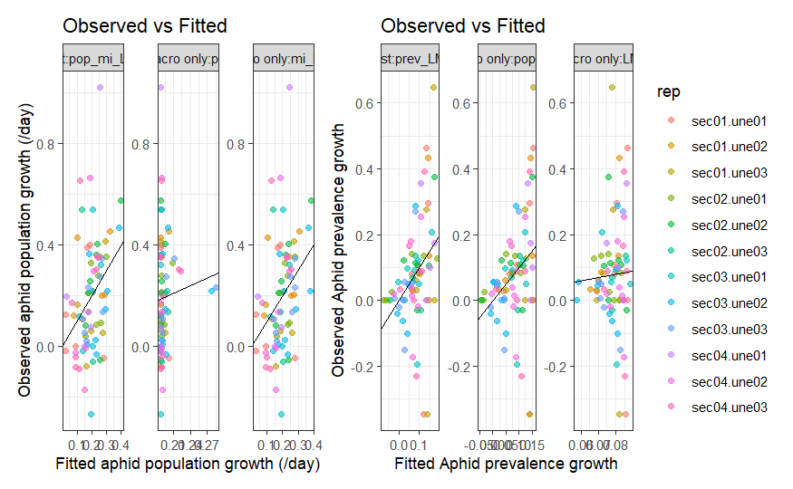

```r
p1_popl + theme(legend.position = "none") + p1_prev
```

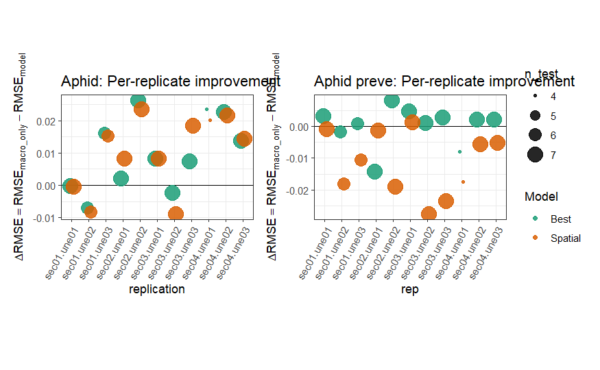

```r
p2_popl + theme(legend.position = "none") + p2_prev
```

### [6.2] Une-level future state, regressed by B’-level present state and spatial indices

#### Spatial distribution by B’-division (for the manuscript)

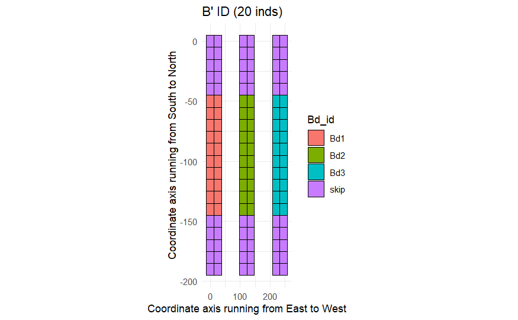

```r
ggplot(spatial_info, aes(x = x_axis, y = y_axis, fill = Bd_id)) +
  geom_tile(color = "black", linewidth = 0.5) +
  labs(title = "B' ID (20 inds)",
       x = "Coordinate axis running from East to West",
       y = "Coordinate axis running from South to North") +
  coord_fixed(ratio = 4.0) +  # setting aspect ratio
  theme_minimal()
```

– If the data before [6.1] is used

```r
#load("aphid_analysis2024April_v4_20260220.RData")
```

– Check the merged data

```r
print(Bddiv_une_summary_aphid_apr)
```

|  | dayID | une | section | une_section | dayN | popsize_une | prevalence_une | std_mi_une | popl_growth_une_0 | popl_growth_une_1 | popl_growth_une_2 | prev_growth_une_0 | prev_growth_une_1 | prev_growth_une_2 | Ia_une | Perry_une | LMX_une | Bd_id | popsize_Bd | prevalence_Bd | std_mi_Bd | LMX_I_Bd | moran_une | moran_Bd |
| --- | --- | --- | --- | --- | --- | --- | --- | --- | --- | --- | --- | --- | --- | --- | --- | --- | --- | --- | --- | --- | --- | --- | --- | --- |
| s01.une01.sec01 | s01 | une01 | sec01 | sec01.une01 | 4 | 14 | 0.100 | 0.78917530 | NA | 0.000000000 | -0.018526993 | NA | -0.346573590 | 0.000000000 | 0.8130075 | 0.7749815 | 0.8003841 | Bd1 | 12 | 0.10 | 0.9060541 | 0.8521336 | 5.869581e-01 | 1.030072e+00 |
| s02.une01.sec01 | s02 | une01 | sec01 | sec01.une01 | 8 | 14 | 0.025 | 1.00000000 | 0.000000000 | -0.018526993 | 0.126496541 | -0.346573590 | 0.000000000 | 0.462098120 | 0.8007015 | 0.7624444 | 0.7255453 | Bd1 | 14 | 0.05 | 1.0000000 | 0.7812503 | 1.298643e-15 | 8.947336e-16 |
| s03.une01.sec01 | s03 | une01 | sec01 | sec01.une01 | 12 | 13 | 0.025 | 1.00000000 | -0.018526993 | 0.126496541 | 0.388842673 | 0.000000000 | 0.462098120 | 0.294663749 | 0.7793757 | 0.7420616 | 0.7367024 | Bd1 | 13 | 0.05 | 1.0000000 | 0.7972961 | 1.298643e-15 | 2.684201e-15 |
| s04.une01.sec01 | s04 | une01 | sec01 | sec01.une01 | 15 | 19 | 0.100 | 0.64854730 | 0.126496541 | 0.388842673 | 0.215894935 | 0.462098120 | 0.294663749 | 0.108474133 | 1.2444590 | 1.1420846 | 1.1317667 | Bd1 | 19 | 0.20 | 0.6343110 | 1.0103692 | 3.832913e+00 | 2.243048e+00 |
| s05.une01.sec01 | s05 | une01 | sec01 | sec01.une01 | 19 | 90 | 0.325 | 0.56622671 | 0.388842673 | 0.215894935 | 0.399141177 | 0.294663749 | 0.108474133 | 0.082126017 | 1.1433156 | 1.1982143 | 1.2245302 | Bd1 | 80 | 0.50 | 0.5730081 | 1.0544121 | 4.493527e+00 | 2.553003e+00 |
| s06.une01.sec01 | s06 | une01 | sec01 | sec01.une01 | 22 | 172 | 0.450 | 0.61107883 | 0.215894935 | 0.399141177 | -0.044698554 | 0.108474133 | 0.082126017 | 0.028332171 | 1.2665228 | 1.0866857 | 1.1879449 | Bd1 | 153 | 0.55 | 0.6324230 | 1.0779792 | 1.404378e+00 | 1.350223e-01 |
| s07.une01.sec01 | s07 | une01 | sec01 | sec01.une01 | 26 | 849 | 0.625 | 0.55978312 | 0.399141177 | -0.044698554 | NA | 0.082126017 | 0.028332171 | NA | 2.2029741 | 1.8608263 | 1.8704299 | Bd1 | 767 | 0.80 | 0.5632396 | 1.6522964 | 2.318034e+00 | 1.644660e+00 |
| s08.une01.sec01 | s08 | une01 | sec01 | sec01.une01 | 30 | 710 | 0.700 | 0.55017257 | -0.044698554 | NA | NA | 0.028332171 | NA | NA | 1.7594752 | 1.5169743 | 1.6175517 | Bd1 | 595 | 0.90 | 0.5582896 | 1.9400994 | 4.542967e+00 | 3.977754e+00 |
| s01.une02.sec01 | s01 | une02 | sec01 | sec01.une02 | 4 | 0 | 0.000 | NaN | NA | NA | 0.121376954 | NA | NA | 0.000000000 | NA | NA | NA | Bd2 | 0 | 0.00 | NaN | NA | NA | NA |
| s02.une02.sec01 | s02 | une02 | sec01 | sec01.une02 | 8 | 16 | 0.050 | 0.93373153 | NA | 0.121376954 | 0.108474133 | NA | 0.000000000 | 0.135155036 | 0.9655316 | 1.0499891 | 1.0276260 | Bd2 | 0 | 0.00 | NaN | NA | 1.931748e+00 | NA |

[output cut: 86 more lines]

– model selection by LORO

```r
## =========================================================
## 1) Data prearrangement
## =========================================================
Bddiv_une_summary_aphid_apr_1 <- subset(Bddiv_une_summary_aphid_apr, !is.na(popl_growth_une_1) & !is.na(prev_growth_une_1) & !is.na(std_mi_Bd) & !is.na(LMX_I_Bd))
Bddiv_une_summary_aphid_apr_1
```

|  | dayID | une | section | une_section | dayN | popsize_une | prevalence_une | std_mi_une | popl_growth_une_0 | popl_growth_une_1 | popl_growth_une_2 | prev_growth_une_0 | prev_growth_une_1 | prev_growth_une_2 | Ia_une | Perry_une | LMX_une | Bd_id | popsize_Bd | prevalence_Bd | std_mi_Bd | LMX_I_Bd | moran_une | moran_Bd |
| --- | --- | --- | --- | --- | --- | --- | --- | --- | --- | --- | --- | --- | --- | --- | --- | --- | --- | --- | --- | --- | --- | --- | --- | --- |
| s01.une01.sec01 | s01 | une01 | sec01 | sec01.une01 | 4 | 14 | 0.100 | 0.7891753 | NA | 0.000000000 | -0.018526993 | NA | -0.346573590 | 0.000000000 | 0.8130075 | 0.7749815 | 0.8003841 | Bd1 | 12 | 0.10 | 0.9060541 | 0.8521336 | 5.869581e-01 | 1.030072e+00 |
| s02.une01.sec01 | s02 | une01 | sec01 | sec01.une01 | 8 | 14 | 0.025 | 1.0000000 | 0.000000000 | -0.018526993 | 0.126496541 | -0.34657359 | 0.000000000 | 0.462098120 | 0.8007015 | 0.7624444 | 0.7255453 | Bd1 | 14 | 0.05 | 1.0000000 | 0.7812503 | 1.298643e-15 | 8.947336e-16 |
| s03.une01.sec01 | s03 | une01 | sec01 | sec01.une01 | 12 | 13 | 0.025 | 1.0000000 | -0.018526993 | 0.126496541 | 0.388842673 | 0.00000000 | 0.462098120 | 0.294663749 | 0.7793757 | 0.7420616 | 0.7367024 | Bd1 | 13 | 0.05 | 1.0000000 | 0.7972961 | 1.298643e-15 | 2.684201e-15 |
| s04.une01.sec01 | s04 | une01 | sec01 | sec01.une01 | 15 | 19 | 0.100 | 0.6485473 | 0.126496541 | 0.388842673 | 0.215894935 | 0.46209812 | 0.294663749 | 0.108474133 | 1.2444590 | 1.1420846 | 1.1317667 | Bd1 | 19 | 0.20 | 0.6343110 | 1.0103692 | 3.832913e+00 | 2.243048e+00 |
| s05.une01.sec01 | s05 | une01 | sec01 | sec01.une01 | 19 | 90 | 0.325 | 0.5662267 | 0.388842673 | 0.215894935 | 0.399141177 | 0.29466375 | 0.108474133 | 0.082126017 | 1.1433156 | 1.1982143 | 1.2245302 | Bd1 | 80 | 0.50 | 0.5730081 | 1.0544121 | 4.493527e+00 | 2.553003e+00 |
| s06.une01.sec01 | s06 | une01 | sec01 | sec01.une01 | 22 | 172 | 0.450 | 0.6110788 | 0.215894935 | 0.399141177 | -0.044698554 | 0.10847413 | 0.082126017 | 0.028332171 | 1.2665228 | 1.0866857 | 1.1879449 | Bd1 | 153 | 0.55 | 0.6324230 | 1.0779792 | 1.404378e+00 | 1.350223e-01 |
| s07.une01.sec01 | s07 | une01 | sec01 | sec01.une01 | 26 | 849 | 0.625 | 0.5597831 | 0.399141177 | -0.044698554 | NA | 0.08212602 | 0.028332171 | NA | 2.2029741 | 1.8608263 | 1.8704299 | Bd1 | 767 | 0.80 | 0.5632396 | 1.6522964 | 2.318034e+00 | 1.644660e+00 |
| s03.une02.sec01 | s03 | une02 | sec01 | sec01.une02 | 12 | 26 | 0.050 | 0.7537509 | 0.121376954 | 0.108474133 | 0.427446472 | 0.00000000 | 0.135155036 | 0.433650264 | 1.1948112 | 1.0729287 | 1.0611292 | Bd2 | 26 | 0.10 | 0.7447839 | 1.3839719 | -4.457470e-01 | -5.006868e-01 |
| s04.une02.sec01 | s04 | une02 | sec01 | sec01.une02 | 15 | 36 | 0.075 | 0.8439683 | 0.108474133 | 0.427446472 | 0.200366003 | 0.13515504 | 0.433650264 | 0.085943036 | 0.9680234 | 1.0220309 | 1.0301646 | Bd2 | 3 | 0.05 | 1.0000000 | 0.8035008 | -6.915675e-01 | -8.947336e-16 |
| s05.une02.sec01 | s05 | une02 | sec01 | sec01.une02 | 19 | 199 | 0.425 | 0.5754639 | 0.427446472 | 0.200366003 | 0.205547985 | 0.43365026 | 0.085943036 | 0.060290514 | 1.8972805 | 1.5292516 | 1.6953500 | Bd2 | 132 | 0.50 | 0.6315494 | 1.2711138 | 2.506602e+00 | 6.541850e-01 |

[output cut: 59 more lines]

#### [6.2.1] Trial

```r
# exponential growth + unequal time interval
m_test <- gls(popl_growth_une_1 ~ std_mi_Bd,
          data = Bddiv_une_summary_aphid_apr_1,
          correlation = corCAR1(form = ~ dayN | une_section),
          method = "REML")
summary(m_test)
```

```
Generalized least squares fit by REML
  Model: popl_growth_une_1 ~ std_mi_Bd
  Data: Bddiv_une_summary_aphid_apr_1
```

|  | AIC | BIC | logLik |
| --- | --- | --- | --- |
|  | -18.82757 | -10.0088 | 13.41378 |

```
Correlation Structure: Continuous AR(1)
 Formula: ~dayN | une_section
 Parameter estimate(s):
        Phi
0.001244877

Coefficients:
```

|  | Value | Std.Error | t-value | p-value |
| --- | --- | --- | --- | --- |
| (Intercept) | 0.4469668 | 0.1145248 | 3.902795 | 0.0002 |
| std_mi_Bd | -0.4010725 | 0.1698621 | -2.361166 | 0.0211 |

```
 Correlation:
          (Intr)
std_mi_Bd -0.98

Standardized residuals:
        Min          Q1         Med          Q3         Max
-2.42941053 -0.82186267 -0.04922592  0.62843886  2.60948229

Residual standard error: 0.1915634
Degrees of freedom: 69 total; 67 residual
```

```r
summary(m_test)$tTable
```

```
                 Value Std.Error   t-value      p-value
(Intercept)  0.4469668 0.1145248  3.902795 0.0002232377
std_mi_Bd   -0.4010725 0.1698621 -2.361166 0.0211339143
```

#### [6.2.2] Population growth rate 1

```r
## =========================================================
## 2) DEFINE CANDIDATE MODELS (all subsets)
## =========================================================
# Model list as formulas; includes intercept-only baseline
# Note that macro parameters are also used for Bd unit
candidate_formulas$popl_growth_1_Bd <- list(
  m0 = as.formula("popl_growth_une_1 ~ 1"),
  m_pop = as.formula("popl_growth_une_1 ~ popsize_Bd"),
  m_prev = as.formula("popl_growth_une_1 ~ prevalence_Bd"),
  m_mi = as.formula("popl_growth_une_1 ~ std_mi_Bd"),
  m_LMX = as.formula("popl_growth_une_1 ~ LMX_I_Bd"),
  m_moran = as.formula("popl_growth_une_1 ~ moran_Bd"),
  m_pop_prev = as.formula("popl_growth_une_1 ~ popsize_Bd + prevalence_Bd"),
  m_pop_mi = as.formula("popl_growth_une_1 ~ popsize_Bd + std_mi_Bd"),
  m_pop_LMX = as.formula("popl_growth_une_1 ~ popsize_Bd + LMX_I_Bd"),
  m_prev_mi = as.formula("popl_growth_une_1 ~ prevalence_Bd + std_mi_Bd"),
  m_prev_LMX = as.formula("popl_growth_une_1 ~ prevalence_Bd + LMX_I_Bd"),
  m_mi_LMX = as.formula("popl_growth_une_1 ~ std_mi_Bd + LMX_I_Bd"),
  m_pop_moran = as.formula("popl_growth_une_1 ~ popsize_Bd + moran_Bd"),
  m_prev_moran = as.formula("popl_growth_une_1 ~ prevalence_Bd + moran_Bd"),
  m_mi_moran = as.formula("popl_growth_une_1 ~ std_mi_Bd + moran_Bd"),
  m_LMX_moran = as.formula("popl_growth_une_1 ~ LMX_I_Bd + moran_Bd"),
  m_pop_prev_mi = as.formula("popl_growth_une_1 ~ popsize_Bd + prevalence_Bd + std_mi_Bd"),
  m_pop_prev_LMX = as.formula("popl_growth_une_1 ~ popsize_Bd + prevalence_Bd + LMX_I_Bd"),
  m_pop_prev_moran = as.formula("popl_growth_une_1 ~ popsize_Bd + prevalence_Bd + moran_Bd"),
  m_pop_mi_LMX = as.formula("popl_growth_une_1 ~ popsize_Bd + std_mi_Bd + LMX_I_Bd"),
  m_pop_mi_moran = as.formula("popl_growth_une_1 ~ popsize_Bd + std_mi_Bd + moran_Bd"),
  m_pop_LMX_moran = as.formula("popl_growth_une_1 ~ popsize_Bd + LMX_I_Bd + moran_Bd"),
  m_prev_mi_LMX = as.formula("popl_growth_une_1 ~ prevalence_Bd + std_mi_Bd + LMX_I_Bd"),
  m_prev_mi_moran = as.formula("popl_growth_une_1 ~ prevalence_Bd + std_mi_Bd + moran_Bd"),
  m_prev_LMX_moran = as.formula("popl_growth_une_1 ~ prevalence_Bd + LMX_I_Bd + moran_Bd"),
  m_mi_LMX_moran = as.formula("popl_growth_une_1 ~ std_mi_Bd + LMX_I_Bd + moran_Bd"),
  m_pop_prev_mi_LMX = as.formula("popl_growth_une_1 ~ popsize_Bd + prevalence_Bd + std_mi_Bd + LMX_I_Bd"),
  m_pop_prev_mi_moran = as.formula("popl_growth_une_1 ~ popsize_Bd + prevalence_Bd + std_mi_Bd + moran_Bd"),
  m_pop_prev_LMX_moran = as.formula("popl_growth_une_1 ~ popsize_Bd + prevalence_Bd + LMX_I_Bd + moran_Bd"),
  m_pop_mi_LMX_moran = as.formula("popl_growth_une_1 ~ popsize_Bd + std_mi_Bd + LMX_I_Bd + moran_Bd"),
  m_prev_mi_LMX_moran = as.formula("popl_growth_une_1 ~ prevalence_Bd + std_mi_Bd + LMX_I_Bd +  moran_Bd"),
  m_all = as.formula("popl_growth_une_1 ~ popsize_Bd + prevalence_Bd + std_mi_Bd + LMX_I_Bd + moran_Bd")
)
```

```r
## =========================================================
## 4) RUN LORO FOR ALL MODELS: 2 reps are excluded with min_test_n = 4
## =========================================================
results_LORO$popl_growth_1_Bd <- lapply(candidate_formulas$popl_growth_1_Bd, function(fm) {
  loro_eval_model(df           = Bddiv_une_summary_aphid_apr_1,
                  form         = fm,
                  time_col     = "dayN",
                  rep_col      = "une_section",
                  response_col = "popl_growth_une_1",
                  min_test_n   = 4)
})
```

```r
## =========================================================
## 5) AGGREGATE: macro (rep-average) + micro (all points)
## =========================================================
score_table$popl_growth_1_Bd <- make_score_table(results_LORO$popl_growth_1_Bd)


# Rank (choose criterion; micro_RMSE)
score_table$popl_growth_1_Bd <- score_table$popl_growth_1_Bd[order(score_table$popl_growth_1_Bd$micro_RMSE), ]
print(score_table$popl_growth_1_Bd)
```

|  | model | n_rep_used | macro_RMSE | micro_RMSE | macro_MAE | micro_MAE | macro_RMSE_sd |
| --- | --- | --- | --- | --- | --- | --- | --- |
| 4 | m_mi | 10 | 0.1813195 | 0.1877723 | 0.1485939 | 0.1491090 | 0.05070831 |
| 8 | m_pop_mi | 10 | 0.1815473 | 0.1879838 | 0.1491255 | 0.1496989 | 0.05058701 |
| 10 | m_prev_mi | 10 | 0.1832408 | 0.1891482 | 0.1501808 | 0.1509857 | 0.04775609 |
| 15 | m_mi_moran | 10 | 0.1835935 | 0.1892694 | 0.1503161 | 0.1507733 | 0.04791588 |
| 21 | m_pop_mi_moran | 10 | 0.1840063 | 0.1896245 | 0.1507775 | 0.1512819 | 0.04760906 |
| 12 | m_mi_LMX | 10 | 0.1839576 | 0.1897332 | 0.1506433 | 0.1514042 | 0.04758952 |
| 17 | m_pop_prev_mi | 10 | 0.1845278 | 0.1900440 | 0.1512680 | 0.1521601 | 0.04591994 |
| 3 | m_prev | 10 | 0.1840941 | 0.1904295 | 0.1533238 | 0.1544076 | 0.04658515 |
| 20 | m_pop_mi_LMX | 10 | 0.1858632 | 0.1911048 | 0.1523956 | 0.1532298 | 0.04472496 |
| 23 | m_prev_mi_LMX | 10 | 0.1863167 | 0.1914144 | 0.1519587 | 0.1527849 | 0.04370984 |

[output cut: 22 more lines]

```r
best_model_name$popl_growth_1_Bd <- score_table$popl_growth_1_Bd$model[which.min(score_table$popl_growth_1_Bd$micro_RMSE)]
best_formula$popl_growth_1_Bd <- candidate_formulas$popl_growth_1_Bd[[best_model_name$popl_growth_1_Bd]]
cat("\nBest by micro_RMSE:", best_model_name$popl_growth_1_Bd, "\n", deparse(best_formula$popl_growth_1_Bd), "\n")
```

```
Best by micro_RMSE: m_mi
 popl_growth_une_1 ~ std_mi_Bd
```

```r
## =========================================================
## 6) FINAL REFIT: refit the selected structure on ALL data by REML
##    and report coefficients + CI
## =========================================================
final_fit$popl_growth_1_Bd <- gls(best_formula$popl_growth_1_Bd,
                 data = Bddiv_une_summary_aphid_apr_1,
                 correlation = corCAR1(form = ~ dayN | une_section),
                 method = "REML",
                 na.action = na.omit)

cat("\nFinal model (REML) summary:\n")
```

```
Final model (REML) summary:
```

```r
print(summary(final_fit$popl_growth_1_Bd))
```

```
Generalized least squares fit by REML
  Model: best_formula$popl_growth_1_Bd
  Data: Bddiv_une_summary_aphid_apr_1
```

|  | AIC | BIC | logLik |
| --- | --- | --- | --- |
|  | -18.82757 | -10.0088 | 13.41378 |

```
Correlation Structure: Continuous AR(1)
 Formula: ~dayN | une_section
 Parameter estimate(s):
        Phi
0.001244877

Coefficients:
```

|  | Value | Std.Error | t-value | p-value |
| --- | --- | --- | --- | --- |
| (Intercept) | 0.4469668 | 0.1145248 | 3.902795 | 0.0002 |
| std_mi_Bd | -0.4010725 | 0.1698621 | -2.361166 | 0.0211 |

```
 Correlation:
          (Intr)
std_mi_Bd -0.98

Standardized residuals:
        Min          Q1         Med          Q3         Max
-2.42941053 -0.82186267 -0.04922592  0.62843886  2.60948229

Residual standard error: 0.1915634
Degrees of freedom: 69 total; 67 residual
```

```r
cat("\nFixed effects (tTable):\n")
```

```
Fixed effects (tTable):
```

```r
print(summary(final_fit$popl_growth_1_Bd)$tTable)
```

```
                 Value Std.Error   t-value      p-value
(Intercept)  0.4469668 0.1145248  3.902795 0.0002232377
std_mi_Bd   -0.4010725 0.1698621 -2.361166 0.0211339143
```

```r
## (Optional) Save the per-rep LORO tables for the best model
best_loro_table$popl_growth_1_Bd <- results_LORO$popl_growth_1_Bd[[best_model_name$popl_growth_1_Bd]]
best_loro_table$popl_growth_1_Bd
```

| rep | n_test | RMSE | MAE | SSE | SAE |
| --- | --- | --- | --- | --- | --- |
| sec01.une01 | 7 | 0.1555230 | 0.12807512 | 0.16931180 | 0.8965259 |
| sec01.une02 | 5 | 0.2147092 | 0.13841692 | 0.23050015 | 0.6920846 |
| sec01.une03 | 5 | 0.1702246 | 0.15329846 | 0.14488203 | 0.7664923 |
| sec02.une01 | 7 | 0.1232812 | 0.10184217 | 0.10638781 | 0.7128952 |
| sec02.une02 | 6 | 0.1463459 | 0.12605614 | 0.12850274 | 0.7563368 |
| sec03.une01 | 7 | 0.2390709 | 0.18842367 | 0.40008441 | 1.3189657 |
| sec03.une02 | 7 | 0.1784877 | 0.16196630 | 0.22300504 | 1.1337641 |
| sec03.une03 | 7 | 0.1030795 | 0.08954583 | 0.07437768 | 0.6268208 |
| sec04.une02 | 7 | 0.2422685 | 0.19782234 | 0.41085805 | 1.3847564 |
| sec04.une03 | 7 | 0.2402045 | 0.20049180 | 0.40388753 | 1.4034426 |

– alternative model

```r
alternative_model <- gls(candidate_formulas$popl_growth_1_Bd$m_mi_LMX,
                         data = Bddiv_une_summary_aphid_apr_1,
                         correlation = corCAR1(form = ~ dayN | une_section),
                         method = "REML",
                         na.action = na.omit)

cat("\nFinal alternative model (REML) summary:\n")
```

```
Final alternative model (REML) summary:
```

```r
print(summary(alternative_model))
```

```
Generalized least squares fit by REML
  Model: candidate_formulas$popl_growth_1_Bd$m_mi_LMX
  Data: Bddiv_une_summary_aphid_apr_1
```

|  | AIC | BIC | logLik |
| --- | --- | --- | --- |
|  | -14.38601 | -3.43774 | 12.19301 |

```
Correlation Structure: Continuous AR(1)
 Formula: ~dayN | une_section
 Parameter estimate(s):
       Phi
0.00143506

Coefficients:
```

|  | Value | Std.Error | t-value | p-value |
| --- | --- | --- | --- | --- |
| (Intercept) | 0.5490460 | 0.1984831 | 2.7662111 | 0.0073 |
| std_mi_Bd | -0.4540640 | 0.1901698 | -2.3876765 | 0.0198 |
| LMX_I_Bd | -0.0609458 | 0.0965675 | -0.6311207 | 0.5301 |

```
 Correlation:
          (Intr) std__B
std_mi_Bd -0.869
LMX_I_Bd  -0.815  0.442

Standardized residuals:
        Min          Q1         Med          Q3         Max
-2.38884607 -0.82714187 -0.04524688  0.69824384  2.55782821

Residual standard error: 0.1924294
Degrees of freedom: 69 total; 66 residual
```

```r
cat("\nFixed effects (tTable):\n")
```

```
Fixed effects (tTable):
```

```r
print(summary(alternative_model$tTable))
```

```
Length  Class   Mode
     0   NULL   NULL
```

##### Visualization 01

```r
best_popl_Bd_model <- gls(candidate_formulas$popl_growth_1_Bd$m_mi,
                         data = Bddiv_une_summary_aphid_apr_1,
                         correlation = corCAR1(form = ~ dayN | une_section),
                         method = "REML",
                         na.action = na.omit)

spatial_popl_Bd_model <- gls(candidate_formulas$popl_growth_1_Bd$m_mi_LMX,
                         data = Bddiv_une_summary_aphid_apr_1,
                         correlation = corCAR1(form = ~ dayN | une_section),
                         method = "REML",
                         na.action = na.omit)

macro_popl_Bd_model <- gls(candidate_formulas$popl_growth_1_Bd$m_prev,
                         data = Bddiv_une_summary_aphid_apr_1,
                         correlation = corCAR1(form = ~ dayN | une_section),
                         method = "REML",
                         na.action = na.omit)

pred_df <- data.frame(
  obs = Bddiv_une_summary_aphid_apr_1$popl_growth_une_1,
  pred_mi = predict(best_popl_Bd_model, newdata = Bddiv_une_summary_aphid_apr_1),
  pred_mi_LMX = predict(spatial_popl_Bd_model, newdata = Bddiv_une_summary_aphid_apr_1),
  pred_prev = predict(macro_popl_Bd_model, newdata = Bddiv_une_summary_aphid_apr_1)
)

pred_long <- rbind(
  data.frame(model = "best model:mi", pred = pred_df$pred_mi, obs = pred_df$obs, rep =  Bddiv_une_summary_aphid_apr_1$une_section),
  data.frame(model = "alternative spatial model:mi_LMX", pred = pred_df$pred_mi_LMX, obs = pred_df$obs, rep =  Bddiv_une_summary_aphid_apr_1$une_section),
  data.frame(model = "best macro model:prev", pred = pred_df$pred_prev, obs = pred_df$obs, rep =  Bddiv_une_summary_aphid_apr_1$une_section)
)
```

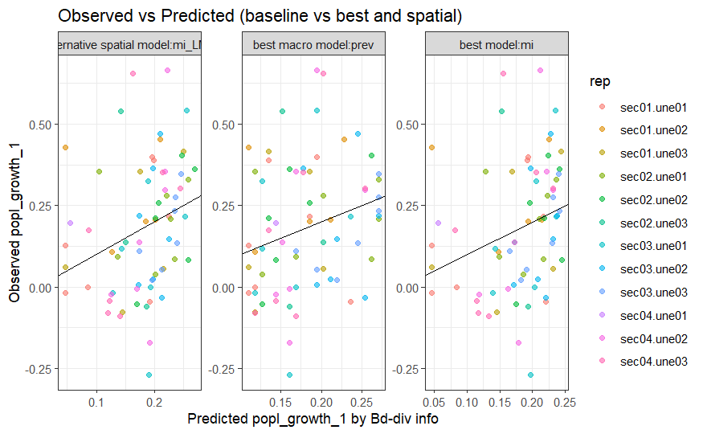

```r
ggplot(pred_long, aes(x = pred, y = obs)) +
  geom_point(alpha = 0.6, aes(color = rep)) +
  geom_abline(slope = 1, intercept = 0) +
  facet_wrap(~ model, scales = "free") +
  labs(y = "Observed popl_growth_1",
       x = "Predicted popl_growth_1 by Bd-div info",
       title = "Observed vs Predicted (baseline vs best and spatial)") +
  theme_bw()
```

##### Visualization 02

```r
b <- results_LORO$popl_growth_1_Bd$m_prev[, c("rep","n_test","RMSE")]
best <- results_LORO$popl_growth_1_Bd$m_mi[, c("rep","n_test","RMSE")]
alt  <- results_LORO$popl_growth_1_Bd$m_mi_LMX[, c("rep","n_test","RMSE")]

names(b)[names(b)=="RMSE"] <- "RMSE_macro_only"
names(best)[names(best)=="RMSE"] <- "RMSE_best"
names(alt)[names(alt)=="RMSE"] <- "RMSE_spatial"

# merge the data
w <- merge(b, best[, c("rep","RMSE_best")], by = "rep", all = FALSE)
w <- merge(w, alt[,  c("rep","RMSE_spatial")],  by = "rep", all = FALSE)

w$delta_best <- w$RMSE_macro_only - w$RMSE_best
w$delta_spatial  <- w$RMSE_macro_only - w$RMSE_spatial

# converting long format
df_delta <- rbind(
  data.frame(rep = w$rep, n_test = w$n_test, delta_RMSE = w$delta_best, model = "Best"),
  data.frame(rep = w$rep, n_test = w$n_test, delta_RMSE = w$delta_spatial,  model = "Spatial")
)

# if ordering based on the improvement by the best model
#df_delta$rep <- factor(df_delta$rep, levels = w$rep[order(w$delta_best, decreasing = TRUE)])
```

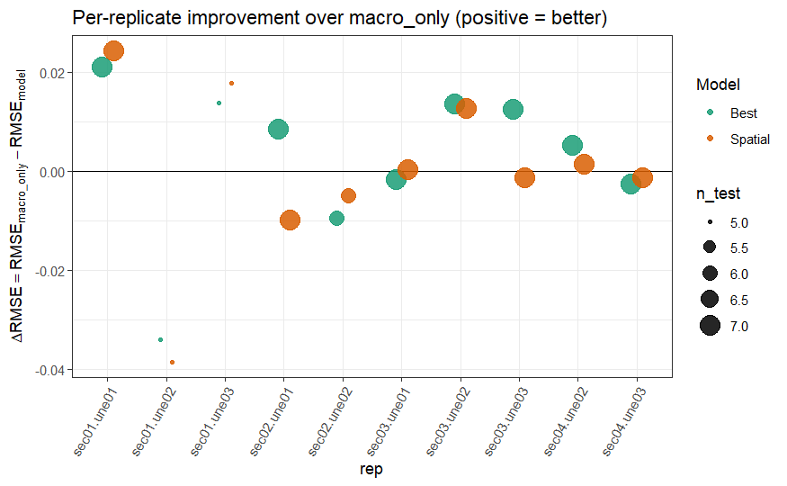

```r
ggplot(df_delta, aes(x = rep, y = delta_RMSE, group = model)) +
  geom_hline(yintercept = 0) +
  geom_point(aes(size = n_test, color = model), alpha = 0.85, position = position_dodge(width = 0.4)) +
  scale_color_manual(values = c("Best" = "#1b9e77",
                                "Spatial" = "#d95f02"),
                     name = "Model") +
  labs(x = "rep", y = expression(Delta*RMSE == RMSE[macro_only] - RMSE[model]),
       size = "n_test",
       title = "Per-replicate improvement over macro_only (positive = better)") +
  theme_bw() +
  theme(axis.text.x = element_text(angle = 60, hjust = 1))
```

#### [6.2.3] Prevalence growth rate 1

```r
## =========================================================
## 2) DEFINE CANDIDATE MODELS (all subsets)
## =========================================================
# Model list as formulas; includes intercept-only baseline
# Note that macro parameters are also used for Bd unit
candidate_formulas$prev_growth_1_Bd <- list(
  m0 = as.formula("prev_growth_une_1 ~ 1"),
  m_pop = as.formula("prev_growth_une_1 ~ popsize_Bd"),
  m_prev = as.formula("prev_growth_une_1 ~ prevalence_Bd"),
  m_mi = as.formula("prev_growth_une_1 ~ std_mi_Bd"),
  m_LMX = as.formula("prev_growth_une_1 ~ LMX_I_Bd"),
  m_moran = as.formula("prev_growth_une_1 ~ moran_Bd"),
  m_pop_prev = as.formula("prev_growth_une_1 ~ popsize_Bd + prevalence_Bd"),
  m_pop_mi = as.formula("prev_growth_une_1 ~ popsize_Bd + std_mi_Bd"),
  m_pop_LMX = as.formula("prev_growth_une_1 ~ popsize_Bd + LMX_I_Bd"),
  m_prev_mi = as.formula("prev_growth_une_1 ~ prevalence_Bd + std_mi_Bd"),
  m_prev_LMX = as.formula("prev_growth_une_1 ~ prevalence_Bd + LMX_I_Bd"),
  m_mi_LMX = as.formula("prev_growth_une_1 ~ std_mi_Bd + LMX_I_Bd"),
  m_pop_moran = as.formula("prev_growth_une_1 ~ popsize_Bd + moran_Bd"),
  m_prev_moran = as.formula("prev_growth_une_1 ~ prevalence_Bd + moran_Bd"),
  m_mi_moran = as.formula("prev_growth_une_1 ~ std_mi_Bd + moran_Bd"),
  m_LMX_moran = as.formula("prev_growth_une_1 ~ LMX_I_Bd + moran_Bd"),
  m_pop_prev_mi = as.formula("prev_growth_une_1 ~ popsize_Bd + prevalence_Bd + std_mi_Bd"),
  m_pop_prev_LMX = as.formula("prev_growth_une_1 ~ popsize_Bd + prevalence_Bd + LMX_I_Bd"),
  m_pop_prev_moran = as.formula("prev_growth_une_1 ~ popsize_Bd + prevalence_Bd + moran_Bd"),
  m_pop_mi_LMX = as.formula("prev_growth_une_1 ~ popsize_Bd + std_mi_Bd + LMX_I_Bd"),
  m_pop_mi_moran = as.formula("prev_growth_une_1 ~ popsize_Bd + std_mi_Bd + moran_Bd"),
  m_pop_LMX_moran = as.formula("prev_growth_une_1 ~ popsize_Bd + LMX_I_Bd + moran_Bd"),
  m_prev_mi_LMX = as.formula("prev_growth_une_1 ~ prevalence_Bd + std_mi_Bd + LMX_I_Bd"),
  m_prev_mi_moran = as.formula("prev_growth_une_1 ~ prevalence_Bd + std_mi_Bd + moran_Bd"),
  m_prev_LMX_moran = as.formula("prev_growth_une_1 ~ prevalence_Bd + LMX_I_Bd + moran_Bd"),
  m_mi_LMX_moran = as.formula("prev_growth_une_1 ~ std_mi_Bd + LMX_I_Bd + moran_Bd"),
  m_pop_prev_mi_LMX = as.formula("prev_growth_une_1 ~ popsize_Bd + prevalence_Bd + std_mi_Bd + LMX_I_Bd"),
  m_pop_prev_mi_moran = as.formula("prev_growth_une_1 ~ popsize_Bd + prevalence_Bd + std_mi_Bd + moran_Bd"),
  m_pop_prev_LMX_moran = as.formula("prev_growth_une_1 ~ popsize_Bd + prevalence_Bd + LMX_I_Bd + moran_Bd"),
  m_pop_mi_LMX_moran = as.formula("prev_growth_une_1 ~ popsize_Bd + std_mi_Bd + LMX_I_Bd + moran_Bd"),
  m_prev_mi_LMX_moran = as.formula("prev_growth_une_1 ~ prevalence_Bd + std_mi_Bd + LMX_I_Bd +  moran_Bd"),
  m_all = as.formula("prev_growth_une_1 ~ popsize_Bd + prevalence_Bd + std_mi_Bd + LMX_I_Bd + moran_Bd")
)
```

```r
## =========================================================
## 4) RUN LORO FOR ALL MODELS: 2 reps are excluded with min_test_n = 4
## =========================================================
results_LORO$prev_growth_1_Bd <- lapply(candidate_formulas$prev_growth_1_Bd, function(fm) {
  loro_eval_model(df           = Bddiv_une_summary_aphid_apr_1,
                  form         = fm,
                  time_col     = "dayN",
                  rep_col      = "une_section",
                  response_col = "prev_growth_une_1",
                  min_test_n   = 4)
})
```

```r
## =========================================================
## 5) AGGREGATE: macro (rep-average) + micro (all points)
## =========================================================
score_table$prev_growth_1_Bd <- make_score_table(results_LORO$prev_growth_1_Bd)


# Rank (choose criterion; micro_RMSE)
score_table$prev_growth_1_Bd <- score_table$prev_growth_1_Bd[order(score_table$prev_growth_1_Bd$micro_RMSE), ]
print(score_table$prev_growth_1_Bd)
```

|  | model | n_rep_used | macro_RMSE | micro_RMSE | macro_MAE | micro_MAE | macro_RMSE_sd |
| --- | --- | --- | --- | --- | --- | --- | --- |
| 3 | m_prev | 10 | 0.1352678 | 0.1456209 | 0.09440919 | 0.09384698 | 0.06292011 |
| 7 | m_pop_prev | 10 | 0.1357887 | 0.1458412 | 0.09606286 | 0.09561744 | 0.06221769 |
| 11 | m_prev_LMX | 10 | 0.1355674 | 0.1458983 | 0.09526363 | 0.09472747 | 0.06284417 |
| 14 | m_prev_moran | 10 | 0.1374208 | 0.1460899 | 0.09756705 | 0.09690328 | 0.05879436 |
| 19 | m_pop_prev_moran | 10 | 0.1382189 | 0.1464501 | 0.09886302 | 0.09826849 | 0.05768565 |
| 18 | m_pop_prev_LMX | 10 | 0.1366536 | 0.1466433 | 0.09693685 | 0.09654586 | 0.06193347 |
| 25 | m_prev_LMX_moran | 10 | 0.1379050 | 0.1467669 | 0.09783671 | 0.09720651 | 0.05911115 |
| 4 | m_mi | 10 | 0.1360007 | 0.1470836 | 0.09811069 | 0.09883016 | 0.06108141 |
| 8 | m_pop_mi | 10 | 0.1362237 | 0.1472977 | 0.09826356 | 0.09894845 | 0.06115736 |
| 12 | m_mi_LMX | 10 | 0.1363417 | 0.1473717 | 0.09846769 | 0.09928207 | 0.06094795 |

[output cut: 22 more lines]

```r
best_model_name$prev_growth_1_Bd <- score_table$prev_growth_1_Bd$model[which.min(score_table$prev_growth_1_Bd$micro_RMSE)]
best_formula$prev_growth_1_Bd <- candidate_formulas$prev_growth_1_Bd[[best_model_name$prev_growth_1_Bd]]
cat("\nBest by micro_RMSE:", best_model_name$prev_growth_1_Bd, "\n", deparse(best_formula$prev_growth_1_Bd), "\n")
```

```
Best by micro_RMSE: m_prev
 prev_growth_une_1 ~ prevalence_Bd
```

```r
## =========================================================
## 6) FINAL REFIT: refit the selected structure on ALL data by REML
##    and report coefficients + CI
## =========================================================
final_fit$prev_growth_1_Bd <- gls(best_formula$prev_growth_1_Bd,
                 data = Bddiv_une_summary_aphid_apr_1,
                 correlation = corCAR1(form = ~ dayN | une_section),
                 method = "REML",
                 na.action = na.omit)

cat("\nFinal model (REML) summary:\n")
```

```
Final model (REML) summary:
```

```r
print(summary(final_fit$prev_growth_1_Bd))
```

```
Generalized least squares fit by REML
  Model: best_formula$prev_growth_1_Bd
  Data: Bddiv_une_summary_aphid_apr_1
```

|  | AIC | BIC | logLik |
| --- | --- | --- | --- |
|  | -53.51279 | -44.69402 | 30.75639 |

```
Correlation Structure: Continuous AR(1)
 Formula: ~dayN | une_section
 Parameter estimate(s):
      Phi
0.3051534

Coefficients:
```

|  | Value | Std.Error | t-value | p-value |
| --- | --- | --- | --- | --- |
| (Intercept) | 0.1257991 | 0.03356660 | 3.747747 | 0.0004 |
| prevalence_Bd | -0.1264165 | 0.05952319 | -2.123820 | 0.0374 |

```
 Correlation:
              (Intr)
prevalence_Bd -0.847

Standardized residuals:
        Min          Q1         Med          Q3         Max
-3.14419351 -0.36316164  0.05685907  0.31380499  2.34324610

Residual standard error: 0.1462159
Degrees of freedom: 69 total; 67 residual
```

```r
cat("\nFixed effects (tTable):\n")
```

```
Fixed effects (tTable):
```

```r
print(summary(final_fit$prev_growth_1_Bd)$tTable)
```

```
                   Value  Std.Error   t-value      p-value
(Intercept)    0.1257991 0.03356660  3.747747 0.0003739398
prevalence_Bd -0.1264165 0.05952319 -2.123820 0.0373805579
```

```r
## (Optional) Save the per-rep LORO tables for the best model
best_loro_table$prev_growth_1_Bd <- results_LORO$prev_growth_1_Bd[[best_model_name$prev_growth_1_Bd]]
best_loro_table$prev_growth_1_Bd
```

| rep | n_test | RMSE | MAE | SSE | SAE |
| --- | --- | --- | --- | --- | --- |
| sec01.une01 | 7 | 0.23413794 | 0.17032015 | 0.38374403 | 1.1922411 |
| sec01.une02 | 5 | 0.14938019 | 0.08277930 | 0.11157221 | 0.4138965 |
| sec01.une03 | 5 | 0.22791006 | 0.15238116 | 0.25971498 | 0.7619058 |
| sec02.une01 | 7 | 0.04469739 | 0.03223175 | 0.01398500 | 0.2256223 |
| sec02.une02 | 6 | 0.05798205 | 0.03826880 | 0.02017151 | 0.2296128 |
| sec03.une01 | 7 | 0.11515960 | 0.07415257 | 0.09283214 | 0.5190680 |
| sec03.une02 | 7 | 0.11244360 | 0.08356534 | 0.08850494 | 0.5849574 |
| sec03.une03 | 7 | 0.10827722 | 0.07908737 | 0.08206769 | 0.5536116 |
| sec04.une02 | 7 | 0.13228487 | 0.10854921 | 0.12249501 | 0.7598445 |
| sec04.une03 | 7 | 0.17040529 | 0.12275622 | 0.20326575 | 0.8592935 |

– alternative model

```r
alternative_model <- gls(candidate_formulas$prev_growth_1_Bd$m_mi,
                         data = Bddiv_une_summary_aphid_apr_1,
                         correlation = corCAR1(form = ~ dayN | une_section),
                         method = "REML",
                         na.action = na.omit)

cat("\nFinal alternative model (REML) summary:\n")
```

```
Final alternative model (REML) summary:
```

```r
print(summary(alternative_model))
```

```
Generalized least squares fit by REML
  Model: candidate_formulas$prev_growth_1_Bd$m_mi
  Data: Bddiv_une_summary_aphid_apr_1
```

|  | AIC | BIC | logLik |
| --- | --- | --- | --- |
|  | -56.84407 | -48.0253 | 32.42203 |

```
Correlation Structure: Continuous AR(1)
 Formula: ~dayN | une_section
 Parameter estimate(s):
      Phi
0.3744201

Coefficients:
```

|  | Value | Std.Error | t-value | p-value |
| --- | --- | --- | --- | --- |
| (Intercept) | -0.1517889 | 0.08705013 | -1.743696 | 0.0858 |
| std_mi_Bd | 0.3278430 | 0.12903172 | 2.540794 | 0.0134 |

```
 Correlation:
          (Intr)
std_mi_Bd -0.979

Standardized residuals:
       Min         Q1        Med         Q3        Max
-3.4062399 -0.3089179  0.1314975  0.4692550  1.9810468

Residual standard error: 0.1443903
Degrees of freedom: 69 total; 67 residual
```

```r
cat("\nFixed effects (tTable):\n")
```

```
Fixed effects (tTable):
```

```r
print(summary(alternative_model$tTable))
```

```
Length  Class   Mode
     0   NULL   NULL
```

##### Visualization 01

```r
best_prev_Bd_model <- gls(candidate_formulas$prev_growth_1_Bd$m_prev,
                         data = Bddiv_une_summary_aphid_apr_1,
                         correlation = corCAR1(form = ~ dayN | une_section),
                         method = "REML",
                         na.action = na.omit)

macro_prev_Bd_model <- gls(candidate_formulas$prev_growth_1_Bd$m_mi,
                         data = Bddiv_une_summary_aphid_apr_1,
                         correlation = corCAR1(form = ~ dayN | une_section),
                         method = "REML",
                         na.action = na.omit)

pred_df <- data.frame(
  obs = Bddiv_une_summary_aphid_apr_1$popl_growth_une_1,
  pred_prev = predict(best_prev_Bd_model, newdata = Bddiv_une_summary_aphid_apr_1),
  pred_mi = predict(macro_popl_Bd_model, newdata = Bddiv_une_summary_aphid_apr_1)
)

pred_long <- rbind(
  data.frame(model = "best model:prev", pred = pred_df$pred_prev, obs = pred_df$obs, rep =  Bddiv_une_summary_aphid_apr_1$une_section),
  data.frame(model = "best spatial model:mi", pred = pred_df$pred_mi, obs = pred_df$obs, rep =  Bddiv_une_summary_aphid_apr_1$une_section)
)
```

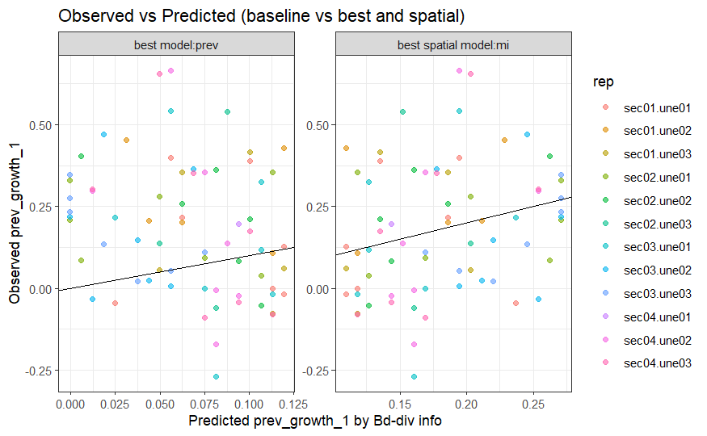

```r
ggplot(pred_long, aes(x = pred, y = obs)) +
  geom_point(alpha = 0.6, aes(color = rep)) +
  geom_abline(slope = 1, intercept = 0) +
  facet_wrap(~ model, scales = "free") +
  labs(y = "Observed prev_growth_1",
       x = "Predicted prev_growth_1 by Bd-div info",
       title = "Observed vs Predicted (baseline vs best and spatial)") +
  theme_bw()
```

##### Visualization 02

```r
b <- results_LORO$prev_growth_1_Bd$m_prev[, c("rep","n_test","RMSE")]
alt  <- results_LORO$prev_growth_1_Bd$m_mi[, c("rep","n_test","RMSE")]

names(b)[names(b)=="RMSE"] <- "RMSE_best:prev_Bd"
names(alt)[names(alt)=="RMSE"] <- "RMSE_spatial"

# merge the data
w <- merge(b, alt[, c("rep","RMSE_spatial")], by = "rep", all = FALSE)

w$delta_spatial  <- w$`RMSE_best:prev_Bd` - w$RMSE_spatial

# converting long format
df_delta <- rbind(
  data.frame(rep = w$rep, n_test = w$n_test, delta_RMSE = w$delta_spatial,  model = "Spatial")
)

# if ordering based on the improvement by the best model
#df_delta$rep <- factor(df_delta$rep, levels = w$rep[order(w$delta_best, decreasing = TRUE)])
```

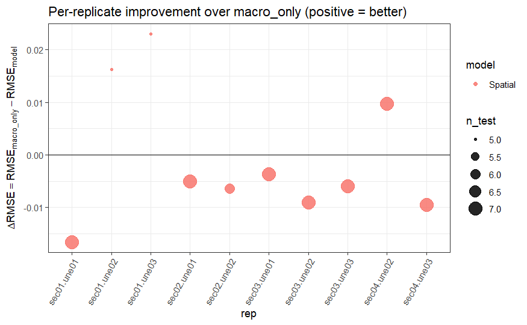

```r
ggplot(df_delta, aes(x = rep, y = delta_RMSE, group = model)) +
  geom_hline(yintercept = 0) +
  geom_point(aes(size = n_test, color = model), alpha = 0.85, position = position_dodge(width = 0.4)) +

  labs(x = "rep", y = expression(Delta*RMSE == RMSE[macro_only] - RMSE[model]),
       size = "n_test",
       title = "Per-replicate improvement over macro_only (positive = better)") +
  theme_bw() +
  theme(axis.text.x = element_text(angle = 60, hjust = 1))
```

– Save some objects for the manuscript

```r
aphid_popl_growth_model <- best_formula$popl_growth_1
aphid_prev_growth_model <- best_formula$prev_growth_1
aphid_popl_growth_fitted <- final_fit$popl_growth_1
aphid_prev_growth_fitted <- final_fit$prev_growth_1

Bd_aphid_popl_growth_model <- best_formula$popl_growth_1_Bd
Bd_aphid_prev_growth_model <- best_formula$prev_growth_1_Bd
Bd_aphid_popl_growth_fitted <- final_fit$popl_growth_1_Bd
Bd_aphid_prev_growth_fitted <- final_fit$prev_growth_1_Bd

save(
  aphid_popl_growth_model,
  aphid_prev_growth_model,
  aphid_popl_growth_fitted,
  aphid_prev_growth_fitted,
  Bd_aphid_popl_growth_model,
  Bd_aphid_prev_growth_model,
  Bd_aphid_popl_growth_fitted,
  Bd_aphid_prev_growth_fitted,
  file = "aphid_bestfit.RData")
```